# Analysis of pooled growth of large CbbM library

Ute Hoffmann

DATE: 2026-03-18 15:51:18.595762

# 1 Brief description of data set

A library of Rubisco variants based on a mutant variant of *Gallionella* sp. CbbM was designed. The CbbM variant is two amino acid exchanges away from the wild-type sequence and was identified as part of a small library which was used to establish the screening system. For reasons of simplicity, in the following, “WT” will refer to this variant, which is the “base” of the whole library. The large library consists of 67 positions, which were separately exchanged by any other possible amino acid and a combinatorial part, which is based on seven amino acid positions, which were exchanged, in a combinatorial fashion, by a few specific possible residues per position.

Both parts of the library were designed with the help of EVmutation and DeepSequence, which use phylogenetic information to predict beneficial amino acid exchanges. The exact manner how predictions were performed is described along with the small library the “base” mutant variant is derived from.

The complete library was transformed into a *Synechocystis* host strain, in which transcription of the endogenous Rubisco transcript can be inhibited by the induction of a CRISPR inhibition system. Each variant is represented by one or several clones, which can be distinguished on base of their N20 barcodes. The pooled library of these strains was grown in 8 replicates at different gas feed and light conditions in turbidostat mode for approximately 10 generations (CL_N2: constant light 300 µE, 5% CO2, 95% N2, 0% O2, CL_O2: constant light 300 µE, 5% CO2, 75% N2, 20% O2, LD: light-dark cycles, 5% CO2, 75% N2, 20% O2). By taking samples for Illumina sequencing regularly, we were able to track almost all variants present and assign fitness values.

Note that amino acid numbering in the following are based on the sequence including the N-Strep tag.

Fitness values are given as normalized values, i.e. a value of 1.0 equals the fitness of the base variant (actually the underlying CbbM variant which is two amino acid exchanges away from wild-type CbbM) and 0.0 equals the median value of K214 variants present in the data set. K214 is the carbamylated lysine which is essential for catalysis. Exchanges of this lysine residue should result in catalytically inactive enzyme. Mutant variants with worse fitness values than K214 substitutions can be considered catalytically inactive.

In a first step, all data of relevance will be loaded.

# 2 Plot to check how lfcSE and baseMean relate to each other

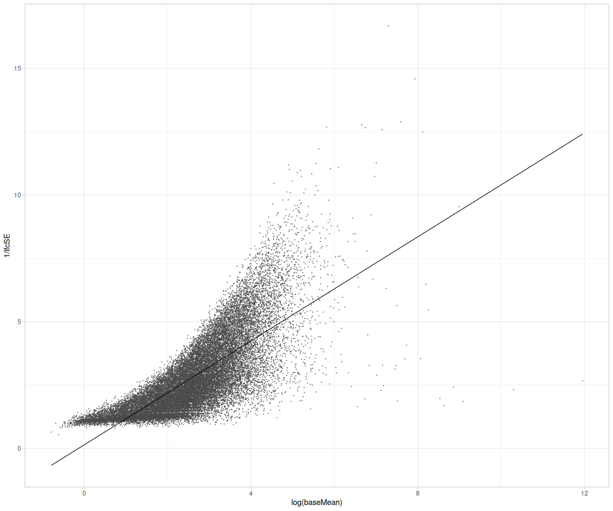

```r
fitness_lfcSE <- unique(fitness_data[,c("lfcSE", "baseMean", "condition", "sgRNA")])
fitness_lfcSE <- dplyr::left_join(
  fitness_lfcSE,
  fitness_lfcSE %>%
    dplyr::group_by(sgRNA, condition) %>%
    dplyr::summarize(
      .groups = "keep",
      # get max lfcSE
      weight_lfcSE = max(lfcSE)
    )
)
fitness_lfcSE <- unique(subset(fitness_lfcSE, !is.na(fitness_lfcSE$baseMean))[,c("condition", "sgRNA", "baseMean","weight_lfcSE")])
fitness_lfcSE$log_baseMean <- log(fitness_lfcSE$baseMean)
fitness_lfcSE$inverse_lfcSE <- 1/fitness_lfcSE$weight_lfcSE
fitness_lfcSE <- subset(fitness_lfcSE, fitness_lfcSE$condition == "CL_N2")
p <- ggplot(fitness_lfcSE, aes(x=log_baseMean, y=inverse_lfcSE)) + geom_point(size=0.001, color="#4a4a4aff") + theme_light() + ylab("1/lfcSE") + xlab("log(baseMean)") + geom_smooth(method = "lm", se=FALSE, color="black", formula = y ~ x, linewidth=0.4) #+ facet_wrap(~condition)+ theme(panel.grid.minor =element_blank(), legend.position = "none", strip.background=element_rect(fill = NA, color = "white"), strip.text.x = element_text(size = 8, colour = "black", hjust = 0), axis.text=element_text(size=8), axis.title=element_text(size=8), legend.text=element_text(size=8))
p
```

```r
ggsave("../EDA_output/pdf/scatter_lfcSE_baseMean.pdf", plot=p, width=4, height=4, units="cm")
ggsave("../EDA_output/png/scatter_lfcSE_baseMean.png", plot=p, width=4, height=4, units="cm")
correlation <- cor.test(fitness_lfcSE$log_baseMean, fitness_lfcSE$inverse_lfcSE, method = 'pearson')
print(correlation)
```

```
    Pearson's product-moment correlation

data:  fitness_lfcSE$log_baseMean and fitness_lfcSE$inverse_lfcSE
t = 214.9, df = 30456, p-value < 2.2e-16
alternative hypothesis: true correlation is not equal to 0
95 percent confidence interval:
 0.7717682 0.7806950
sample estimates:
      cor
0.7762705
```

```r
mean(fitness_lfcSE$baseMean)
```

```
[1] 31.715
```

```r
rm(fitness_lfcSE)
```

# 3 Diagnostic plots for cultivation

## 3.1 Sample-sample correlation

When clustering according to similarity, replicates from the same gas conditions have a tendency to cluster together, irrespective of their light condition (constant light or light-dark). This is also the case at generation 0 - even at generation 0, samples are more similar to other samples from the same gas feed than to generation 0 samples of the other round of cultivation (first round of cultivation was CL_N2; CL_O2 and LD were run in a second round of cultivations).

There is some clear separation between samples from earlier time points and samples from later time points.

```r
df_counts <- tidyr::pivot_longer(count_matrix,
    cols = 2:ncol(count_matrix),
    names_to = "sample", values_to = "n_reads"
)

# sort
df_counts <- arrange(df_counts, sample)
df_counts <- left_join(df_samplesheet, df_counts)

df_correlation <- df_counts[,c("name", "sgRNA", "n_reads")] %>%
    tidyr::pivot_wider(names_from = "name", values_from = "n_reads") %>%
    dplyr::select(-c(1)) %>%
    cor()
```

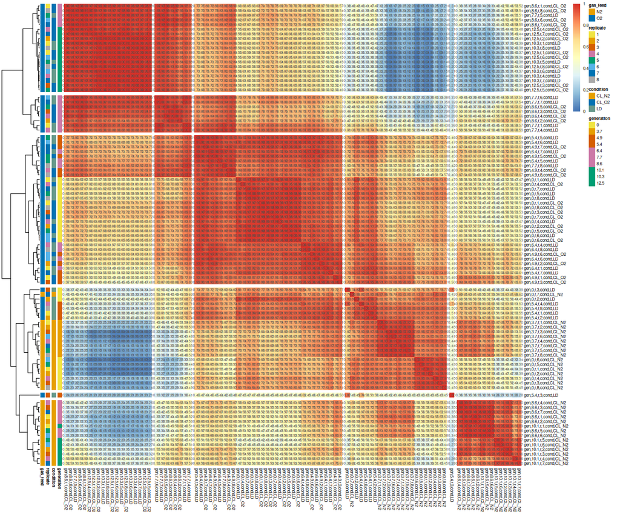

```r
annotation_days = data.frame(row.names=unique(row.names(df_correlation)), generation=as.character(c(rep(c("0", "3.7", "8.6", "10.1"), 2), rep(c("10.1", "8.6", "3.7", "0"), 2), rep(c("3.7", "10.1", "0", "8.6"), 2), "8.6", "0", "10.1", "3.7", "3.7", "0", "0", "5.4", "6.4", "7.7", "10.3", "0", "5.4", "0", "5.4", rep(c("0", "5.4", "6.4", "7.7", "10.3"), 5), rep(c("0", "4.9", "8.6", "12.5"),8))), condition=c(rep("CL_N2", 30), rep("LD", 34), rep("CL_O2", 32)), replicate=as.character(c(rep("1", 4), rep("2", 4), rep("3", 4), rep("4", 4), rep("5", 4), rep("6", 4), rep("7", 4), rep("8", 2), rep("1", 5), rep("2", 2), rep("3", 2), rep("4", 5), rep("5", 5), rep("6", 5), rep("7", 5), rep("8", 5), rep("1", 4), rep("2", 4), rep("3", 4), rep("4", 4), rep("5", 4), rep("6", 4), rep("7", 4), rep("8", 4))), gas_feed=c(rep("N2", 30), rep("O2", 66)))

# https://stackoverflow.com/questions/41628450/r-pheatmap-change-annotation-colors-and-prevent-graphics-window-from-popping-up
# choose gradient of colors for generations
# e.g. Tol from https://davidmathlogic.com/colorblind/#%23D81B60-%231E88E5-%23FFC107-%23004D40
okabe <- c("#f0e442ff", "#e69f00ff", "#d55e00ff", "#cc79a7ff", "#009e73ff", "#56b4e9ff", "#0072b2ff", "#aaaaaaff")
generations <- okabe[c(1, 2, 3, 3, 4, 4, 4, 5, 5, 5)]
# generations "0"    "3.7"  "8.6"  "10.1" "5.4"  "6.4"  "7.7"  "10.3" "4.9"  "12.5"
names(generations) <- c("0", "3.7", "4.9","5.4", "6.4", "7.7", "8.6", "10.1", "10.3", "12.5")
# replicates 1 to 8
rep <- okabe[1:8]
names(rep) <- as.character(1:8)
feed <- okabe[c(2, 7)]
names(feed) <- c("N2", "O2")
annotation_color_list <- list(condition=col_conditions, replicate=rep, generation=generations, gas_feed=feed)

# https://bioinformatics.stackexchange.com/questions/22502/manually-set-range-of-colour-scale-in-pheatmap-in-r
color.divisions <- 100

p <- pheatmap(df_correlation, display_numbers=TRUE, treeheight_col=0, cutree_rows = 6, cutree_cols = 6, annotation_row = annotation_days, annotation_colors = annotation_color_list, breaks = seq(0,1, length.out=(color.divisions + 1)), fontsize=6)
```

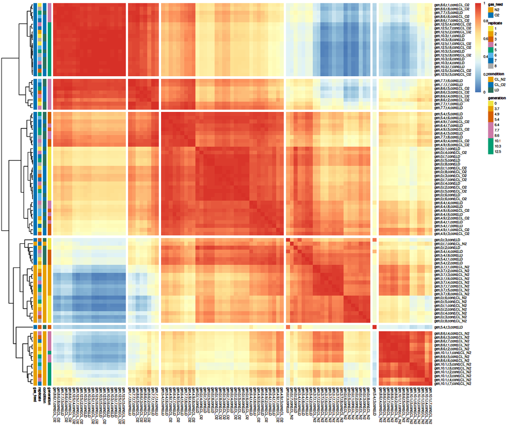

```r
ggsave("../EDA_output/pdf/correlation_samples_clustering_numbers.pdf", plot=p, width=20, height=20)

p <- pheatmap(df_correlation, display_numbers=FALSE, treeheight_col=0, cutree_rows = 6, cutree_cols = 6, annotation_row = annotation_days, annotation_colors = annotation_color_list, breaks = seq(0,1, length.out=(color.divisions + 1)), fontsize=6)
p
```

```r
ggsave("../EDA_output/png/correlation_samples_clustering.png", plot=p, width=11.5, height=10)
ggsave("../EDA_output/pdf/correlation_samples_clustering.pdf", plot=p, width=11.5, height=10)
```

## 3.2 Check equal distribution in time 0 samples

For checking the distribution at time point 0, two t = 0 replicates from each condition were used.

```r
count_matrix_time0 <- as.data.frame(data.frame(sgRNA=count_matrix$sgRNA, LD_1=count_matrix$LD1A1, LD_2=count_matrix$LD1A6, O2_1=count_matrix$O22A1, O2_2=count_matrix$O22A5, N2_1=count_matrix$highN4A1, N2_2=count_matrix$highN4A5))

row.names(count_matrix_time0) <- count_matrix_time0$sgRNA
count_matrix_time0$sgRNA <- NULL

design_matrix <- data.frame(group=rep("t0", 6))
row.names(design_matrix) = names(count_matrix_time0)
```

DESeq2 is used to normalize among the replicates.

```r
ddstime0 <- DESeqDataSetFromMatrix(
  countData = count_matrix_time0,
  colData = design_matrix,
  design = ~ 1)
ddstime0 <- estimateSizeFactors(ddstime0)
counts_norm_ddstime0 <- as.data.frame(counts(ddstime0, normalized=TRUE))
rm(ddstime0,count_matrix,count_matrix_time0)
```

When log10-transforming the x-scale of the mean of counts in the different samples, the distribution looks as if mean values were almost normally distributed. This is, if I am not mistaken, relatively typical for count data. (Count data does usually follow a Poisson distribution, which looks more “normal” when being log-transformed)

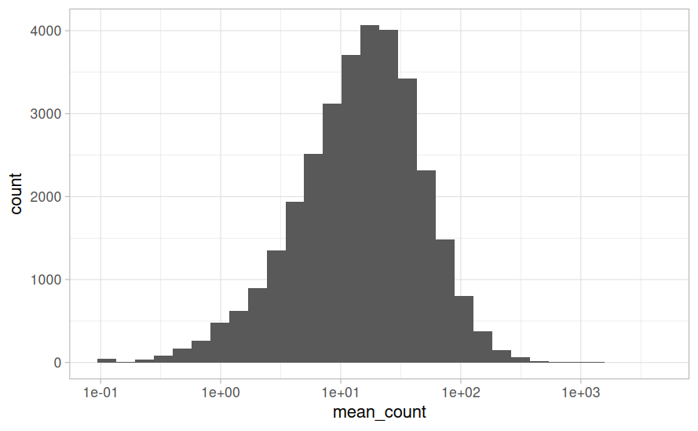

```r
df_plot <- data.frame(mut=row.names(counts_norm_ddstime0), mean_count=apply(counts_norm_ddstime0, 1, mean))
p <- ggplot(df_plot, aes(x=mean_count)) + geom_histogram() + theme_light() + scale_x_log10()
p
```

The plot below shows mean and stdev of the count of 100 randomly picked barcodes present in the samples at time point 0 and confirms the histogram from above. There are outliers with many counts or almost no counts and a huge bulk of barcodes with a similar count. According to the histogram above, this bulk is approx. at a mean count of 10.

```r
df_plot <- counts_norm_ddstime0[round(runif(n=100, min=1, max=nrow(counts_norm_ddstime0))),]
df_plot <- data.frame(mut=row.names(df_plot), mean_count=apply(df_plot, 1, mean), stdev=apply(df_plot,1,sd))
p <- ggplot(df_plot) + geom_bar(aes(x=reorder(mut, mean_count), y=mean_count), stat="identity") + geom_errorbar(aes(x=mut, ymin=mean_count-stdev, ymax=mean_count+stdev), width=0.4) + theme_light() + xlab("100 randomly picked barcodes") + ylab("Mean of normalized read counts") + labs(title="Randomly picked barcodes and their average abundance") + theme(axis.text.x=element_blank())
p
ggsave("../EDA_output/pdf/time0_distribution.pdf", plot=p)
```

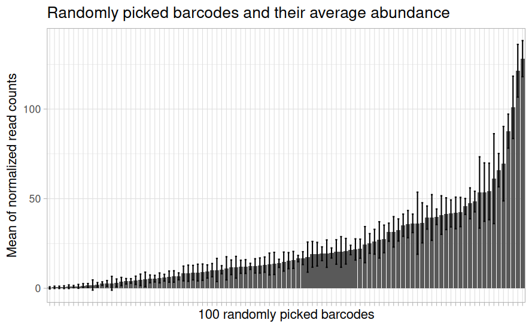

```r
ggsave("../EDA_output/png/time0_distribution.png", plot=p)
```

Calculate the Gini index of a few of the samples, a value of 0 reflects complete equality, a value of 1 maximal inequality. Gini indices for all samples are also calculated as part of the whole nf-crispriscreen pipeline. With values of approx. 0.55 to 0.6, barcodes at time point 0 are not completely inequally distributed, but also far from perfect equality.

```r
Gini(counts_norm_ddstime0$LD_1, unbiased=FALSE)
```

```
[1] 0.5701114
```

```r
Gini(counts_norm_ddstime0$LD_2, unbiased=FALSE)
```

```
[1] 0.5651001
```

```r
Gini(counts_norm_ddstime0$O2_1, unbiased=FALSE)
```

```
[1] 0.5664372
```

```r
Gini(counts_norm_ddstime0$O2_2, unbiased=FALSE)
```

```
[1] 0.588848
```

```r
Gini(counts_norm_ddstime0$N2_1, unbiased=FALSE)
```

```
[1] 0.5679795
```

```r
Gini(counts_norm_ddstime0$N2_2, unbiased=FALSE)
```

```
[1] 0.5704703
```

```r
Gini(df_plot$mean_count, unbiased=FALSE)
```

```
[1] 0.5137304
```

## 3.3 Volcano plots for different conditions, scatter plots number barcodes to adjusted p values, histogram of p values

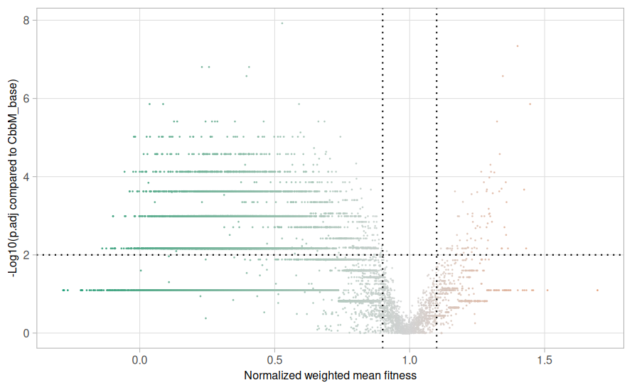

```r
volcano_width = 2
volcano_height =2
# CL_N2
subset_volcano <- unique(subset(fitness_data, fitness_data$condition=="CL_N2")[,c("sgRNA_target","p_fit_adj_WT","norm","num_barcodes")])
names(subset_volcano) <- c("gene_names_ordered_locus","adj.pvalue","log2FC","num_barcodes")
p <- volcanoPlot_ggplot(subset_volcano, text=FALSE, colours=c("#199e77ff", "#da5f02ff", "#d3d3d3b2"), foldchange=0.1)
ggsave("../EDA_output/diagnostic_plots/Volcano_CLN2_cutoff.pdf", plot=p, width=volcano_width, height=volcano_height)
p <- volcanoPlot_gradient_ggplot(subset_volcano, text=FALSE, colours=c("#199e77ff", "#da5f02ff", "#d3d3d3b2"), foldchange=0.1)
p
ggsave("../EDA_output/diagnostic_plots/Volcano_gradient_CLN2_cutoff.pdf", plot=p, width=volcano_width, height=volcano_height)
```

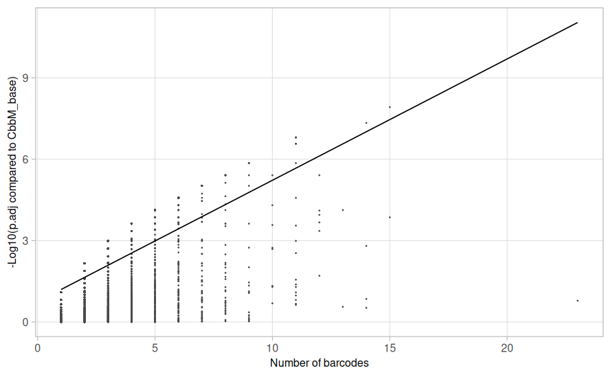

```r
subset_volcano <- unique(subset(subset_volcano, !subset_volcano$gene_names_ordered_locus=="WT"))
p <- ggplot(subset_volcano, aes(x=num_barcodes, y=-log10(adj.pvalue))) + geom_point(size=0.001, color="#4a4a4aff") + theme_light() + ylab("-Log10(p.adj compared to CbbM_base)") + xlab("Number of barcodes") + geom_smooth(method = "lm", se=FALSE, color="black", formula = y ~ x, linewidth=0.4) + theme(panel.grid.minor =element_blank(), legend.position = "none", strip.background=element_rect(fill = NA, color = "white"), strip.text.x = element_text(size = 8, colour = "black", hjust = 0), axis.text=element_text(size=8), axis.title=element_text(size=8), legend.text=element_text(size=8))
p
ggsave("../EDA_output/diagnostic_plots/CLN2_scatter_numBarcodes_padj.pdf", plot=p, width=volcano_width, height=volcano_height)
```

```r
correlation <- cor.test(subset_volcano$num_barcodes, -log10(subset_volcano$adj.pvalue), method = 'pearson')
print(correlation)
```

```
    Pearson's product-moment correlation

data:  subset_volcano$num_barcodes and -log10(subset_volcano$adj.pvalue)
t = 86.261, df = 13963, p-value < 2.2e-16
alternative hypothesis: true correlation is not equal to 0
95 percent confidence interval:
 0.5786870 0.6003287
sample estimates:
      cor
0.5896137
```

```r
p <- ggplot(subset_volcano, aes(x=adj.pvalue)) + geom_histogram(bins=50) + theme_light() + ylab("Frequency") + xlab("Adjusted p value") + theme(panel.grid.minor =element_blank(), legend.position = "none", strip.background=element_rect(fill = NA, color = "white"), strip.text.x = element_text(size = 8, colour = "black", hjust = 0), axis.text=element_text(size=8), axis.title=element_text(size=8), legend.text=element_text(size=8))
p
ggsave("../EDA_output/diagnostic_plots/CLN2_pValue_plot.pdf", plot=p, width=volcano_width, height=volcano_height)
```

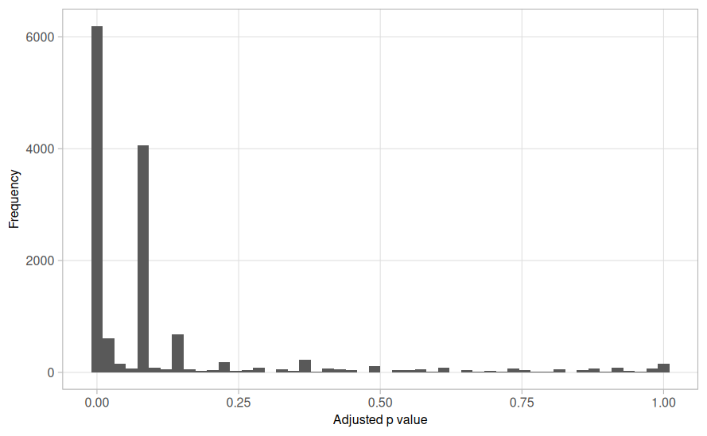

```r
# CL_O2
subset_volcano <- unique(subset(fitness_data, fitness_data$condition=="CL_O2")[,c("sgRNA_target","p_fit_adj_WT","norm","num_barcodes")])
names(subset_volcano) <- c("gene_names_ordered_locus","adj.pvalue","log2FC","num_barcodes")
p <- volcanoPlot_ggplot(subset_volcano, text=FALSE, colours=c("#199e77ff", "#da5f02ff", "#d3d3d3b2"), foldchange=0.1)
ggsave("../EDA_output/diagnostic_plots/Volcano_CLO2_cutoff.pdf", plot=p, width=volcano_width, height=volcano_height)
```

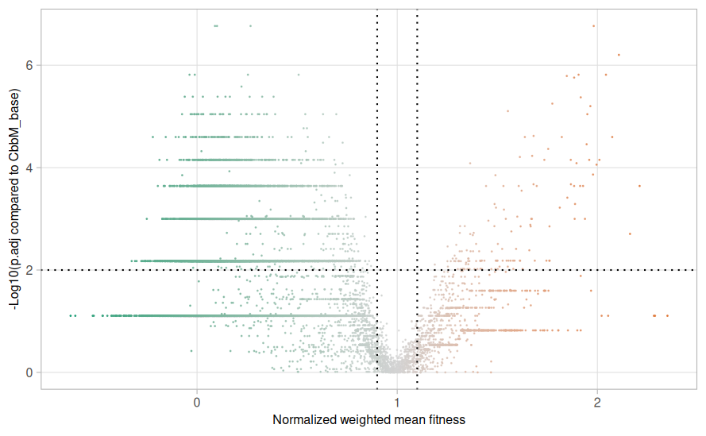

```r
p <- volcanoPlot_gradient_ggplot(subset_volcano, text=FALSE, colours=c("#199e77ff", "#da5f02ff", "#d3d3d3b2"), foldchange=0.1)
p
ggsave("../EDA_output/diagnostic_plots/Volcano_gradient_CLO2_cutoff.pdf", plot=p, width=volcano_width, height=volcano_height)
```

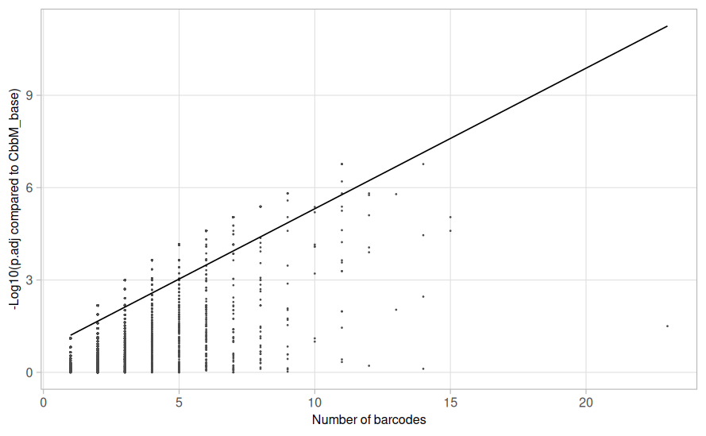

```r
subset_volcano <- subset(subset_volcano, !subset_volcano$gene_names_ordered_locus=="WT")
p <- ggplot(subset_volcano, aes(x=num_barcodes, y=-log10(adj.pvalue))) + geom_point(size=0.001, color="#4a4a4aff") + theme_light() + ylab("-Log10(p.adj compared to CbbM_base)") + xlab("Number of barcodes") + geom_smooth(method = "lm", se=FALSE, color="black", formula = y ~ x, linewidth=0.4) + theme(panel.grid.minor =element_blank(), legend.position = "none", strip.background=element_rect(fill = NA, color = "white"), strip.text.x = element_text(size = 8, colour = "black", hjust = 0), axis.text=element_text(size=8), axis.title=element_text(size=8), legend.text=element_text(size=8)) #+ xlim(c(0,25))
p
ggsave("../EDA_output/diagnostic_plots/CL_O2_scatter_numBarcodes_padj.pdf", plot=p, width=volcano_width, height=volcano_height)
```

```r
correlation <- cor.test(subset_volcano$num_barcodes, -log10(subset_volcano$adj.pvalue), method = 'pearson')
print(correlation)
```

```
    Pearson's product-moment correlation

data:  subset_volcano$num_barcodes and -log10(subset_volcano$adj.pvalue)
t = 89.016, df = 13963, p-value < 2.2e-16
alternative hypothesis: true correlation is not equal to 0
95 percent confidence interval:
 0.5910093 0.6121735
sample estimates:
     cor
0.601697
```

```r
p <- ggplot(subset_volcano, aes(x=adj.pvalue)) + geom_histogram(bins=50) + theme_light() + ylab("Frequency") + xlab("Adjusted p value") + theme(panel.grid.minor =element_blank(), legend.position = "none", strip.background=element_rect(fill = NA, color = "white"), strip.text.x = element_text(size = 8, colour = "black", hjust = 0), axis.text=element_text(size=8), axis.title=element_text(size=8), legend.text=element_text(size=8))
p
ggsave("../EDA_output/diagnostic_plots/CLO2_pValue_plot.pdf", plot=p, width=volcano_width, height=volcano_height)
```

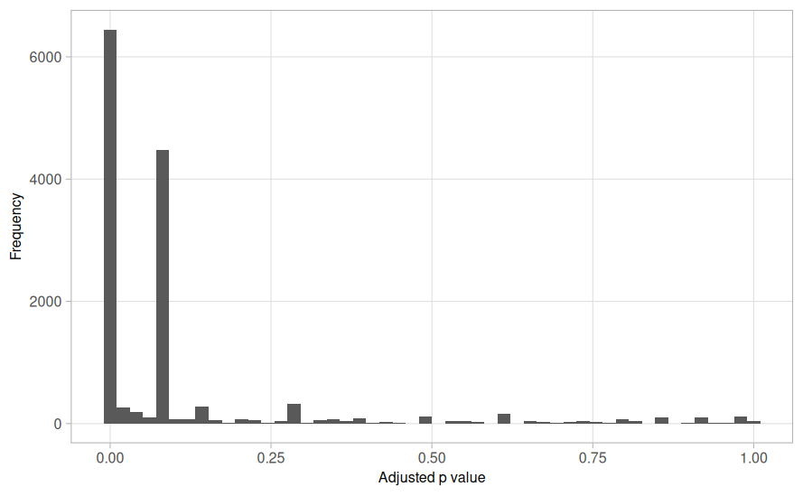

```r
# LD
subset_volcano <- unique(subset(fitness_data, fitness_data$condition=="LD")[,c("sgRNA_target","p_fit_adj_WT","norm","num_barcodes")])
names(subset_volcano) <- c("gene_names_ordered_locus","adj.pvalue","log2FC","num_barcodes")
p <- volcanoPlot_ggplot(subset_volcano, text=FALSE, colours=c("#199e77ff", "#da5f02ff", "#d3d3d3b2"), foldchange=0.1)
ggsave("../EDA_output/diagnostic_plots/Volcano_LD_cutoff.pdf", plot=p, width=volcano_width, height=volcano_height)
```

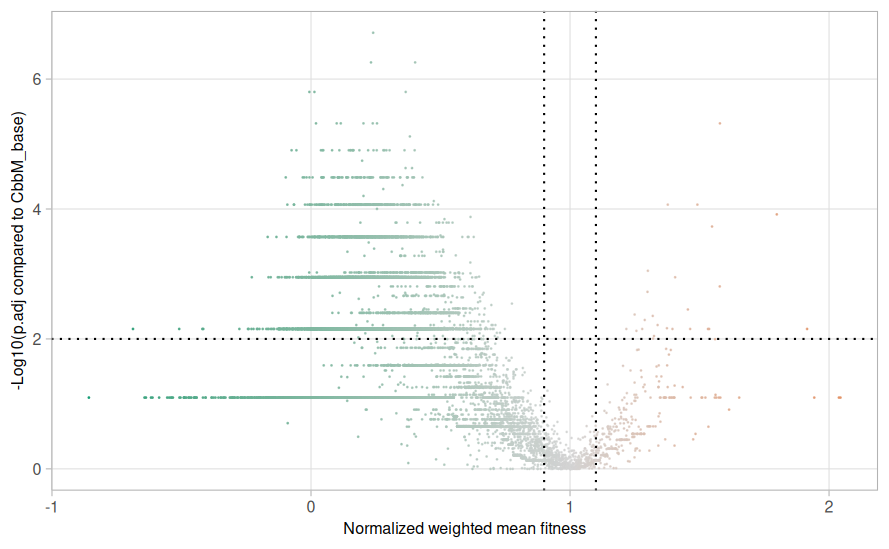

```r
p <- volcanoPlot_gradient_ggplot(subset_volcano, text=FALSE, colours=c("#199e77ff", "#da5f02ff", "#d3d3d3b2"), foldchange=0.1)
p
ggsave("../EDA_output/diagnostic_plots/Volcano_gradient_LD_cutoff.pdf", width=volcano_width, height=volcano_height)
```

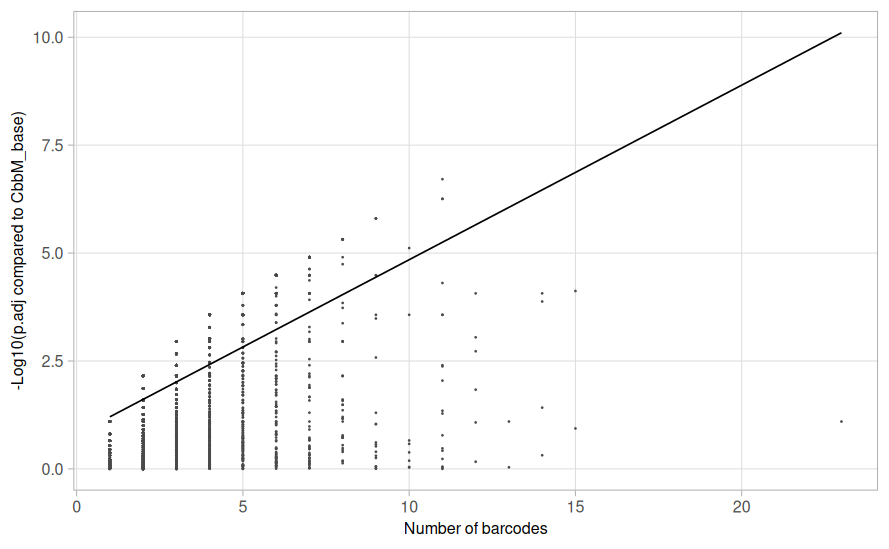

```r
subset_volcano <- subset(subset_volcano, !subset_volcano$gene_names_ordered_locus=="WT")
p <- ggplot(subset_volcano, aes(x=num_barcodes, y=-log10(adj.pvalue))) + geom_point(size=0.001, color="#4a4a4aff") + theme_light() + ylab("-Log10(p.adj compared to CbbM_base)") + xlab("Number of barcodes") + geom_smooth(method = "lm", se=FALSE, color="black", formula = y ~ x, linewidth=0.4) + theme(panel.grid.minor =element_blank(), legend.position = "none", strip.background=element_rect(fill = NA, color = "white"), strip.text.x = element_text(size = 8, colour = "black", hjust = 0), axis.text=element_text(size=8), axis.title=element_text(size=8), legend.text=element_text(size=8)) #+ xlim(c(0,25))
p
ggsave("../EDA_output/diagnostic_plots/LD_scatter_numBarcodes_padj.pdf", plot=p, width=volcano_width, height=volcano_height)
```

```r
correlation <- cor.test(subset_volcano$num_barcodes, -log10(subset_volcano$adj.pvalue), method = 'pearson')
print(correlation)
```

```
    Pearson's product-moment correlation

data:  subset_volcano$num_barcodes and -log10(subset_volcano$adj.pvalue)
t = 80.333, df = 13963, p-value < 2.2e-16
alternative hypothesis: true correlation is not equal to 0
95 percent confidence interval:
 0.5507665 0.5734549
sample estimates:
      cor
0.5622165
```

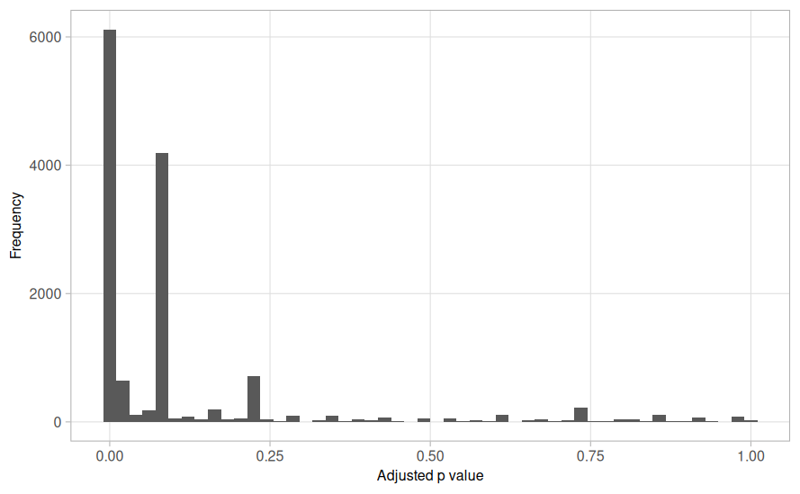

```r
p <- ggplot(subset_volcano, aes(x=adj.pvalue)) + geom_histogram(bins=50) + theme_light() + ylab("Frequency") + xlab("Adjusted p value") + theme(panel.grid.minor =element_blank(), legend.position = "none", strip.background=element_rect(fill = NA, color = "white"), strip.text.x = element_text(size = 8, colour = "black", hjust = 0), axis.text=element_text(size=8), axis.title=element_text(size=8), legend.text=element_text(size=8))
p
ggsave("../EDA_output/diagnostic_plots/LD_pValue_plot.pdf", plot=p, width=volcano_width, height=volcano_height)
```

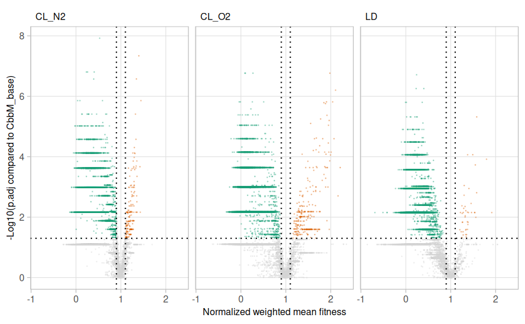

## 3.4 Scatter plots number barcodes to adjusted p values, histogram of p values

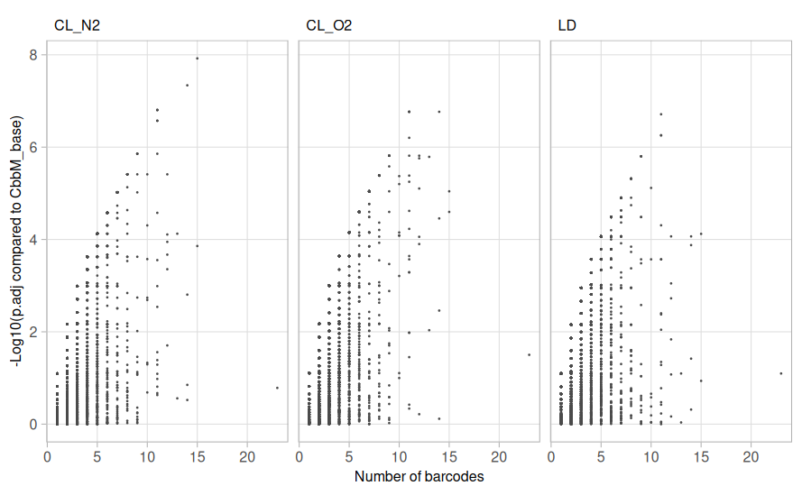

```r
fitness_subset <- unique(fitness_data[,c("condition","sgRNA_target","p_fit_adj_WT","norm","num_barcodes")])
names(fitness_subset) <- c("condition","gene_names_ordered_locus","adj.pvalue","log2FC","num_barcodes")
subset_volcano <- subset(fitness_subset, !fitness_subset$gene_names_ordered_locus=="WT")
p <- ggplot(subset_volcano, aes(x=num_barcodes, y=-log10(adj.pvalue))) + geom_point(size=0.001, color="#4a4a4aff") + theme_light() + ylab("-Log10(p.adj compared to CbbM_base)") + xlab("Number of barcodes") + facet_wrap(~condition) + theme(panel.grid.minor =element_blank(), legend.position = "none", strip.background=element_rect(fill = NA, color = "white"), strip.text.x = element_text(size = 8, colour = "black", hjust = 0), axis.text=element_text(size=8), axis.title=element_text(size=8), legend.text=element_text(size=8)) # + geom_smooth(method = "lm", se=FALSE, color="black", formula = y ~ x, linewidth=0.4)
p
ggsave("../EDA_output/diagnostic_plots/scatter_numBarcodes_padj.pdf", plot=p, width=6.8, height=2, units="in")
```

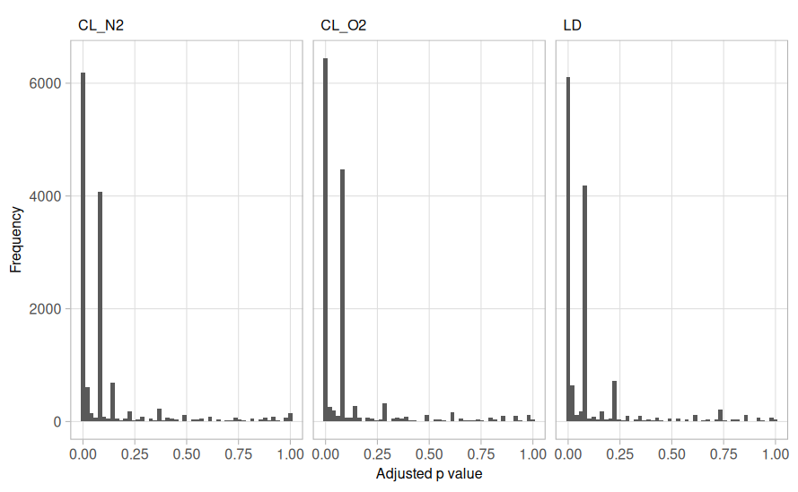

```r
rm(fitness_subset)

p <- ggplot(subset_volcano, aes(x=adj.pvalue)) + geom_histogram(bins=50) + theme_light() + ylab("Frequency") + xlab("Adjusted p value") + facet_wrap(~condition) + theme(panel.grid.minor =element_blank(), legend.position = "none", strip.background=element_rect(fill = NA, color = "white"), strip.text.x = element_text(size = 8, colour = "black", hjust = 0), axis.text=element_text(size=8), axis.title=element_text(size=8), legend.text=element_text(size=8))
p
ggsave("../EDA_output/diagnostic_plots/pValue_plot.pdf", plot=p, width=6.8, height=2, units="in")
```

```r
rm(subset_volcano)
```

## 3.5 Create table with stdev, variance and plot histogram thereof

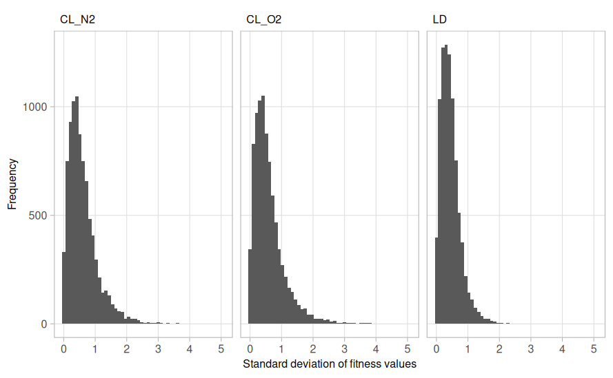

```r
fitness_stdev <- unique(fitness_data[,c("sgRNA", "sgRNA_target", "fitness", "condition","norm","num_barcodes")])
fitness_stdev <- dplyr::left_join(
  fitness_stdev,
  fitness_stdev %>%
    dplyr::group_by(sgRNA_target, condition) %>%
    dplyr::summarize(
      .groups = "keep",
      # get max lfcSE
      sd_fitness = sd(fitness)
    )
)
fitness_stdev$sgRNA <- NULL
fitness_stdev$fitness <- NULL
fitness_stdev <- unique(fitness_stdev)
p <- ggplot(fitness_stdev, aes(x=sd_fitness)) + geom_histogram(bins=50) + theme_light() + ylab("Frequency") + xlab("Standard deviation of fitness values") + facet_wrap(~condition)+ theme(panel.grid.minor =element_blank(), legend.position = "none", strip.background=element_rect(fill = NA, color = "white"), strip.text.x = element_text(size = 8, colour = "black", hjust = 0), axis.text=element_text(size=8), axis.title=element_text(size=8), legend.text=element_text(size=8))
p
ggsave("../EDA_output/diagnostic_plots/histogram_stdev.pdf", plot=p, width=6.8, height=2, units="in")
```

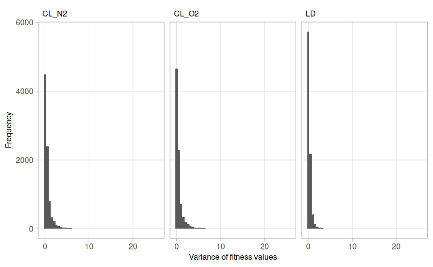

```r
fitness_stdev$variance <- fitness_stdev$sd_fitness^2
p <- ggplot(fitness_stdev, aes(x=variance)) + geom_histogram(bins=50) + theme_light() + ylab("Frequency") + xlab("Variance of fitness values") + facet_wrap(~condition)+ theme(panel.grid.minor =element_blank(), legend.position = "none", strip.background=element_rect(fill = NA, color = "white"), strip.text.x = element_text(size = 8, colour = "black", hjust = 0), axis.text=element_text(size=8), axis.title=element_text(size=8), legend.text=element_text(size=8))
p
ggsave("../EDA_output/diagnostic_plots/histogram_variance.pdf", plot=p, width=6.8, height=2, units="in")
```

```r
fitness_stdev[is.na(fitness_stdev$sd_fitness),]$sd_fitness <- median(fitness_stdev[fitness_stdev$condition=="CL_N2",]$sd_fitness,na.rm=TRUE)
write_tsv(unique(fitness_stdev[,c("condition", "sgRNA_target", "norm","sd_fitness")]), "../EDA_output/MoCHI/variant_stdev.csv")
rm(fitness_stdev)
```

# 4 Exploratory data analysis

## 4.1 Overview fitness distribution

Normalization: WT is set to “1”, and the median of K214 substitutions as “0”. For all three conditions, the data set shows a bimodal distribution. This is most pronounced for the continuous light, N2 feed condition.

### 4.1.1 Complete library

```r
plot_subset <- unique(fitness_data[,c("sgRNA_target", "norm", "p_fit_adj_WT", "condition")])

p <- ggplot(plot_subset, aes(x=norm, group=condition, fill=condition, color=condition, linetype=condition)) + geom_density(adjust=1.5, alpha=.4) + theme_light() + theme(panel.grid.minor =element_blank(), legend.title = element_blank()) + scale_fill_manual(values=col_conditions, labels = c("Continuous light, N2 feed", "Continuous light, O2 feed", "Light-dark cycles, O2 feed")) + scale_color_manual(values=col_conditions, labels = c("Continuous light, N2 feed", "Continuous light, O2 feed", "Light-dark cycles, O2 feed")) + scale_linetype_manual(values=c("CL_N2"="solid", "CL_O2"="dashed", "LD"="dotted"), labels=c("Continuous light, N2 feed", "Continuous light, O2 feed", "Light-dark cycles, O2 feed")) + labs(title="Complete CbbM library", x="Normalized fitness value")
p
ggsave("../EDA_output/pdf/whole_library_densityplot.pdf", plot=p, width=11.5, height=8)
```

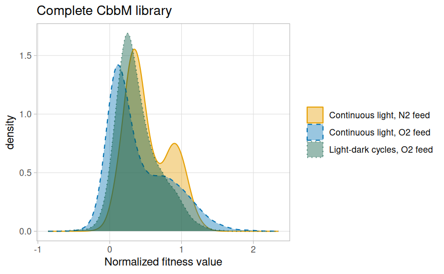

```r
ggsave("../EDA_output/png/whole_library_densityplot.png", plot=p, width=11.5, height=8)
```

```r
for(cond in unique(plot_subset$condition)){
  print(cond)
  temp_subs <- subset(plot_subset, plot_subset$condition==cond)
  print(nrow(temp_subs))
  print("Above 1")
  print(nrow(subset(temp_subs, temp_subs$norm > 1)))
  print("Above 1, percentage")
  print(nrow(subset(temp_subs, temp_subs$norm > 1))/nrow(temp_subs))
  print("Above 1 and significantly higher than WT")
  print(nrow(subset(temp_subs, temp_subs$norm > 1 & temp_subs$p_fit_adj_WT < 0.05)))
  print("Above 1 and significantly higher than WT, percentage")
  print(nrow(subset(temp_subs, temp_subs$norm > 1 & temp_subs$p_fit_adj_WT < 0.05))/nrow(temp_subs))
  print("Below 0")
  print(nrow(subset(temp_subs, temp_subs$norm < 0)))
  print("Below 0, percentage")
  print(nrow(subset(temp_subs, temp_subs$norm < 0))/nrow(temp_subs))
}
```

```
[1] "CL_N2"
[1] 13966
[1] "Above 1"
[1] 1351
[1] "Above 1, percentage"
[1] 0.09673493
[1] "Above 1 and significantly higher than WT"
[1] 180
[1] "Above 1 and significantly higher than WT, percentage"
[1] 0.01288844
[1] "Below 0"
[1] 159
[1] "Below 0, percentage"
[1] 0.01138479
[1] "CL_O2"
```

[output cut: 27 more lines]

### 4.1.2 Combinatorial library

When only checking mutant variants present in the combinatorial library with more than a single amino acid exchange, we still observe a clear bimodal distribution very similar to the one of the complete data set.

```r
plot_subset <- unique(subset(fitness_data, (fitness_data$category %in% c("combinatorial")) & fitness_data$number_muts > 1)[,c("sgRNA_target", "norm", "p_fit_adj_WT", "condition")])
length(unique(plot_subset$sgRNA_target))
```

```
[1] 12708
```

```r
length(unique(plot_subset$sgRNA_target))/length(unique(fitness_data$sgRNA_target))
```

```
[1] 0.9099241
```

```r
p <- ggplot(plot_subset, aes(x=norm, group=condition, fill=condition, color=condition, linetype=condition)) + geom_density(adjust=1.5, alpha=.4) + theme_light() + theme(panel.grid.minor =element_blank(), legend.title = element_blank()) + scale_linetype_manual(values=c("CL_N2"="solid", "CL_O2"="dashed", "LD"="dotted"), labels=c("Continuous light, N2 feed", "Continuous light, O2 feed", "Light-dark cycles, O2 feed")) + scale_fill_manual(values=col_conditions, labels = c("Continuous light, N2 feed", "Continuous light, O2 feed", "Light-dark cycles, O2 feed")) + scale_color_manual(values=col_conditions, labels = c("Continuous light, N2 feed", "Continuous light, O2 feed", "Light-dark cycles, O2 feed")) + labs(title="Combinatorial CbbM library with more than one exchange", x="Normalized fitness value")
p
ggsave("../EDA_output/pdf/combinatorial_w-oSingles_library_densityplot.pdf", plot=p, width=11.5, height=8)
```

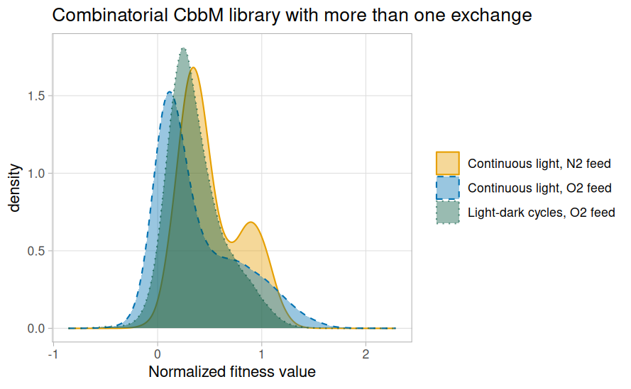

```r
ggsave("../EDA_output/pdf/combinatorial_w-oSingles_library_densityplot.png", plot=p, width=11.5, height=8)
```

```r
for(cond in unique(plot_subset$condition)){
  print(cond)
  temp_subs <- subset(plot_subset, plot_subset$condition==cond)
  print(nrow(temp_subs))
  print("Above 1")
  print(nrow(subset(temp_subs, temp_subs$norm > 1)))
  print("Above 1, percentage")
  print(nrow(subset(temp_subs, temp_subs$norm > 1))/nrow(temp_subs))
  print("Above 1 and significantly higher than WT")
  print(nrow(subset(temp_subs, temp_subs$norm > 1 & temp_subs$p_fit_adj_WT < 0.05)))
  print("Above 1 and significantly higher than WT, percentage")
  print(nrow(subset(temp_subs, temp_subs$norm > 1 & temp_subs$p_fit_adj_WT < 0.05))/nrow(temp_subs))
  print("Below 0")
  print(nrow(subset(temp_subs, temp_subs$norm < 0)))
  print("Below 0, percentage")
  print(nrow(subset(temp_subs, temp_subs$norm < 0))/nrow(temp_subs))
}
```

```
[1] "CL_N2"
[1] 12708
[1] "Above 1"
[1] 1059
[1] "Above 1, percentage"
[1] 0.08333333
[1] "Above 1 and significantly higher than WT"
[1] 93
[1] "Above 1 and significantly higher than WT, percentage"
[1] 0.007318225
[1] "Below 0"
[1] 106
[1] "Below 0, percentage"
[1] 0.008341202
[1] "CL_O2"
```

[output cut: 27 more lines]

```r
rm(temp_subs)
```

### 4.1.3 Saturational library

```r
plot_subset <- unique(subset(fitness_data, fitness_data$category %in% c("saturational", "combiANDsatur"))[,c("sgRNA_target", "norm", "p_fit_adj_WT", "num_barcodes", "condition")])
length(unique(plot_subset$sgRNA_target))
```

```
[1] 1223
```

```r
length(unique(plot_subset$sgRNA_target))/length(unique(fitness_data$sgRNA_target))
```

```
[1] 0.08756981
```

```r
p <- ggplot(plot_subset, aes(x=norm, group=condition, fill=condition, color=condition, linetype=condition)) + geom_density(adjust=1.5, alpha=.4) + theme_light() + theme(panel.grid.minor =element_blank(), legend.title = element_blank()) + scale_fill_manual(values=col_conditions, labels = c("Continuous light, N2 feed", "Continuous light, O2 feed", "Light-dark cycles, O2 feed")) + scale_color_manual(values=col_conditions, labels = c("Continuous light, N2 feed", "Continuous light, O2 feed", "Light-dark cycles, O2 feed")) + labs(title="Saturational CbbM library", x="Normalized fitness value") + scale_linetype_manual(values=c("CL_N2"="solid", "CL_O2"="dashed", "LD"="dotted"), labels=c("Continuous light, N2 feed", "Continuous light, O2 feed", "Light-dark cycles, O2 feed"))
p
ggsave("../EDA_output/pdf/saturational_library_densityplot.pdf", plot=p, width=11.5, height=8)
```

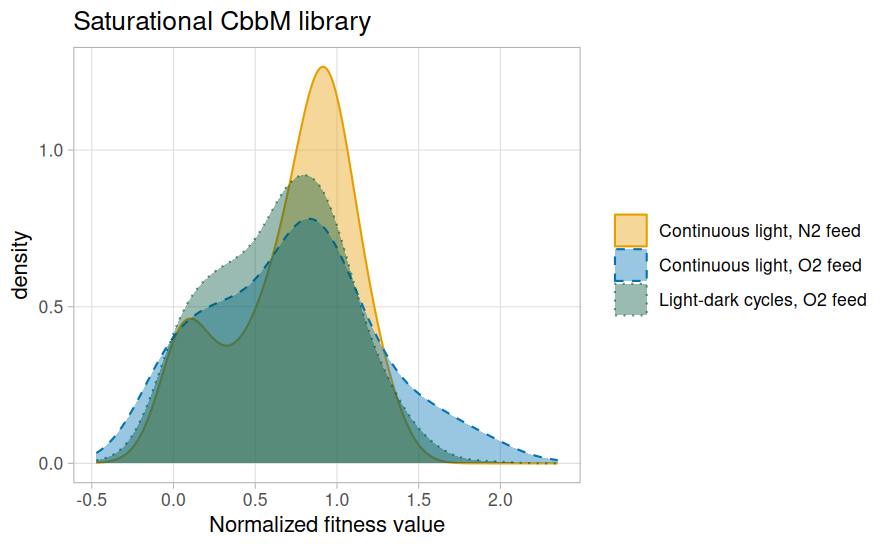

```r
ggsave("../EDA_output/pdf/saturational_library_densityplot.png", plot=p, width=11.5, height=8)
```

```r
for(cond in unique(plot_subset$condition)){
  print(cond)
  temp_subs <- subset(plot_subset, plot_subset$condition==cond)
  print(nrow(temp_subs))
  print("Above 1")
  print(nrow(subset(temp_subs, temp_subs$norm > 1)))
  print("Above 1, percentage")
  print(nrow(subset(temp_subs, temp_subs$norm > 1))/nrow(temp_subs))
  print("Above 1 and significantly higher than WT")
  print(nrow(subset(temp_subs, temp_subs$norm > 1 & temp_subs$p_fit_adj_WT < 0.05)))
  print("Above 1 and significantly higher than WT, percentage")
  print(nrow(subset(temp_subs, temp_subs$norm > 1 & temp_subs$p_fit_adj_WT < 0.05))/nrow(temp_subs))
  print("Below 0")
  print(nrow(subset(temp_subs, temp_subs$norm < 0)))
  print("Below 0, percentage")
  print(nrow(subset(temp_subs, temp_subs$norm < 0))/nrow(temp_subs))
}
```

```
[1] "CL_N2"
[1] 1223
[1] "Above 1"
[1] 291
[1] "Above 1, percentage"
[1] 0.2379395
[1] "Above 1 and significantly higher than WT"
[1] 87
[1] "Above 1 and significantly higher than WT, percentage"
[1] 0.07113655
[1] "Below 0"
[1] 42
[1] "Below 0, percentage"
[1] 0.03434178
[1] "CL_O2"
```

[output cut: 27 more lines]

### 4.1.4 Comparison combinatorial and saturational library

When comparing fitness values between the combinatorial and saturational part directly, it becomes obvious that the saturational part contains, relatively speaking, more variants with functional Rubisco variants, i.e. the right peak of the bimodal distribution is higher than the left peak contrasting to the case in the combinatorial part of the library.

```r
fitness_data_2 <- subset(fitness_data, fitness_data$category!="notExpected" & fitness_data$category!="WT")
fitness_data_2[fitness_data_2$category=="combiANDsatur",]$category <- "saturational"
fitness_data_2 <- unique(fitness_data_2[,c("sgRNA_target", "norm", "p_fit_adj_WT", "category", "condition")])
p <- ggplot(fitness_data_2, aes(x=norm, fill=category, color=category, linetype=category)) + geom_density(adjust=1.5, alpha=.4) + theme_light() + theme(panel.grid.minor =element_blank(), legend.title = element_blank()) + scale_fill_manual(values=c(col_combi_sat), labels = c("Combinatorial", "Saturational")) + scale_color_manual(values=c(col_combi_sat), labels = c("Combinatorial", "Saturational")) + labs(x="Normalized fitness value") + scale_linetype_manual(values=c("combinatorial"="solid", "saturational"="dashed"), labels=c("Combinatorial", "Saturational")) + facet_wrap(~condition) + theme(panel.grid.minor = element_blank(), strip.background=element_rect(fill = NA, color = "white"), strip.text.x = element_text(size = 8, colour = "black", hjust = 0), axis.text=element_text(size=8), axis.title=element_text(size=8), legend.text=element_text(size=8))
p
ggsave("../EDA_output/pdf/density_compareCombiSatur.pdf", plot=p, width=10, height=4, units="cm")
```

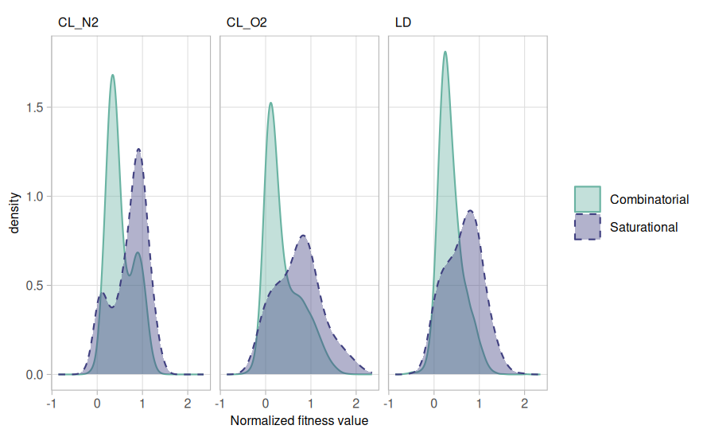

```r
ggsave("../EDA_output/png/density_compareCombiSatur.png", plot=p)
```

```r
rm(fitness_data_2)
```

## 4.2 Overview growth all variants

```r
fit_factor <- fitness_data
fit_factor$sgRNA_target <- factor(fit_factor$sgRNA_target, levels=c(unique(subset(fit_factor, !fit_factor$sgRNA_target %in% c("WT", "K214R"))$sgRNA_target), "WT", "K214R"))
p <- ggplot(fit_factor, aes(x=time, y=wmean_log2FoldChange, group=sgRNA_target, color=sgRNA_target, linewidth=sgRNA_target, alpha=sgRNA_target)) + geom_line() + scale_color_manual(values=c("K214R"="purple", "WT"="black"), na.value="lightgray") + theme_light() + xlab("Time (generations)") + ylab("log2FC(to g=0)") + scale_discrete_manual("linewidth", values=c("K214R"=0.3, "WT"=0.3), na.value=0.1) + scale_alpha_manual(values=c("K214R"=1, "WT"=1), na.value=0.5) + facet_wrap(~condition) + theme(panel.grid.minor = element_blank(), strip.background=element_rect(fill = NA, color = "white"), strip.text.x = element_text(size = 8, colour = "black", hjust = 0), axis.text=element_text(size=8), axis.title=element_text(size=8), legend.text=element_text(size=8), legend.title=element_blank())
p
ggsave("../EDA_output/pdf/all_sgRNAtargets_timeLinePlot.pdf", plot=p, height=1.5, width=5, units="in")
```

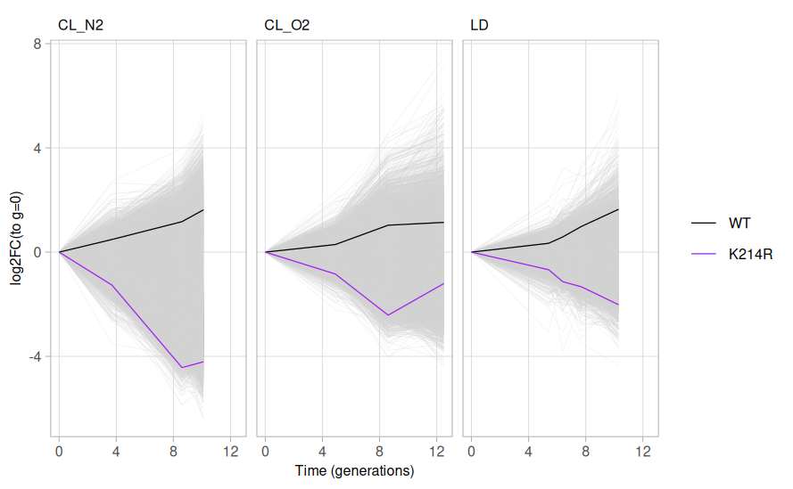

```r
ggsave("../EDA_output/png/all_sgRNAtargets_timeLinePlot.png", plot=p, height=1.5, width=5, units="in")
```

## 4.3 Plot WT and K214 variants

The 95% confidence interval for the weighted mean log2FC of all WT barcodes is relatively small, meaning that we can rely relatively well on the respective data. In total, 30 different barcodes for WT were taken into account. These were the highest 30 barcodes assigned to the WT variant present in the complete data set. The high number of WT barcodes as well as their high count numbers both contribute to a reliable estimate of the corresponding fitness.

```r
WT_subset <- unique(subset(fitness_data, fitness_data$sgRNA_target=="WT")[,c("num_barcodes", "sd_log2FoldChange", "lfcSE", "time", "wmean_log2FoldChange", "sgRNA_target", "sgRNA", "log2FoldChange", "weight_lfcSE", "condition")])
p <- lineplot_CVinterval_severalColours_meanlog2(WT_subset) + labs(title="WT with 95% CI")
p
ggsave("../EDA_output/pdf/WT_timeLinePlot.pdf", plot=p)
```

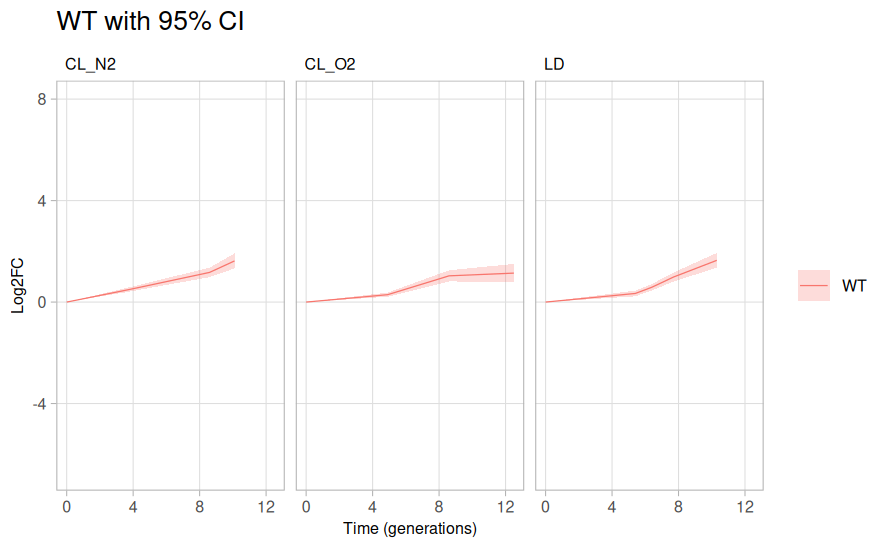

```r
ggsave("../EDA_output/png/WT_timeLinePlot.png", plot=p)
```

Here, the log2FC charts of the different barcodes used for determining WT data are plotted. 95% confidence intervals are colored according to the standard error of the log2FC - the more transparent, the higher the standard error and the other way round. The barcodes deviating from the overall standard have higher standard errors than the barcodes which are close to the overall mean. In black, the overall trend is added.

It seems as if most of the 30 barcodes agreed well. Note that, for continuous light and an O2-containing feed, several barcodes go a bit down for the last time point. It seems as if selection was already lost then or at least got much weaker.

```r
p <- lineplot_CVinterval_severalColours_log2(WT_subset) + labs(title="WT barcodes with 95% CI") + geom_line(aes(x=time, y=wmean_log2FoldChange, group=sgRNA_target), color="black")
p
ggsave("../EDA_output/pdf/WT_barcodes_timeLinePlot.pdf", plot=p)
```

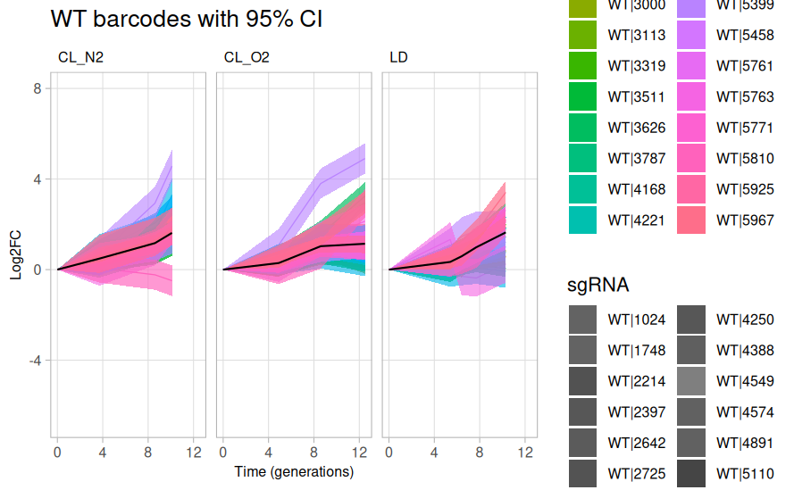

```r
ggsave("../EDA_output/png/WT_barcodes_timeLinePlot.png", plot=p)
```

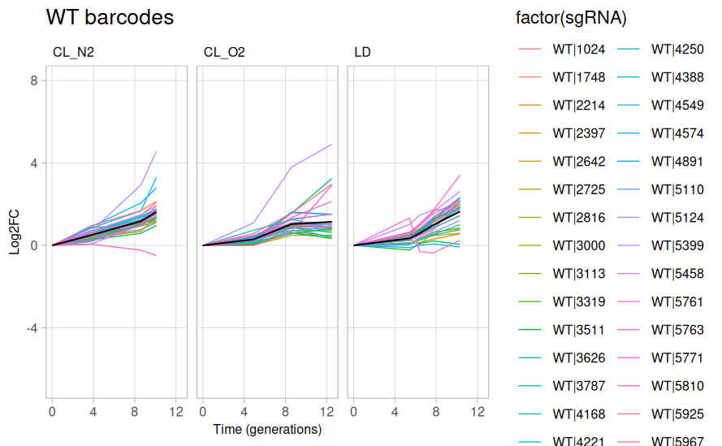

```r
lineplot_severalColours_log2(WT_subset) + labs(title="WT barcodes") + geom_line(aes(x=time, y=wmean_log2FoldChange, group=sgRNA_target), color="black")
```

Here, all K214 mutant variants and their weighted mean log2FoldChange are plotted. All have a tendency to decrease in relative abundance. For continuous light and an O2-containing gas feed, the last time point looks as if selection got worse. Same also holds, to some degree, for the N2-containing feed. K214H goes pretty wild in the LD condition.

```r
K214_subset <- unique(subset(fitness_data, grepl("K214", fitness_data$sgRNA_target))[,c("num_barcodes", "sd_log2FoldChange", "lfcSE", "time", "wmean_log2FoldChange", "sgRNA_target", "sgRNA", "log2FoldChange", "weight_lfcSE", "condition", "norm")])
p <- lineplot_CVinterval_severalColours_meanlog2(K214_subset) + labs(title="K214 variants with 95% CI")
p
ggsave("../EDA_output/pdf/K214_variants_timeLinePlot.pdf", plot=p)
```

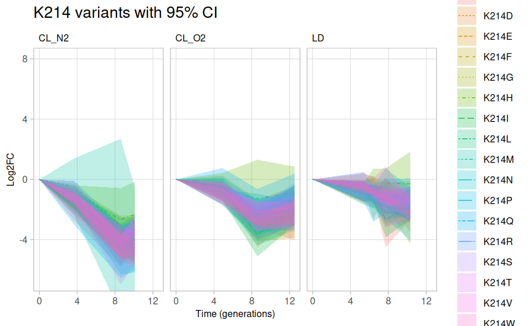

```r
ggsave("../EDA_output/png/K214_variants_timeLinePlot.png", plot=p)
```

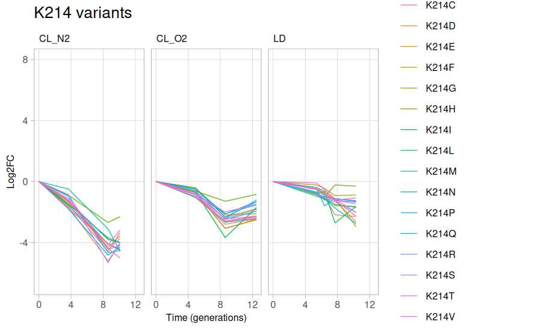

```r
lineplot_severalColours_meanlog2(K214_subset) + labs(title="K214 variants")
```

K214H is the K214 variant with the highest fitness score under all three investigated conditions. Its fitness value was determined on basis of 3 barcodes, of which one shows a slower decrease than the other 2 (in CL_O2 and LD, it does not even show a decrease), but has a lower standard error. In black, the weighted mean log2FC is shown.

```r
K214H_subset <- unique(subset(fitness_data, grepl("K214H", fitness_data$sgRNA_target))[,c("num_barcodes", "sd_log2FoldChange", "lfcSE", "time", "wmean_log2FoldChange", "sgRNA_target", "sgRNA", "log2FoldChange", "weight_lfcSE", "condition")])
p <- lineplot_CVinterval_severalColours_log2(K214H_subset) + labs(title="K214H barcodes with 95% CI") + geom_line(aes(x=time, y=wmean_log2FoldChange, group=sgRNA_target), color="black")
p
ggsave("../EDA_output/pdf/K214H_barcodes_timeLinePlot.pdf", plot=p)
```

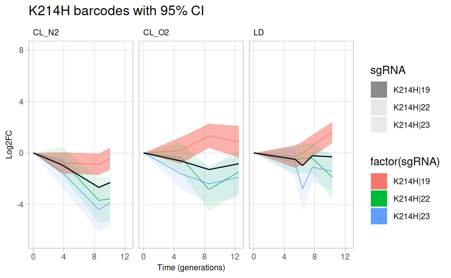

```r
ggsave("../EDA_output/png/K214H_barcodes_timeLinePlot.png", plot=p)
```

Compare K214H to WT. In LD, due to the strongly rising barcode, K214H and WT are not significantly different (if we take 95% confidence intervals as measure for “Could it even be a significant difference”).

```r
p <- lineplot_CVinterval_severalColours_meanlog2(bind_rows(WT_subset,K214H_subset)) + labs(title="K214H and WT")
p
ggsave("../EDA_output/pdf/WT_K214H_timeLinePlot.pdf", plot=p)
```

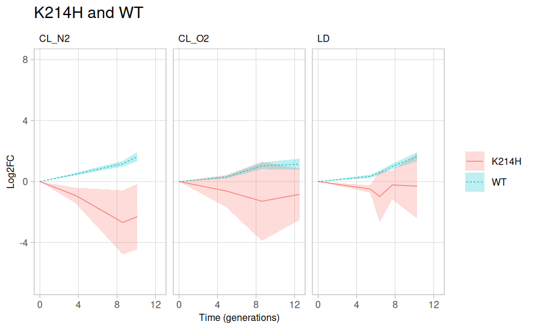

```r
ggsave("../EDA_output/png/WT_K214H_timeLinePlot.png", plot=p)
```

K214 variants K214D (LD), K214R (CL_N2) and K214E (CL_O2) were the ones which were used for median normalization (compare compare_weightingStrategies_2ndRound.html). All look as if they were good negative controls in subsequent plots. K214R is closest to a normalized fitness value of 0 of these three. When calculating the absolute distance to 0 of all variants in the normalized data set, K214L also seems to be a good candidate. Since K214R has a lower Gini index and a comparable absolute distance to 0 in all data sets, K214R will be plotted as negative control subsequently.

```r
K214DRT_subset <- unique(subset(fitness_data, fitness_data$sgRNA_target %in% c("K214D", "K214R", "K214E", "K214L"))[,c("num_barcodes", "sd_log2FoldChange", "lfcSE", "time", "wmean_log2FoldChange", "sgRNA_target", "sgRNA", "log2FoldChange", "weight_lfcSE", "condition", "norm")])
p <- lineplot_CVinterval_severalColours_meanlog2(bind_rows(WT_subset,K214DRT_subset)) + labs(title="K214 variants and WT")
p
ggsave("../EDA_output/pdf/WT_K214DRTL_timeLinePlot.pdf", plot=p)
```

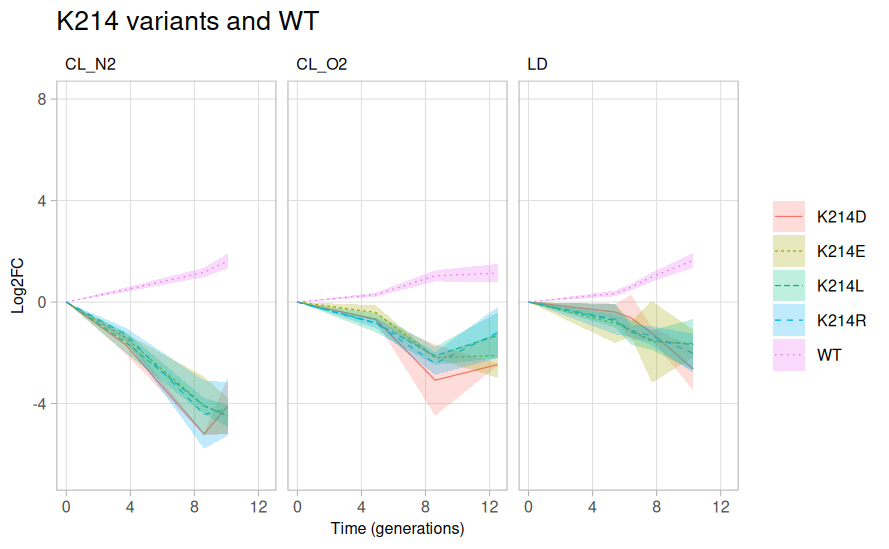

```r
ggsave("../EDA_output/png/WT_K214DRTL_timeLinePlot.png", plot=p)
```

```r
pivot_wider(unique(K214DRT_subset[,c("sgRNA_target", "condition", "norm")]), values_from=norm, names_from=condition)
```

| sgRNA_target | CL_N2 | CL_O2 | LD |
| --- | --- | --- | --- |
| K214D | -0.13897448 | -0.242886848 | 0.00000000 |
| K214E | 0.01111954 | 0.000000000 | -0.09534488 |
| K214L | -0.01684320 | 0.003911234 | -0.07501154 |
| K214R | 0.00000000 | -0.043372329 | -0.06588767 |

```r
K214_set <- pivot_wider(unique(K214_subset[,c("sgRNA_target", "condition", "norm")]), values_from=norm, names_from=condition)
K214_set$sum <- apply(abs(K214_set[,c(2:4)]), 1, sum)
K214_set$gini <- apply(abs(K214_set[,c(2:4)]), 1, Gini)
K214_set[order(K214_set$sum),]
```

| sgRNA_target | CL_N2 | CL_O2 | LD | sum | gini |
| --- | --- | --- | --- | --- | --- |
| K214L | -0.01684320 | 0.003911234 | -0.07501154 | 0.09576597 | 0.7424381 |
| K214E | 0.01111954 | 0.000000000 | -0.09534488 | 0.10646441 | 0.8955563 |
| K214R | 0.00000000 | -0.043372329 | -0.06588767 | 0.10926000 | 0.6030356 |
| K214S | -0.02996167 | -0.108920142 | -0.01496114 | 0.15384296 | 0.6107462 |
| K214T | 0.07707068 | 0.010419108 | 0.07999598 | 0.16748577 | 0.4154196 |
| K214Q | -0.12149474 | 0.033971702 | 0.04130469 | 0.19677113 | 0.4447961 |
| K214G | 0.03356966 | 0.007107406 | -0.17621019 | 0.21688725 | 0.7796806 |
| K214P | 0.06582335 | 0.047027588 | 0.11006789 | 0.22291882 | 0.2827949 |
| K214V | 0.01755259 | -0.107283250 | 0.15176099 | 0.27659683 | 0.4852131 |
| K214Y | -0.01952116 | -0.251007280 | -0.01005118 | 0.28057963 | 0.8587797 |

[output cut: 8 more lines]

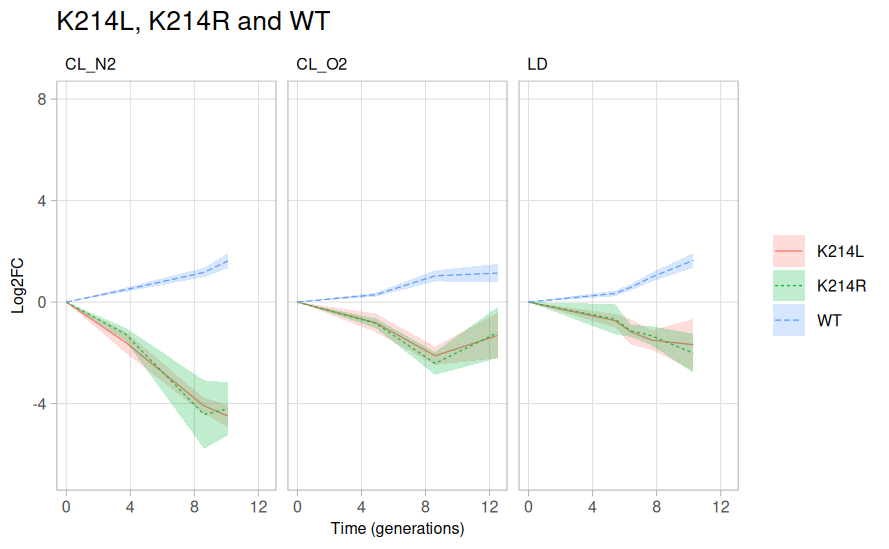

```r
K214L_subset <- unique(subset(fitness_data, fitness_data$sgRNA_target %in% c("K214L", "K214R"))[,c("num_barcodes", "sd_log2FoldChange", "lfcSE", "time", "wmean_log2FoldChange", "sgRNA_target", "sgRNA", "log2FoldChange", "weight_lfcSE", "condition", "norm")])
lineplot_CVinterval_severalColours_meanlog2(bind_rows(WT_subset,K214L_subset)) + labs(title="K214L, K214R and WT")
```

```r
neg_control_K214 <- "K214R"
```

All K214 variants and WT

```r
p <- lineplot_severalColours_meanlog2(bind_rows(K214_subset, WT_subset)) + labs(title="K214 variants and WT") + scale_color_manual(values=c("WT"="black"), na.value="lightgray")
p
ggsave("../EDA_output/pdf/WT_K214_variants_timeLinePlot.pdf", plot=p)
```

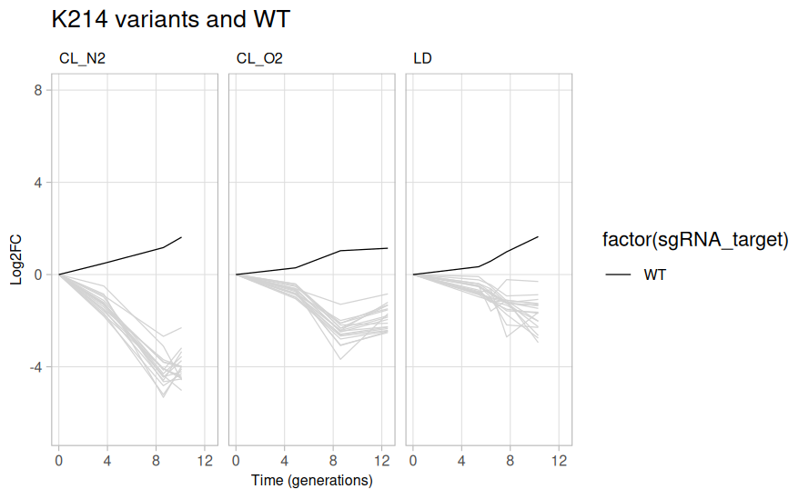

```r
ggsave("../EDA_output/png/WT_K214_variants_timeLinePlot.png", plot=p)
```

## 4.4 Barplots number mutations ~ fitness

When investigating all mutant variants present in the library, including the ones which occurred spontaneously, there is a clear trend observable that the more amino acid exchanges/mutations were introduced, the lower the mean fitness. This matches well with what was reported in literature before.

```r
red_fitness <- unique(fitness_data[c("sgRNA_target", "mean_fitness", "condition", "category", "number_muts", "norm", "p_fit_adj_WT", "num_barcodes")])
p <- ggplot(red_fitness, aes(x=number_muts, y=norm, group=number_muts, colour=number_muts, fill=number_muts)) + geom_point(size=0.1, position=position_jitterdodge(dodge.width=0.9), color="#4a4a4aff") + theme_light() + stat_summary(fun="mean", geom="bar", alpha=0.3, position=position_dodge(width=0.9), linewidth=0, color="#4a4a4aff", fill="#4a4a4aff") + ylab("Weighted mean fitness") + facet_wrap(~condition)+ theme(panel.grid.minor =element_blank(), legend.position = "none", strip.background=element_rect(fill = NA, color = "white"), strip.text.x = element_text(size = 8, colour = "black", hjust = 0), axis.text=element_text(size=8), axis.title=element_text(size=8), legend.text=element_text(size=8))
p
ggsave("../EDA_output/pdf/bar_fitness_data_numberMuts_complete.pdf", p, width=30, height=18, units="cm")
```

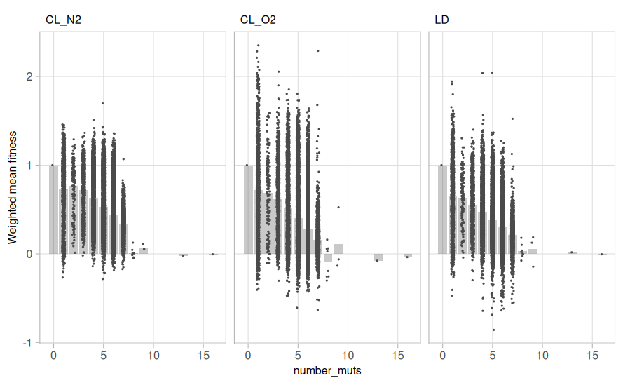

```r
ggsave("../EDA_output/png/bar_fitness_data_numberMuts_complete.png", p, width=30, height=18, units="cm")
```

When checking the whole “expected” library, i.e. the combination of saturational and combinatorial library, this trend is still observable.

```r
expected_red_fitness <- subset(red_fitness, !red_fitness$category=="notExpected")
p <- ggplot(expected_red_fitness, aes(x=number_muts, y=norm, fill=number_muts, colour=number_muts, group=number_muts)) + stat_summary(fun="mean", geom="bar", alpha=0.3, position=position_dodge(width=0.9), linewidth=0, color="#4a4a4aff", fill="#4a4a4aff") + geom_point(size=0.05, alpha=0.7, position=position_jitterdodge(dodge.width=0.9), color="#4a4a4aff") + theme_light() + ylab("Normalized fitness score") + xlab("Number of intoduced amino acid exchanges") + theme(legend.position="none") + facet_wrap(~condition) + coord_cartesian(xlim=c(-0.2,7.2))+ theme(panel.grid.minor =element_blank(), legend.title = element_blank(), strip.background=element_rect(fill = NA, color = "white"), strip.text.x = element_text(size = 8, colour = "black", hjust = 0), axis.text=element_text(size=8), axis.title=element_text(size=8), legend.text=element_text(size=8))
p
ggsave("../EDA_output/pdf/bar_fitness_data_numberMuts_onlyExpected.pdf", p, width=5, height=2.4, units="in")
```

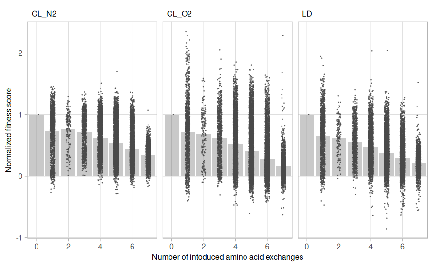

```r
ggsave("../EDA_output/png/bar_fitness_data_numberMuts_onlyExpected.png", p, width=5, height=3, units="in")
```

When only comparing the amino acid exchanges present in the combinatorial library, the overall trend that introducing another amino acid exchange decreases the fitness value becomes even clearer. At the same time, additionally introduced exchanges do not reduce the maximum fitness value.

```r
combinatorial_wide <- subset(expected_red_fitness, !expected_red_fitness$category=="saturational")
lm_fitness_data <- lm(norm ~ number_muts, combinatorial_wide)
summary(lm_fitness_data)
```

```
Call:
lm(formula = norm ~ number_muts, data = combinatorial_wide)

Residuals:
     Min       1Q   Median       3Q      Max
-1.29518 -0.22402 -0.04572  0.18624  2.04364

Coefficients:
             Estimate Std. Error t value Pr(>|t|)
(Intercept)  0.921151   0.007505  122.73   <2e-16 ***
number_muts -0.096703   0.001414  -68.39   <2e-16 ***
---
Signif. codes:  0 ‘***’ 0.001 ‘**’ 0.01 ‘*’ 0.05 ‘.’ 0.1 ‘ ’ 1

Residual standard error: 0.3158 on 38188 degrees of freedom
Multiple R-squared:  0.1091,    Adjusted R-squared:  0.1091
F-statistic:  4677 on 1 and 38188 DF,  p-value: < 2.2e-16
```

```r
lm_fitness_data <- lm(norm ~ number_muts, subset(combinatorial_wide, combinatorial_wide$condition == "CL_N2"))
summary(lm_fitness_data)
```

```
Call:
lm(formula = norm ~ number_muts, data = subset(combinatorial_wide,
    combinatorial_wide$condition == "CL_N2"))

Residuals:
     Min       1Q   Median       3Q      Max
-0.81547 -0.20798 -0.04122  0.18888  1.16395

Coefficients:
             Estimate Std. Error t value Pr(>|t|)
(Intercept)  0.988449   0.011546   85.61   <2e-16 ***
number_muts -0.091316   0.002175  -41.98   <2e-16 ***
---
Signif. codes:  0 ‘***’ 0.001 ‘**’ 0.01 ‘*’ 0.05 ‘.’ 0.1 ‘ ’ 1

Residual standard error: 0.2805 on 12728 degrees of freedom
Multiple R-squared:  0.1216,    Adjusted R-squared:  0.1216
F-statistic:  1762 on 1 and 12728 DF,  p-value: < 2.2e-16
```

```r
lm_fitness_data <- lm(norm ~ number_muts, subset(combinatorial_wide, combinatorial_wide$condition == "CL_O2"))
summary(lm_fitness_data)
```

```
Call:
lm(formula = norm ~ number_muts, data = subset(combinatorial_wide,
    combinatorial_wide$condition == "CL_O2"))

Residuals:
     Min       1Q   Median       3Q      Max
-1.00643 -0.26879 -0.08333  0.21430  2.11737

Coefficients:
             Estimate Std. Error t value Pr(>|t|)
(Intercept)  0.968194   0.015364   63.02   <2e-16 ***
number_muts -0.113957   0.002895  -39.37   <2e-16 ***
---
Signif. codes:  0 ‘***’ 0.001 ‘**’ 0.01 ‘*’ 0.05 ‘.’ 0.1 ‘ ’ 1

Residual standard error: 0.3733 on 12728 degrees of freedom
Multiple R-squared:  0.1086,    Adjusted R-squared:  0.1085
F-statistic:  1550 on 1 and 12728 DF,  p-value: < 2.2e-16
```

```r
lm_fitness_data <- lm(norm ~ number_muts, subset(combinatorial_wide, combinatorial_wide$condition == "LD"))
summary(lm_fitness_data)
```

```
Call:
lm(formula = norm ~ number_muts, data = subset(combinatorial_wide,
    combinatorial_wide$condition == "LD"))

Residuals:
     Min       1Q   Median       3Q      Max
-1.24018 -0.17207 -0.03075  0.14309  1.66143

Coefficients:
             Estimate Std. Error t value Pr(>|t|)
(Intercept)  0.806809   0.010654   75.73   <2e-16 ***
number_muts -0.084837   0.002007  -42.27   <2e-16 ***
---
Signif. codes:  0 ‘***’ 0.001 ‘**’ 0.01 ‘*’ 0.05 ‘.’ 0.1 ‘ ’ 1

Residual standard error: 0.2588 on 12728 degrees of freedom
Multiple R-squared:  0.1231,    Adjusted R-squared:  0.123
F-statistic:  1786 on 1 and 12728 DF,  p-value: < 2.2e-16
```

```r
p <- ggplot(combinatorial_wide, aes(x=number_muts, y=norm, fill=number_muts, colour=number_muts)) + stat_summary(fun="mean", geom="bar", alpha=0.3, position=position_dodge(width=0.9), linewidth=0, color="#4a4a4aff", fill="#4a4a4aff") + geom_point(size=0.1, position=position_jitterdodge(dodge.width=0.9), color="#4a4a4aff") + theme_light() + ylab("Normalized fitness score")+ theme(panel.grid.minor =element_blank(), legend.position = "none", strip.background=element_rect(fill = NA, color = "white"), strip.text.x = element_text(size = 8, colour = "black", hjust = 0), axis.text=element_text(size=8), axis.title=element_text(size=8), legend.text=element_text(size=8)) + facet_wrap(~condition) + coord_cartesian(xlim=c(-0.2,7.2))
p
ggsave("../EDA_output/pdf/bar_fitness_data_numberMuts_onlyCombi.pdf", p, width=30, height=18, units="cm")
```

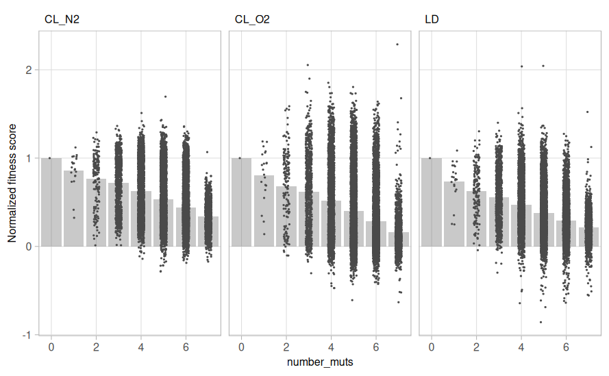

```r
ggsave("../EDA_output/png/bar_fitness_data_numberMuts_onlyCombi.png", p, width=30, height=18, units="cm")
```

```r
rm(lm_fitness_data)
```

When only checking variants with fitness values significantly different to the “wild-type” sequence, this pattern gets dampened, even though there is still some trend in this direction observable with more and more variants showing relatively high scores.

```r
combinatorial_wide <- subset(combinatorial_wide, combinatorial_wide$p_fit_adj_WT<0.05)

p <- ggplot(combinatorial_wide, aes(x=number_muts, y=norm, fill=number_muts, colour=number_muts)) + geom_point(size=0.1, position=position_jitterdodge(dodge.width=0.9)) + theme_light() + stat_summary(fun="mean", geom="bar", alpha=0.3, position=position_dodge(width=0.9), linewidth=0) + ylab("Weighted mean fitness") + facet_wrap(~condition) + coord_cartesian(xlim=c(0.8,7.2))+ theme(panel.grid.minor =element_blank(), legend.title = element_blank())+ theme(panel.grid.minor =element_blank(), legend.position = "none", strip.background=element_rect(fill = NA, color = "white"), strip.text.x = element_text(size = 8, colour = "black", hjust = 0), axis.text=element_text(size=8), axis.title=element_text(size=8), legend.text=element_text(size=8))
p
ggsave("../EDA_output/pdf/bar_fitness_data_numberMuts_onlyCombi_onlySignificant.pdf", p, width=18, height=18, units="cm")
```

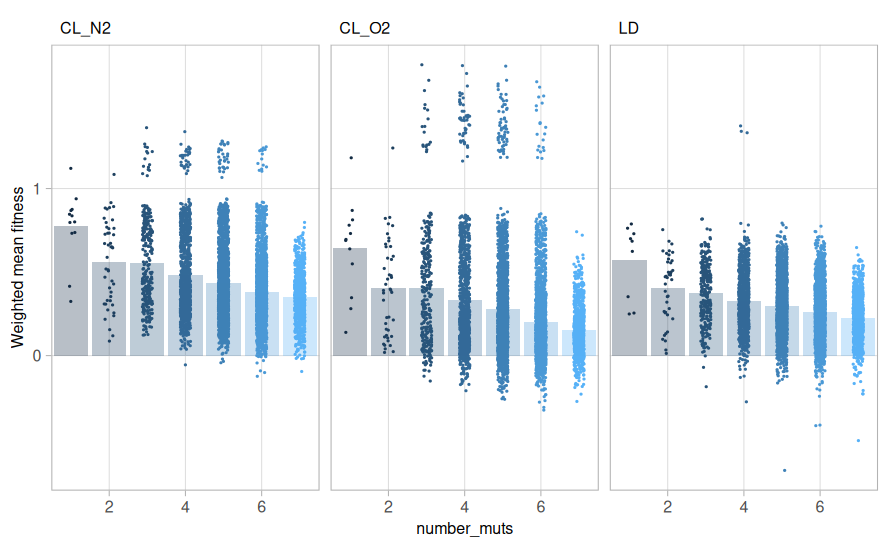

```r
ggsave("../EDA_output/png/bar_fitness_data_numberMuts_onlyCombi_onlySignificant.png", p, width=18, height=18, units="cm")
```

## 4.5 Correlation with different zero-shot predictors and similar

There are different ways of predicting the effect of higher order mutant variants. For designing the library, no prior knowledge was available. For this reason, zero-shot predictions using EVmutation and DeepSequence were performed. When data for single-site mutants is available, an additive model can be used that is assuming independence of different amino acid exchanges. Predictions of this model were calculated using python.

```r
combi_sat_alpha <- c(combinatorial=0.2, saturational=0.2, WT=1.0)
combi_sat_shape <- c(combinatorial=16, saturational=16, WT=4)
combi_sat_size <- c(combinatorial=0.4, saturational=0.4, WT=0.8)
dotsize <- 0.02
pointshape <- 16
alphalevel <- 0.4
line_width_for_plots <- 0.4
red_fitness <- unique(fitness_data[c("sgRNA_target", "norm", "condition", "category", "EVcoup_predict", "DeepSeq_predict", "MSA_Transform", "additive_score", "proteinNPT_predict", "MoCHI_mean", "MoCHI_sd")])
red_fitness[red_fitness$category=="combiANDsatur",]$category <- "saturational"
red_fitness <- subset(red_fitness, red_fitness$category != "notExpected")
red_fitness[red_fitness$category=="WT",]$EVcoup_predict <- 0
red_fitness_allConditions <- red_fitness
red_fitness_oneCondition <- subset(red_fitness, red_fitness$condition=="CL_N2")
red_fitness_allConditions_noNA_DeepSeq <- subset(red_fitness_allConditions, !is.na(red_fitness_allConditions$DeepSeq_predict))
red_fitness_oneCondition_noNA_DeepSeq <- subset(red_fitness_oneCondition, !is.na(red_fitness_oneCondition$DeepSeq_predict))
rm(red_fitness)
```

### 4.5.1 Comparison EVmutation, DeepSequence

```r
for(cat in c("combinatorial", "saturational")){
  print(cat)
  subset_forLoop <- subset(red_fitness_oneCondition_noNA_DeepSeq, red_fitness_oneCondition_noNA_DeepSeq$category==cat & red_fitness_oneCondition_noNA_DeepSeq$condition=="CL_N2")
  lm <- lm(DeepSeq_predict~EVcoup_predict, subset_forLoop)
  correlation <- cor.test(subset_forLoop$EVcoup_predict, subset_forLoop$DeepSeq_predict, method = 'spearman')
  print(nrow(subset_forLoop))
  print(correlation)
  correlation <- cor.test(subset_forLoop$EVcoup_predict, subset_forLoop$DeepSeq_predict, method = 'pearson')
  print(nrow(subset_forLoop))
  print(correlation)
}
```

```
[1] "combinatorial"
[1] 12708

    Spearman's rank correlation rho

data:  subset_forLoop$EVcoup_predict and subset_forLoop$DeepSeq_predict
S = 1.4917e+11, p-value < 2.2e-16
alternative hypothesis: true rho is not equal to 0
sample estimates:
      rho
0.5638764

[1] 12708

    Pearson's product-moment correlation

data:  subset_forLoop$EVcoup_predict and subset_forLoop$DeepSeq_predict
t = 81.392, df = 12706, p-value < 2.2e-16
alternative hypothesis: true correlation is not equal to 0
95 percent confidence interval:
 0.5738608 0.5967197
sample estimates:
      cor
0.5854065

[1] "saturational"
[1] 1065

    Spearman's rank correlation rho

data:  subset_forLoop$EVcoup_predict and subset_forLoop$DeepSeq_predict
S = 37504520, p-value < 2.2e-16
alternative hypothesis: true rho is not equal to 0
sample estimates:
      rho
0.8137113

[1] 1065

    Pearson's product-moment correlation

data:  subset_forLoop$EVcoup_predict and subset_forLoop$DeepSeq_predict
t = 43.657, df = 1063, p-value < 2.2e-16
alternative hypothesis: true correlation is not equal to 0
95 percent confidence interval:
 0.7786249 0.8217409
sample estimates:
      cor
0.8012205
```

```r
scat <- ggplot(red_fitness_oneCondition_noNA_DeepSeq, aes(x=EVcoup_predict, y=DeepSeq_predict, color=category, alpha=category, linetype=category, shape=category, size=category)) + geom_point() + scale_shape_manual(values=combi_sat_shape) + scale_size_manual(values=combi_sat_size) + geom_smooth(method = "lm", se=FALSE, color="black", formula = y ~ x, linewidth=line_width_for_plots) + scale_linetype_manual(values=c("combinatorial"="dashed", "saturational"="twodash")) + theme_light() + xlab("EVcouplings fitness prediction") + ylab("DeepSequence fitness prediction") + scale_alpha_manual(values=combi_sat_alpha) + scale_color_manual(values=col_combi_sat) + theme(panel.grid.minor =element_blank(), legend.position = "none", strip.background=element_rect(fill = NA, color = "white"), strip.text.x = element_text(size = 8, colour = "black", hjust = 0), axis.text=element_text(size=8), axis.title=element_text(size=8), legend.text=element_text(size=8), legend.title = element_blank())
scat
ggsave("../EDA_output/pdf/scatter_DeepSeq_EVcoup.pdf", scat, width=2, height=2, units="in")
```

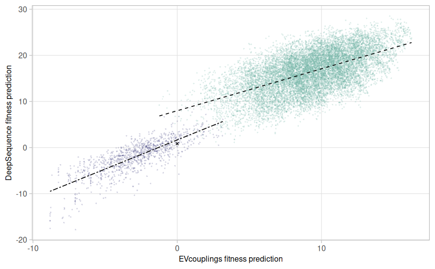

```r
ggsave("../EDA_output/png/scatter_DeepSeq_EVcoup.png", scat, width=2, height=2, units="in")
```

### 4.5.2 Comparison EVmutation, MSA Transformer

```r
for(cat in c("combinatorial", "saturational")){
  print(cat)
  subset_forLoop <- subset(red_fitness_oneCondition, red_fitness_oneCondition$category==cat & red_fitness_oneCondition$condition=="CL_N2")
  print(nrow(subset_forLoop))
  correlation <- cor.test(subset_forLoop$EVcoup_predict, subset_forLoop$MSA_Transform, method = 'spearman')
  print(nrow(subset_forLoop))
  print(correlation)
  correlation <- cor.test(subset_forLoop$EVcoup_predict, subset_forLoop$MSA_Transform, method = 'pearson')
  print(nrow(subset_forLoop))
  print(correlation)
}
```

[output not shown]

```r
scat <- ggplot(red_fitness_oneCondition, aes(x=EVcoup_predict, y=MSA_Transform, color=category, alpha=category, linetype=category, shape=category, size=category)) + geom_point() + scale_shape_manual(values=combi_sat_shape) + scale_size_manual(values=combi_sat_size) + geom_smooth(method = "lm", se=FALSE, color="black", formula = y ~ x, linewidth=line_width_for_plots) + scale_linetype_manual(values=c("combinatorial"="dashed", "saturational"="twodash")) + theme_light() + xlab("EVcouplings fitness prediction") + ylab("MSA Transform fitness prediction") + scale_alpha_manual(values=combi_sat_alpha) + scale_color_manual(values=col_combi_sat) + theme(panel.grid.minor =element_blank(), legend.position = "none", strip.background=element_rect(fill = NA, color = "white"), strip.text.x = element_text(size = 8, colour = "black", hjust = 0), axis.text=element_text(size=8), axis.title=element_text(size=8), legend.text=element_text(size=8), legend.title = element_blank())
scat
ggsave("../EDA_output/pdf/scatter_MSA_Transform_EVcoup.pdf", scat, width=2, height=2, units="in")
```

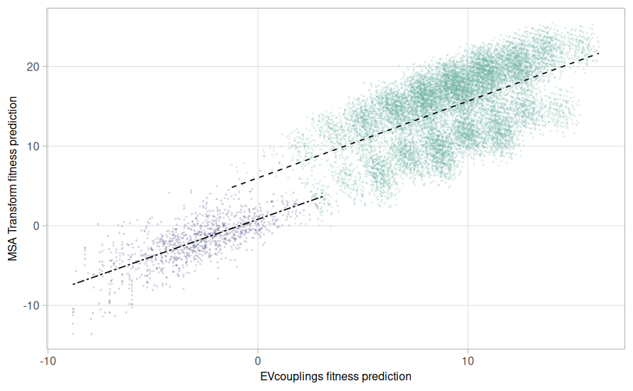

```r
ggsave("../EDA_output/png/scatter_MSA_Transform_EVcoup.png", scat, width=2, height=2, units="in")
```

### 4.5.3 Comparison “additive score” and normalized fitness

```r
red_fitness_noNA_additive <- subset(red_fitness_allConditions, !is.na(red_fitness_allConditions$additive_score))
# https://stackoverflow.com/questions/19699858/ggplot-adding-regression-line-equation-and-r2-with-facet
lm_eqn = function(df){
    m = lm(additive_score ~ norm, df);
    cor_form = cor.test(df$norm, df$additive_score, method = 'pearson')
    eq <- substitute("r ="~r, #italic(y) == a + b %.% italic(x)*" r2="~r2*" p= "~p*", Pearson's r="~r #Pearson's
         list(a = format(coef(m)[[1]], digits = 2),
              b = format(coef(m)[[2]], digits = 2),
             r2 = format(summary(m)$r.squared, digits = 3),
             r = format(cor_form$estimate[[1]], digits=2),
             p = format(cor_form$p.value[[1]], digits=2)))
    as.character(as.expression(eq));
}

eq <- ddply(red_fitness_noNA_additive,.(condition),lm_eqn)

p <- ggplot(data = red_fitness_noNA_additive, aes(x = norm, y = additive_score, color=category, alpha=category)) +
            geom_point(aes(size=category), shape=pointshape) +
            geom_smooth(method = "lm", se=FALSE, color="black", formula = y ~ x,linetype="dashed", linewidth=line_width_for_plots) + xlab("Normalized fitness") + ylab("Additive score") + theme_light() + theme(panel.grid.minor =element_blank(), legend.title = element_blank(), strip.background=element_rect(fill = NA, color = "white"), strip.text.x = element_text(size = 8, colour = "black", hjust = 0), axis.text=element_text(size=8), axis.title=element_text(size=8), legend.text=element_text(size=8)) + scale_size_manual(values=combi_sat_size) + scale_alpha_manual(values=combi_sat_alpha) + scale_color_manual(values=col_combi_sat)
scat = p + geom_text(data=eq,aes(x = -0.4, y = 1.8,label=V1), size=8, size.unit="pt", parse = TRUE, inherit.aes=FALSE) + facet_wrap(condition~.)
scat
ggsave("../EDA_output/pdf/scatter_additive_combi.pdf", scat, width=6.8, height=2, units="in")
```

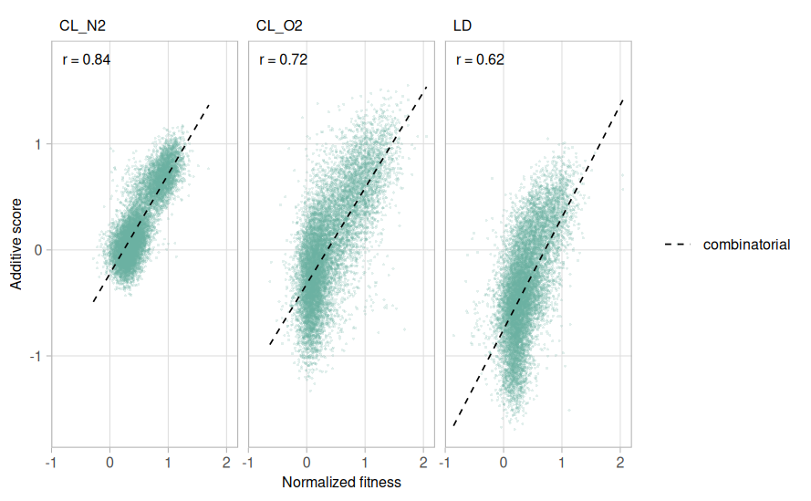

```r
ggsave("../EDA_output/png/scatter_additive_combi.png", scat, width=6.8, height=2, units="in")
```

```r
for(cat in c("combinatorial")){
  for(cond in c("CL_N2", "CL_O2", "LD")){
    print(cond)
    print(cat)
    subset_forLoop <- subset(red_fitness_noNA_additive, red_fitness_noNA_additive$category==cat & red_fitness_noNA_additive$condition==cond)
    print(nrow(subset_forLoop))
    correlation <- cor.test(subset_forLoop$norm, subset_forLoop$additive_score, method = 'pearson')
    print(correlation)
  }
}
```

```
[1] "CL_N2"
[1] "combinatorial"
[1] 10634

    Pearson's product-moment correlation

data:  subset_forLoop$norm and subset_forLoop$additive_score
t = 159.51, df = 10632, p-value < 2.2e-16
alternative hypothesis: true correlation is not equal to 0
95 percent confidence interval:
 0.8341119 0.8453185
sample estimates:
      cor
0.8398046

[1] "CL_O2"
[1] "combinatorial"
[1] 10634

    Pearson's product-moment correlation

data:  subset_forLoop$norm and subset_forLoop$additive_score
t = 106.13, df = 10632, p-value < 2.2e-16
alternative hypothesis: true correlation is not equal to 0
95 percent confidence interval:
 0.7078720 0.7263342
sample estimates:
      cor
0.7172289

[1] "LD"
[1] "combinatorial"
[1] 10634

    Pearson's product-moment correlation

data:  subset_forLoop$norm and subset_forLoop$additive_score
t = 80.732, df = 10632, p-value < 2.2e-16
alternative hypothesis: true correlation is not equal to 0
95 percent confidence interval:
 0.6045547 0.6281246
sample estimates:
      cor
0.6164777
```

### 4.5.4 Comparison DeepSequence, normalized fitness

```r
lm_eqn = function(df){
    m = lm(DeepSeq_predict ~ norm, df);
    cor_form = cor.test(df$norm, df$DeepSeq_predict, method = 'pearson')
    eq <- substitute("r ="~r*~cat2, #italic(y) == a + b %.% italic(x)*" r2="~r2*" p= "~p*", Pearson's r="~r #Pearson's
         list(a = format(coef(m)[[1]], digits = 2),
              b = format(coef(m)[[2]], digits = 2),
             r2 = format(summary(m)$r.squared, digits = 3),
             r = format(cor_form$estimate[[1]], digits=2),
             p = format(cor_form$p.value[[1]], digits=2),
             cat2 = unique(df$category2)))
    as.character(as.expression(eq));
}
red_fitness_allConditions_noNA_DeepSeq$category2 <- red_fitness_allConditions_noNA_DeepSeq$category
red_fitness_allConditions_noNA_DeepSeq[red_fitness_allConditions_noNA_DeepSeq$sgRNA_target=="WT",]$category2 <- "saturational"
eq <- ddply(red_fitness_allConditions_noNA_DeepSeq,.(condition, category2),lm_eqn)

red_fitness_noNA_DeepSeq_onlyComb_no4337 <- subset(red_fitness_allConditions_noNA_DeepSeq, red_fitness_allConditions_noNA_DeepSeq$category=="combinatorial" & !grepl("V337", red_fitness_allConditions_noNA_DeepSeq$sgRNA_target))

for(cat in c("combinatorial", "saturational")){
  for(cond in c("CL_N2", "CL_O2", "LD")){
    print(cond)
    print(cat)
    subset_forLoop <- subset(red_fitness_allConditions_noNA_DeepSeq, red_fitness_allConditions_noNA_DeepSeq$category==cat & red_fitness_allConditions_noNA_DeepSeq$condition==cond)
    print(nrow(subset_forLoop))
    correlation <- cor.test(subset_forLoop$norm, subset_forLoop$DeepSeq_predict, method = 'pearson')
    print(correlation)
  }
}
```

```
[1] "CL_N2"
[1] "combinatorial"
[1] 12708

    Pearson's product-moment correlation

data:  subset_forLoop$norm and subset_forLoop$DeepSeq_predict
t = -43.833, df = 12706, p-value < 2.2e-16
alternative hypothesis: true correlation is not equal to 0
95 percent confidence interval:
 -0.3774314 -0.3472243
sample estimates:
      cor
-0.362423

[1] "CL_O2"
[1] "combinatorial"
[1] 12708

    Pearson's product-moment correlation

data:  subset_forLoop$norm and subset_forLoop$DeepSeq_predict
t = -41.143, df = 12706, p-value < 2.2e-16
alternative hypothesis: true correlation is not equal to 0
95 percent confidence interval:
 -0.3581267 -0.3274403
sample estimates:
      cor
-0.342875

[1] "LD"
[1] "combinatorial"
[1] 12708

    Pearson's product-moment correlation

data:  subset_forLoop$norm and subset_forLoop$DeepSeq_predict
t = -47.885, df = 12706, p-value < 2.2e-16
alternative hypothesis: true correlation is not equal to 0
95 percent confidence interval:
```

[output cut: 34 more lines]

```

[1] "LD"
[1] "saturational"
[1] 1065

    Pearson's product-moment correlation

data:  subset_forLoop$norm and subset_forLoop$DeepSeq_predict
t = 15.628, df = 1063, p-value < 2.2e-16
alternative hypothesis: true correlation is not equal to 0
95 percent confidence interval:
 0.3820995 0.4798597
sample estimates:
      cor
0.4322488
```

```r
for(cat in c("combinatorial")){
  for(cond in c("CL_N2", "CL_O2", "LD")){
    print(cond)
    print(cat)
    subset_forLoop <- subset(red_fitness_noNA_DeepSeq_onlyComb_no4337, red_fitness_noNA_DeepSeq_onlyComb_no4337$category==cat & red_fitness_noNA_DeepSeq_onlyComb_no4337$condition==cond)
    print(nrow(subset_forLoop))
    correlation <- cor.test(subset_forLoop$norm, subset_forLoop$DeepSeq_predict, method = 'pearson')
    print(correlation)
  }
}
```

```
[1] "CL_N2"
[1] "combinatorial"
[1] 4169

    Pearson's product-moment correlation

data:  subset_forLoop$norm and subset_forLoop$DeepSeq_predict
t = -5.7451, df = 4167, p-value = 9.842e-09
alternative hypothesis: true correlation is not equal to 0
95 percent confidence interval:
 -0.11868603 -0.05844925
sample estimates:
        cor
-0.08864869

[1] "CL_O2"
[1] "combinatorial"
[1] 4169

    Pearson's product-moment correlation

data:  subset_forLoop$norm and subset_forLoop$DeepSeq_predict
t = -1.1996, df = 4167, p-value = 0.2304
alternative hypothesis: true correlation is not equal to 0
95 percent confidence interval:
 -0.04890950  0.01178303
sample estimates:
        cor
-0.01858035

[1] "LD"
[1] "combinatorial"
[1] 4169

    Pearson's product-moment correlation

data:  subset_forLoop$norm and subset_forLoop$DeepSeq_predict
t = -18.095, df = 4167, p-value < 2.2e-16
alternative hypothesis: true correlation is not equal to 0
95 percent confidence interval:
 -0.2978294 -0.2415353
sample estimates:
      cor
-0.269913
```

```r
scat <- ggplot(data = red_fitness_allConditions_noNA_DeepSeq, aes(x = norm, y = DeepSeq_predict, color=category, alpha=category, linetype=category2, shape=category)) +
            geom_point(aes(size=category)) + scale_size_manual(values=combi_sat_size) + scale_shape_manual(values=combi_sat_shape) +
            geom_smooth(method = "lm", se=FALSE, color="black", formula = y ~ x, linewidth=line_width_for_plots) + xlab("Normalized fitness") + ylab("DeepSequence prediction") + theme_light() + theme(panel.grid.minor =element_blank(), legend.title = element_blank(), strip.background=element_rect(fill = NA, color = "white"), strip.text.x = element_text(size = 8, colour = "black", hjust = 0), axis.text=element_text(size=8), axis.title=element_text(size=8), legend.text=element_text(size=8)) + scale_alpha_manual(values=combi_sat_alpha) + scale_color_manual(values=col_combi_sat) + scale_linetype_manual(values=c("combinatorial"="dashed", "saturational"="twodash")) + facet_wrap(condition~.)
scat = scat + geom_text(data=eq,aes(x = 0.5, y =-15, label=V1), vjust=c(0,1.2,0,1.2,0,1.2), parse = TRUE, inherit.aes=FALSE, size=8, size.unit="pt") + facet_wrap(condition~.)
scat
ggsave("../EDA_output/pdf/scatter_DeepSeq_norm.pdf", scat, width=6.8, height=2, units="in")
```

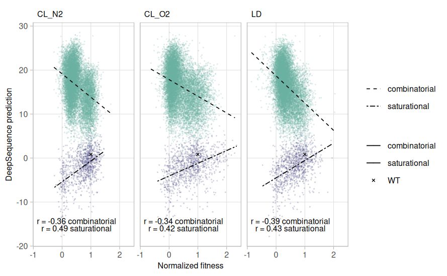

```r
ggsave("../EDA_output/png/scatter_DeepSeq_norm.png", scat, width=6.8, height=2, units="in")
```

```r
red_fitness_noNA_DeepSeq_onlyComb_no4337$category2 <- red_fitness_noNA_DeepSeq_onlyComb_no4337$category
red_fitness_noNA_DeepSeq_onlyComb_no4337[red_fitness_noNA_DeepSeq_onlyComb_no4337$sgRNA_target=="WT",]$category2 <- "saturational"
eq <- ddply(red_fitness_noNA_DeepSeq_onlyComb_no4337,.(condition, category2),lm_eqn)

scat <- ggplot(data = red_fitness_noNA_DeepSeq_onlyComb_no4337, aes(x = norm, y = DeepSeq_predict, color=category, alpha=category, linetype=category2, shape=category)) +
            geom_point(aes(size=category)) + scale_size_manual(values=combi_sat_size) + scale_shape_manual(values=combi_sat_shape) +
            geom_smooth(method = "lm", se=FALSE, color="black", formula = y ~ x, linewidth=line_width_for_plots) + xlab("Normalized fitness") + ylab("DeepSequence prediction") + theme_light() + theme(panel.grid.minor =element_blank(), legend.title = element_blank(), strip.background=element_rect(fill = NA, color = "white"), strip.text.x = element_text(size = 8, colour = "black", hjust = 0), axis.text=element_text(size=8), axis.title=element_text(size=8), legend.text=element_text(size=8)) + scale_alpha_manual(values=combi_sat_alpha) + scale_color_manual(values=col_combi_sat) + scale_linetype_manual(values=c("combinatorial"="dashed", "saturational"="twodash")) + facet_wrap(condition~.)
scat = scat + geom_text(data=eq,aes(x = 0.5, y =-15, label=V1), parse = TRUE, inherit.aes=FALSE, size=8, size.unit="pt") + facet_wrap(condition~.)
scat
ggsave("../EDA_output/pdf/scatter_DeepSeq_norm_noV323.pdf", scat, width=6.8, height=2, units="in")
```

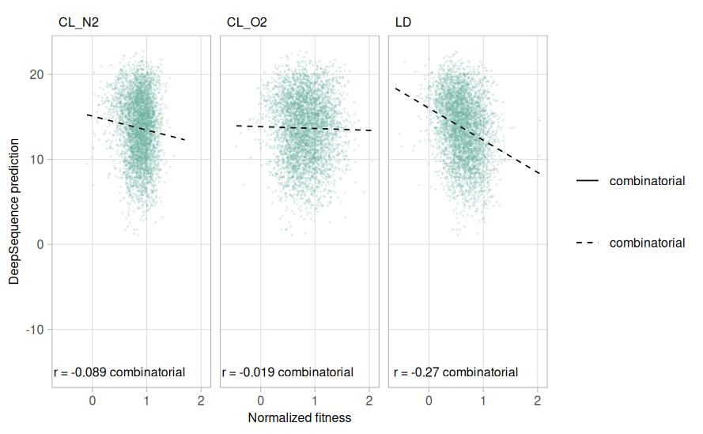

```r
ggsave("../EDA_output/png/scatter_DeepSeq_norm_noV323.png", scat, width=6.8, height=2, units="in")
```

### 4.5.5 Comparison EVmutation, normalized fitness

```r
red_fitness_noNA_EVcoup <- subset(red_fitness_allConditions, !is.na(red_fitness_allConditions$EVcoup_predict))

lm_eqn = function(df){
    m = lm(EVcoup_predict ~ norm, df);
    cor_form = cor.test(df$norm, df$EVcoup_predict, method = 'pearson')
    eq <- substitute("r ="~r*~cat2, #italic(y) == a + b %.% italic(x)*" r2="~r2*" p= "~p*", Pearson's r="~r #Pearson's
         list(a = format(coef(m)[[1]], digits = 2),
              b = format(coef(m)[[2]], digits = 2),
             r2 = format(summary(m)$r.squared, digits = 3),
             r = format(cor_form$estimate[[1]], digits=2),
             p = format(cor_form$p.value[[1]], digits=2),
             cat2 = unique(df$category2)))
    as.character(as.expression(eq));
}
red_fitness_noNA_EVcoup$category2 <- red_fitness_noNA_EVcoup$category
red_fitness_noNA_EVcoup[red_fitness_noNA_EVcoup$sgRNA_target=="WT",]$category2 <- "saturational"
eq <- ddply(red_fitness_noNA_EVcoup,.(condition, category2),lm_eqn)

red_fitness_noNA_EVcoup_no4337 <- subset(red_fitness_noNA_EVcoup, red_fitness_noNA_EVcoup$category=="combinatorial" & !grepl("V337", red_fitness_noNA_EVcoup$sgRNA_target))

for(cat in c("combinatorial", "saturational")){
  for(cond in c("CL_N2", "CL_O2", "LD")){
    print(cond)
    print(cat)
    subset_forLoop <- subset(red_fitness_noNA_EVcoup, red_fitness_noNA_EVcoup$category==cat & red_fitness_noNA_EVcoup$condition==cond)
    print(nrow(subset_forLoop))
    correlation <- cor.test(subset_forLoop$norm, subset_forLoop$EVcoup_predict, method = 'pearson')
    print(correlation)
  }
}
```

```
[1] "CL_N2"
[1] "combinatorial"
[1] 12708

    Pearson's product-moment correlation

data:  subset_forLoop$norm and subset_forLoop$EVcoup_predict
t = -35.025, df = 12706, p-value < 2.2e-16
alternative hypothesis: true correlation is not equal to 0
95 percent confidence interval:
 -0.3125049 -0.2807924
sample estimates:
       cor
-0.2967304

[1] "CL_O2"
[1] "combinatorial"
[1] 12708

    Pearson's product-moment correlation

data:  subset_forLoop$norm and subset_forLoop$EVcoup_predict
t = -36.382, df = 12706, p-value < 2.2e-16
alternative hypothesis: true correlation is not equal to 0
95 percent confidence interval:
 -0.3228183 -0.2913247
sample estimates:
       cor
-0.3071556

[1] "LD"
[1] "combinatorial"
[1] 12708

    Pearson's product-moment correlation

data:  subset_forLoop$norm and subset_forLoop$EVcoup_predict
t = -25.443, df = 12706, p-value < 2.2e-16
alternative hypothesis: true correlation is not equal to 0
95 percent confidence interval:
```

[output cut: 34 more lines]

```

[1] "LD"
[1] "saturational"
[1] 1065

    Pearson's product-moment correlation

data:  subset_forLoop$norm and subset_forLoop$EVcoup_predict
t = 15.969, df = 1063, p-value < 2.2e-16
alternative hypothesis: true correlation is not equal to 0
95 percent confidence interval:
 0.3901000 0.4870641
sample estimates:
      cor
0.4398631
```

```r
for(cat in c("combinatorial")){
  for(cond in c("CL_N2", "CL_O2", "LD")){
    print(cond)
    print(cat)
    subset_forLoop <- subset(red_fitness_noNA_EVcoup_no4337, red_fitness_noNA_EVcoup_no4337$category==cat & red_fitness_noNA_EVcoup_no4337$condition==cond)
    print(nrow(subset_forLoop))
    correlation <- cor.test(subset_forLoop$norm, subset_forLoop$EVcoup_predict, method = 'pearson')
    print(correlation)
  }
}
```

```
[1] "CL_N2"
[1] "combinatorial"
[1] 4169

    Pearson's product-moment correlation

data:  subset_forLoop$norm and subset_forLoop$EVcoup_predict
t = 16.564, df = 4167, p-value < 2.2e-16
alternative hypothesis: true correlation is not equal to 0
95 percent confidence interval:
 0.2198470 0.2768132
sample estimates:
     cor
0.248545

[1] "CL_O2"
[1] "combinatorial"
[1] 4169

    Pearson's product-moment correlation

data:  subset_forLoop$norm and subset_forLoop$EVcoup_predict
t = 16.128, df = 4167, p-value < 2.2e-16
alternative hypothesis: true correlation is not equal to 0
95 percent confidence interval:
 0.2136013 0.2707508
sample estimates:
      cor
0.2423863

[1] "LD"
[1] "combinatorial"
[1] 4169

    Pearson's product-moment correlation

data:  subset_forLoop$norm and subset_forLoop$EVcoup_predict
t = 12.545, df = 4167, p-value < 2.2e-16
alternative hypothesis: true correlation is not equal to 0
95 percent confidence interval:
 0.1613504 0.2198562
sample estimates:
      cor
0.1907727
```

```r
scat <- ggplot(data = red_fitness_noNA_EVcoup, aes(x = norm, y = EVcoup_predict, color=category, alpha=category, linetype=category2, shape=category)) +
            geom_point(aes(size=category)) + scale_size_manual(values=combi_sat_size) + scale_shape_manual(values=combi_sat_shape) +
            geom_smooth(method = "lm", se=FALSE, color="black", formula = y ~ x, linewidth=line_width_for_plots) + xlab("Normalized fitness") + ylab("EVmutation prediction") + theme_light() + theme(panel.grid.minor =element_blank(), legend.title = element_blank(), strip.background=element_rect(fill = NA, color = "white"), strip.text.x = element_text(size = 8, colour = "black", hjust = 0), axis.text=element_text(size=8), axis.title=element_text(size=8), legend.text=element_text(size=8)) + scale_alpha_manual(values=combi_sat_alpha) + scale_color_manual(values=col_combi_sat) + scale_linetype_manual(values=c("combinatorial"="dashed", "saturational"="twodash")) + facet_wrap(condition~.)
scat = scat + geom_text(data=eq,aes(x = 0.5, y =-10, label=V1), vjust=c(0,1.2,0,1.2,0,1.2), parse = TRUE, inherit.aes=FALSE, size=8, size.unit = "pt") + facet_wrap(condition~.)
scat
ggsave("../EDA_output/pdf/scatter_norm_all_EVcoup.pdf", scat, width=6.8, height=2, units="in")
```

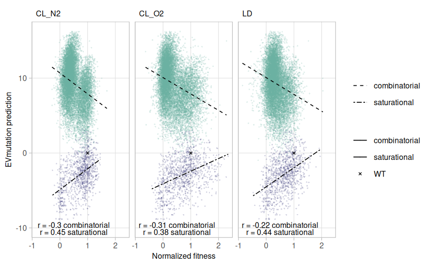

```r
ggsave("../EDA_output/png/scatter_norm_all_EVcoup.png", scat, width=6.8, height=2, units="in")
```

```r
red_fitness_noNA_EVcoup_no4337$category2 <- red_fitness_noNA_EVcoup_no4337$category
red_fitness_noNA_EVcoup_no4337[red_fitness_noNA_EVcoup_no4337$sgRNA_target=="WT",]$category2 <- "saturational"
eq <- ddply(red_fitness_noNA_EVcoup_no4337,.(condition, category2),lm_eqn)

scat <- ggplot(data = red_fitness_noNA_EVcoup_no4337, aes(x = norm, y = EVcoup_predict, color=category, alpha=category, linetype=category2, shape=category)) +
            geom_point(aes(size=category)) + scale_size_manual(values=combi_sat_size) + scale_shape_manual(values=combi_sat_shape) +
            geom_smooth(method = "lm", se=FALSE, color="black", formula = y ~ x, linewidth=line_width_for_plots) + xlab("Normalized fitness") + ylab("EVmutation prediction") + theme_light() + theme(panel.grid.minor =element_blank(), legend.title = element_blank(), strip.background=element_rect(fill = NA, color = "white"), strip.text.x = element_text(size = 8, colour = "black", hjust = 0), axis.text=element_text(size=8), axis.title=element_text(size=8), legend.text=element_text(size=8)) + scale_alpha_manual(values=combi_sat_alpha) + scale_color_manual(values=col_combi_sat) + scale_linetype_manual(values=c("combinatorial"="dashed", "saturational"="twodash")) + facet_wrap(condition~.)
scat = scat + geom_text(data=eq,aes(x = 0.5, y =-10, label=V1), parse = TRUE, inherit.aes=FALSE, size=8, size.unit = "pt") + facet_wrap(condition~.)
scat
ggsave("../EDA_output/pdf/scatter_norm_all_EVcoup_noV323.pdf", scat, width=6.8, height=2, units="in")
```

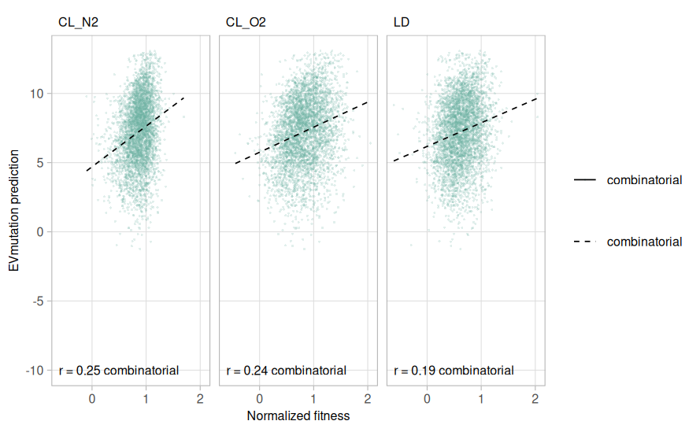

```r
ggsave("../EDA_output/png/scatter_norm_all_EVcoup_noV323.png", scat, width=6.8, height=2, units="in")
```

### 4.5.6 Comparison MSA transformer, normalized fitness

```r
lm_eqn = function(df){
    m = lm(MSA_Transform ~ norm, df);
    cor_form = cor.test(df$norm, df$MSA_Transform, method = 'pearson')
    eq <- substitute("r ="~r*~cat2, #italic(y) == a + b %.% italic(x)*" r2="~r2*" p= "~p*", Pearson's r="~r #Pearson's
         list(a = format(coef(m)[[1]], digits = 2),
              b = format(coef(m)[[2]], digits = 2),
             r2 = format(summary(m)$r.squared, digits = 3),
             r = format(cor_form$estimate[[1]], digits=2),
             p = format(cor_form$p.value[[1]], digits=2),
             cat2 = unique(df$category2)))
    as.character(as.expression(eq));
}
red_fitness_allConditions$category2 <- red_fitness_allConditions$category
red_fitness_allConditions[red_fitness_allConditions$sgRNA_target=="WT",]$category2 <- "saturational"
eq <- ddply(red_fitness_allConditions,.(condition, category2),lm_eqn)

scat <- ggplot(data = red_fitness_allConditions, aes(x = norm, y = MSA_Transform, color=category, alpha=category, linetype=category2, shape=category)) +
            geom_point(aes(size=category)) + scale_size_manual(values=combi_sat_size) + scale_shape_manual(values=combi_sat_shape) +
            geom_smooth(method = "lm", se=FALSE, color="black", formula = y ~ x, linewidth=line_width_for_plots) + xlab("Normalized fitness") + ylab("MSATransformer (ensemble) prediction") + theme_light() + theme(panel.grid.minor =element_blank(), legend.title = element_blank(), strip.background=element_rect(fill = NA, color = "white"), strip.text.x = element_text(size = 8, colour = "black", hjust = 0), axis.text=element_text(size=8), axis.title=element_text(size=8), legend.text=element_text(size=8)) + scale_alpha_manual(values=combi_sat_alpha) + scale_color_manual(values=col_combi_sat) + scale_linetype_manual(values=c("combinatorial"="dashed", "saturational"="twodash")) + facet_wrap(condition~.)
scat = scat + geom_text(data=eq,aes(x = 0.5, y =-10, label=V1), size=8, size.unit="pt", vjust=c(0,1.2,0,1.2,0,1.2), parse = TRUE, inherit.aes=FALSE) + facet_wrap(condition~.)
scat
ggsave("../EDA_output/pdf/scatter_MSA_Transform_norm.pdf", scat, width=6.8, height=2, units="in")
```

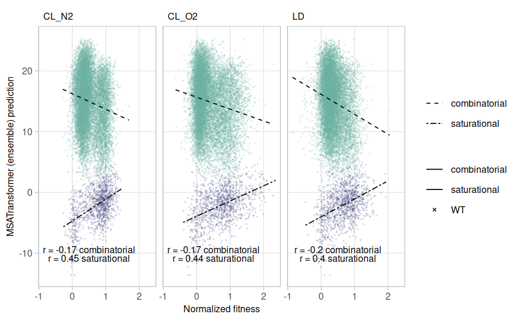

```r
ggsave("../EDA_output/png/scatter_MSA_Transform_norm.png", scat, width=6.8, height=2, units="in")
```

```r
red_fitness_allConditions_no4337 <- subset(red_fitness_allConditions, red_fitness_allConditions$category=="combinatorial" & !grepl("V337", red_fitness_allConditions$sgRNA_target))
red_fitness_allConditions_no4337$category2 <- red_fitness_allConditions_no4337$category
red_fitness_allConditions_no4337[red_fitness_allConditions_no4337$sgRNA_target=="WT",]$category2 <- "saturational"
eq <- ddply(red_fitness_allConditions_no4337,.(condition, category2),lm_eqn)

scat <- ggplot(data = red_fitness_allConditions_no4337, aes(x = norm, y = MSA_Transform, color=category, alpha=category, linetype=category2, shape=category)) +
            geom_point(aes(size=category)) + scale_size_manual(values=combi_sat_size) + scale_shape_manual(values=combi_sat_shape) +
            geom_smooth(method = "lm", se=FALSE, color="black", formula = y ~ x, linewidth=line_width_for_plots) + xlab("Normalized fitness") + ylab("MSATransformer (ensemble) prediction") + theme_light() + theme(panel.grid.minor =element_blank(), legend.title = element_blank(), strip.background=element_rect(fill = NA, color = "white"), strip.text.x = element_text(size = 8, colour = "black", hjust = 0), axis.text=element_text(size=8), axis.title=element_text(size=8), legend.text=element_text(size=8)) + scale_alpha_manual(values=combi_sat_alpha) + scale_color_manual(values=col_combi_sat) + scale_linetype_manual(values=c("combinatorial"="dashed", "saturational"="twodash")) + facet_wrap(condition~.)
scat = scat + geom_text(data=eq,aes(x = 0.5, y =-10, label=V1), size=8, size.unit="pt", parse = TRUE, inherit.aes=FALSE) + facet_wrap(condition~.)
scat
ggsave("../EDA_output/pdf/scatter_MSA_Transform_norm_noV323.pdf", scat, width=6.8, height=2, units="in")
```

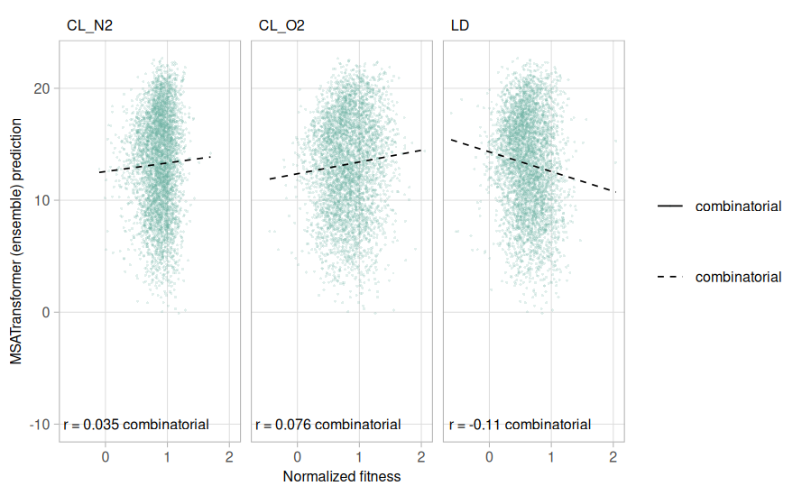

```r
ggsave("../EDA_output/png/scatter_MSA_Transform_norm_noV323.png", scat, width=6.8, height=2, units="in")
```

```r
for(cat in c("combinatorial", "saturational")){
  for(cond in c("CL_N2", "CL_O2", "LD")){
    print(cond)
    print(cat)
    subset_forLoop <- subset(red_fitness_allConditions, red_fitness_allConditions$category==cat & red_fitness_allConditions$condition==cond)
    print(nrow(subset_forLoop))
    correlation <- cor.test(subset_forLoop$norm, subset_forLoop$MSA_Transform, method = 'pearson')
    print(correlation)
  }
}
```

```
[1] "CL_N2"
[1] "combinatorial"
[1] 12708

    Pearson's product-moment correlation

data:  subset_forLoop$norm and subset_forLoop$MSA_Transform
t = -19.143, df = 12706, p-value < 2.2e-16
alternative hypothesis: true correlation is not equal to 0
95 percent confidence interval:
 -0.1842829 -0.1504840
sample estimates:
       cor
-0.1674327

[1] "CL_O2"
[1] "combinatorial"
[1] 12708

    Pearson's product-moment correlation

data:  subset_forLoop$norm and subset_forLoop$MSA_Transform
t = -19.217, df = 12706, p-value < 2.2e-16
alternative hypothesis: true correlation is not equal to 0
95 percent confidence interval:
 -0.1849037 -0.1511121
sample estimates:
       cor
-0.1680572

[1] "LD"
[1] "combinatorial"
[1] 12708

    Pearson's product-moment correlation

data:  subset_forLoop$norm and subset_forLoop$MSA_Transform
t = -22.703, df = 12706, p-value < 2.2e-16
alternative hypothesis: true correlation is not equal to 0
95 percent confidence interval:
```

[output cut: 34 more lines]

```

[1] "LD"
[1] "saturational"
[1] 1223

    Pearson's product-moment correlation

data:  subset_forLoop$norm and subset_forLoop$MSA_Transform
t = 15.398, df = 1221, p-value < 2.2e-16
alternative hypothesis: true correlation is not equal to 0
95 percent confidence interval:
 0.3552213 0.4491489
sample estimates:
      cor
0.4032467
```

```r
for(cat in c("combinatorial")){
  for(cond in c("CL_N2", "CL_O2", "LD")){
    print(cond)
    print(cat)
    subset_forLoop <- subset(red_fitness_allConditions_no4337, red_fitness_allConditions_no4337$category==cat & red_fitness_allConditions_no4337$condition==cond)
    print(nrow(subset_forLoop))
    correlation <- cor.test(subset_forLoop$norm, subset_forLoop$MSA_Transform, method = 'pearson')
    print(correlation)
  }
}
```

```
[1] "CL_N2"
[1] "combinatorial"
[1] 4169

    Pearson's product-moment correlation

data:  subset_forLoop$norm and subset_forLoop$MSA_Transform
t = 2.2835, df = 4167, p-value = 0.02245
alternative hypothesis: true correlation is not equal to 0
95 percent confidence interval:
 0.005000401 0.065638056
sample estimates:
       cor
0.03535177

[1] "CL_O2"
[1] "combinatorial"
[1] 4169

    Pearson's product-moment correlation

data:  subset_forLoop$norm and subset_forLoop$MSA_Transform
t = 4.9515, df = 4167, p-value = 7.656e-07
alternative hypothesis: true correlation is not equal to 0
95 percent confidence interval:
 0.04623111 0.10658976
sample estimates:
      cor
0.0764805

[1] "LD"
[1] "combinatorial"
[1] 4169

    Pearson's product-moment correlation

data:  subset_forLoop$norm and subset_forLoop$MSA_Transform
t = -6.9517, df = 4167, p-value = 4.171e-12
alternative hypothesis: true correlation is not equal to 0
95 percent confidence interval:
 -0.13698331 -0.07696526
sample estimates:
       cor
-0.1070718
```

### 4.5.7 Comparison ProteinNPT, normalized fitness

```r
df_proteinNPT <- subset(red_fitness, !is.na(red_fitness$proteinNPT_predict))

lm_eqn = function(df){
    m = lm(proteinNPT_predict ~ norm, df);
    cor_form = cor.test(df$norm, df$proteinNPT_predict, method = 'pearson')
    eq <- substitute("r ="~r*~cat2, #italic(y) == a + b %.% italic(x)*" r2="~r2*" p= "~p*", Pearson's r="~r #Pearson's
         list(a = format(coef(m)[[1]], digits = 2),
              b = format(coef(m)[[2]], digits = 2),
             r2 = format(summary(m)$r.squared, digits = 3),
             r = format(cor_form$estimate[[1]], digits=2),
             p = format(cor_form$p.value[[1]], digits=2),
             cat2 = unique(df$category2)))
    as.character(as.expression(eq));
}
df_proteinNPT$category2 <- df_proteinNPT$category
df_proteinNPT[df_proteinNPT$sgRNA_target=="WT",]$category2 <- "saturational"
eq <- ddply(df_proteinNPT,.(condition, category2),lm_eqn)

scat <- ggplot(data = df_proteinNPT, aes(x = norm, y = proteinNPT_predict, color=category, alpha=category, linetype=category2, shape=category)) +
            geom_point(aes(size=category)) + scale_size_manual(values=combi_sat_size) + scale_shape_manual(values=combi_sat_shape) +
            geom_smooth(method = "lm", se=FALSE, color="black", formula = y ~ x, linewidth=line_width_for_plots) + xlab("Normalized fitness") + ylab("ProteinNPT prediction") + theme_light() + theme(panel.grid.minor =element_blank(), legend.title = element_blank(), strip.background=element_rect(fill = NA, color = "white"), strip.text.x = element_text(size = 8, colour = "black", hjust = 0), axis.text=element_text(size=8), axis.title=element_text(size=8), legend.text=element_text(size=8)) + scale_alpha_manual(values=combi_sat_alpha) + scale_color_manual(values=col_combi_sat) + scale_linetype_manual(values=c("combinatorial"="dashed", "saturational"="twodash")) + facet_wrap(condition~.)
scat = scat + geom_text(data=eq,aes(x = 0.5, y =-2, label=V1), size=8, size.unit="pt", parse = TRUE, inherit.aes=FALSE) + facet_wrap(condition~.)
scat
ggsave("../EDA_output/pdf/scatter_proteinNPT_norm.pdf", scat, width=6.8, height=2, units="in")
```

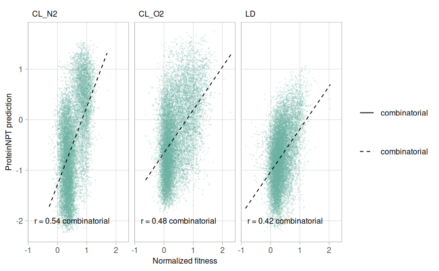

```r
ggsave("../EDA_output/png/scatter_proteinNPT_norm.png", scat, width=6.8, height=2, units="in")
```

```r
for(cat in c("combinatorial")){
  for(cond in c("CL_N2", "CL_O2", "LD")){
    print(cond)
    print(cat)
    subset_forLoop <- subset(df_proteinNPT, df_proteinNPT$category==cat & df_proteinNPT$condition==cond)
    print(nrow(subset_forLoop))
    correlation <- cor.test(subset_forLoop$norm, subset_forLoop$proteinNPT_predict, method = 'pearson')
    print(correlation)
  }
}
```

```
[1] "CL_N2"
[1] "combinatorial"
[1] 12708

    Pearson's product-moment correlation

data:  subset_forLoop$norm and subset_forLoop$proteinNPT_predict
t = 72.114, df = 12706, p-value < 2.2e-16
alternative hypothesis: true correlation is not equal to 0
95 percent confidence interval:
 0.5264539 0.5511305
sample estimates:
      cor
0.5389078

[1] "CL_O2"
[1] "combinatorial"
[1] 12708

    Pearson's product-moment correlation

data:  subset_forLoop$norm and subset_forLoop$proteinNPT_predict
t = 61.495, df = 12706, p-value < 2.2e-16
alternative hypothesis: true correlation is not equal to 0
95 percent confidence interval:
 0.4654081 0.4922076
sample estimates:
      cor
0.4789194

[1] "LD"
[1] "combinatorial"
[1] 12708

    Pearson's product-moment correlation

data:  subset_forLoop$norm and subset_forLoop$proteinNPT_predict
t = 51.475, df = 12706, p-value < 2.2e-16
alternative hypothesis: true correlation is not equal to 0
95 percent confidence interval:
 0.4009029 0.4296776
sample estimates:
      cor
0.4153941
```

```r
df_proteinNPT_noV323 <- subset(df_proteinNPT, !grepl("V337", df_proteinNPT$sgRNA_target))

df_proteinNPT_noV323$category2 <- df_proteinNPT_noV323$category
df_proteinNPT_noV323[df_proteinNPT_noV323$sgRNA_target=="WT",]$category2 <- "saturational"
eq <- ddply(df_proteinNPT_noV323,.(condition, category2),lm_eqn)

scat <- ggplot(data = df_proteinNPT_noV323, aes(x = norm, y = proteinNPT_predict, color=category, alpha=category, linetype=category2, shape=category)) +
            geom_point(aes(size=category)) + scale_size_manual(values=combi_sat_size) + scale_shape_manual(values=combi_sat_shape) +
            geom_smooth(method = "lm", se=FALSE, color="black", formula = y ~ x, linewidth=line_width_for_plots) + xlab("Normalized fitness") + ylab("ProteinNPT prediction") + theme_light() + theme(panel.grid.minor =element_blank(), legend.title = element_blank(), strip.background=element_rect(fill = NA, color = "white"), strip.text.x = element_text(size = 8, colour = "black", hjust = 0), axis.text=element_text(size=8), axis.title=element_text(size=8), legend.text=element_text(size=8)) + scale_alpha_manual(values=combi_sat_alpha) + scale_color_manual(values=col_combi_sat) + scale_linetype_manual(values=c("combinatorial"="dashed", "saturational"="twodash")) + facet_wrap(condition~.)
scat = scat + geom_text(data=eq,aes(x = 0.5, y =-2, label=V1), size=8, size.unit="pt", parse = TRUE, inherit.aes=FALSE) + facet_wrap(condition~.)
scat
ggsave("../EDA_output/pdf/scatter_proteinNPT_norm_noV323.pdf", scat, width=6.8, height=2, units="in")
```

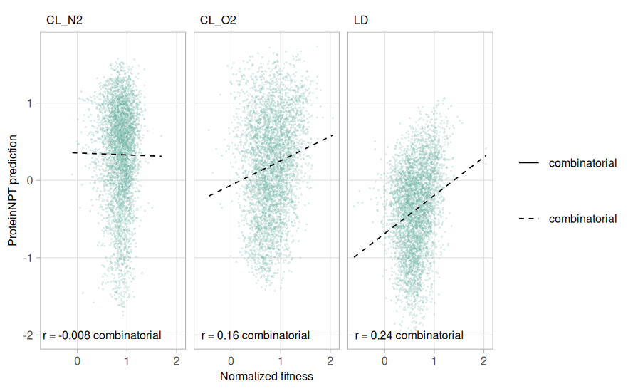

```r
ggsave("../EDA_output/png/scatter_proteinNPT_norm_noV323.png", scat, width=6.8, height=2, units="in")
```

```r
for(cat in c("combinatorial")){
  for(cond in c("CL_N2", "CL_O2", "LD")){
    print(cond)
    print(cat)
    subset_forLoop <- subset(df_proteinNPT_noV323, df_proteinNPT_noV323$category==cat & df_proteinNPT_noV323$condition==cond)
    print(nrow(subset_forLoop))
    correlation <- cor.test(subset_forLoop$norm, subset_forLoop$proteinNPT_predict, method = 'pearson')
    print(correlation)
  }
}
```

```
[1] "CL_N2"
[1] "combinatorial"
[1] 4169

    Pearson's product-moment correlation

data:  subset_forLoop$norm and subset_forLoop$proteinNPT_predict
t = -0.51632, df = 4167, p-value = 0.6057
alternative hypothesis: true correlation is not equal to 0
95 percent confidence interval:
 -0.03834568  0.02236390
sample estimates:
         cor
-0.007998256

[1] "CL_O2"
[1] "combinatorial"
[1] 4169

    Pearson's product-moment correlation

data:  subset_forLoop$norm and subset_forLoop$proteinNPT_predict
t = 10.249, df = 4167, p-value < 2.2e-16
alternative hypothesis: true correlation is not equal to 0
95 percent confidence interval:
 0.1270613 0.1862831
sample estimates:
      cor
0.1568131

[1] "LD"
[1] "combinatorial"
[1] 4169

    Pearson's product-moment correlation

data:  subset_forLoop$norm and subset_forLoop$proteinNPT_predict
t = 15.979, df = 4167, p-value < 2.2e-16
alternative hypothesis: true correlation is not equal to 0
95 percent confidence interval:
 0.2114725 0.2686836
sample estimates:
      cor
0.2402867
```

```r
lm_eqn = function(df){
    m = lm(proteinNPT_predict ~ norm, df);
    cor_form = cor.test(df$norm, df$proteinNPT_predict, method = 'spearman')
    eq <- substitute("rho ="~r*~cat2, #italic(y) == a + b %.% italic(x)*" r2="~r2*" p= "~p*", Pearson's r="~r #Pearson's
         list(a = format(coef(m)[[1]], digits = 2),
              b = format(coef(m)[[2]], digits = 2),
             r2 = format(summary(m)$r.squared, digits = 3),
             r = format(cor_form$estimate[[1]], digits=2),
             p = format(cor_form$p.value[[1]], digits=2),
             cat2 = unique(df$category2)))
    as.character(as.expression(eq));
}
df_proteinNPT$category2 <- df_proteinNPT$category
df_proteinNPT[df_proteinNPT$sgRNA_target=="WT",]$category2 <- "saturational"
eq <- ddply(df_proteinNPT,.(condition, category2),lm_eqn)

scat <- ggplot(data = df_proteinNPT, aes(x = norm, y = proteinNPT_predict, color=category, alpha=category, linetype=category2, shape=category)) +
            geom_point(aes(size=category)) + scale_size_manual(values=combi_sat_size) + scale_shape_manual(values=combi_sat_shape) +
            geom_smooth(method = "lm", se=FALSE, color="black", formula = y ~ x, linewidth=line_width_for_plots) + xlab("Normalized fitness") + ylab("ProteinNPT prediction") + theme_light() + theme(panel.grid.minor =element_blank(), legend.title = element_blank(), strip.background=element_rect(fill = NA, color = "white"), strip.text.x = element_text(size = 8, colour = "black", hjust = 0), axis.text=element_text(size=8), axis.title=element_text(size=8), legend.text=element_text(size=8)) + scale_alpha_manual(values=combi_sat_alpha) + scale_color_manual(values=col_combi_sat) + scale_linetype_manual(values=c("combinatorial"="dashed", "saturational"="twodash")) + facet_wrap(condition~.)
scat = scat + geom_text(data=eq,aes(x = 0.5, y =-2, label=V1), size=8, size.unit="pt", parse = TRUE, inherit.aes=FALSE) + facet_wrap(condition~.)
scat
ggsave("../EDA_output/pdf/scatter_proteinNPT_norm_spearman.pdf", scat, width=6.8, height=2, units="in")
```

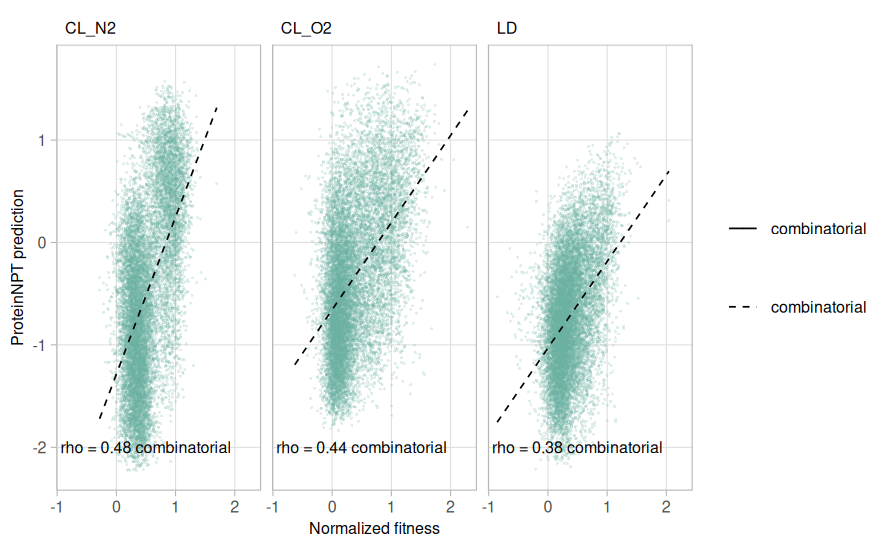

```r
ggsave("../EDA_output/png/scatter_proteinNPT_norm_spearman.png", scat, width=6.8, height=2, units="in")
```

### 4.5.8 Comparison MSA transformer, ProteinNPT

```r
scat <- ggplot(df_proteinNPT, aes(x=proteinNPT_predict, y=MSA_Transform, color=category, alpha=category, linetype=category, shape=category, size=category)) + geom_point() + scale_shape_manual(values=combi_sat_shape) + scale_size_manual(values=combi_sat_size) + geom_smooth(method = "lm", se=FALSE, color="black", formula = y ~ x, linewidth=line_width_for_plots) + scale_linetype_manual(values=c("combinatorial"="dashed", "saturational"="twodash")) + theme_light() + xlab("ProteinNPT fitness prediction") + ylab("MSA Transform fitness prediction") + scale_alpha_manual(values=combi_sat_alpha) + scale_color_manual(values=col_combi_sat) + theme(panel.grid.minor =element_blank(), legend.position = "none", strip.background=element_rect(fill = NA, color = "white"), strip.text.x = element_text(size = 8, colour = "black", hjust = 0), axis.text=element_text(size=8), axis.title=element_text(size=8), legend.text=element_text(size=8), legend.title = element_blank()) + facet_wrap(condition~.)
scat
ggsave("../EDA_output/pdf/scatter_MSA_Transform_proteinNPT.pdf", scat, width=2, height=2, units="in")
```

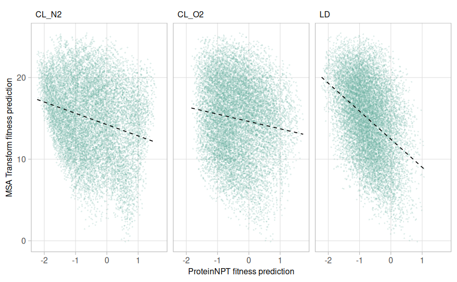

```r
ggsave("../EDA_output/png/scatter_MSA_Transform_proteinNPT.png", scat, width=2, height=2, units="in")
```

```r
for(cat in c("combinatorial")){
  for(cond in c("CL_N2", "CL_O2", "LD")){
    print(cond)
    print(cat)
    subset_forLoop <- subset(df_proteinNPT, df_proteinNPT$category==cat & df_proteinNPT$condition==cond)
    print(nrow(subset_forLoop))
    correlation <- cor.test(subset_forLoop$proteinNPT_predict, subset_forLoop$MSA_Transform, method = 'pearson')
    print(correlation)
  }
}
```

```
[1] "CL_N2"
[1] "combinatorial"
[1] 12708

    Pearson's product-moment correlation

data:  subset_forLoop$proteinNPT_predict and subset_forLoop$MSA_Transform
t = -29.953, df = 12706, p-value < 2.2e-16
alternative hypothesis: true correlation is not equal to 0
95 percent confidence interval:
 -0.2729857 -0.2405052
sample estimates:
      cor
-0.256818

[1] "CL_O2"
[1] "combinatorial"
[1] 12708

    Pearson's product-moment correlation

data:  subset_forLoop$proteinNPT_predict and subset_forLoop$MSA_Transform
t = -15.63, df = 12706, p-value < 2.2e-16
alternative hypothesis: true correlation is not equal to 0
95 percent confidence interval:
 -0.1543642 -0.1202466
sample estimates:
       cor
-0.1373462

[1] "LD"
[1] "combinatorial"
[1] 12708

    Pearson's product-moment correlation

data:  subset_forLoop$proteinNPT_predict and subset_forLoop$MSA_Transform
t = -52.139, df = 12706, p-value < 2.2e-16
alternative hypothesis: true correlation is not equal to 0
95 percent confidence interval:
 -0.4340313 -0.4053850
sample estimates:
       cor
-0.4198127
```

### 4.5.9 Comparison additive score, ProteinNPT

```r
lm_eqn = function(df){
    m = lm(additive_score ~ proteinNPT_predict, df);
    cor_form = cor.test(df$proteinNPT_predict, df$additive_score, method = 'pearson')
    eq <- substitute("rho ="~r*~cat2, #italic(y) == a + b %.% italic(x)*" r2="~r2*" p= "~p*", Pearson's r="~r #Pearson's
         list(a = format(coef(m)[[1]], digits = 2),
              b = format(coef(m)[[2]], digits = 2),
             r2 = format(summary(m)$r.squared, digits = 3),
             r = format(cor_form$estimate[[1]], digits=2),
             p = format(cor_form$p.value[[1]], digits=2),
             cat2 = unique(df$category2)))
    as.character(as.expression(eq));
}
df_proteinNPT$category2 <- df_proteinNPT$category
df_proteinNPT[df_proteinNPT$sgRNA_target=="WT",]$category2 <- "saturational"
eq <- ddply(df_proteinNPT,.(condition, category2),lm_eqn)

scat <- ggplot(df_proteinNPT, aes(x=proteinNPT_predict, y=additive_score, color=category, alpha=category, linetype=category, shape=category, size=category)) + geom_point() + scale_shape_manual(values=combi_sat_shape) + scale_size_manual(values=combi_sat_size) + geom_smooth(method = "lm", se=FALSE, color="black", formula = y ~ x, linewidth=line_width_for_plots) + scale_linetype_manual(values=c("combinatorial"="dashed", "saturational"="twodash")) + theme_light() + xlab("ProteinNPT fitness prediction") + ylab("Additive score fitness prediction") + scale_alpha_manual(values=combi_sat_alpha) + scale_color_manual(values=col_combi_sat) + theme(panel.grid.minor =element_blank(), legend.position = "none", strip.background=element_rect(fill = NA, color = "white"), strip.text.x = element_text(size = 8, colour = "black", hjust = 0), axis.text=element_text(size=8), axis.title=element_text(size=8), legend.text=element_text(size=8), legend.title = element_blank()) + facet_wrap(condition~.)
scat = scat + geom_text(data=eq,aes(x = 0.5, y =-2, label=V1), size=8, size.unit="pt", parse = TRUE, inherit.aes=FALSE) + facet_wrap(condition~.)
scat
ggsave("../EDA_output/pdf/scatter_additiveScore_proteinNPT.pdf", scat, width=2, height=2, units="in")
```

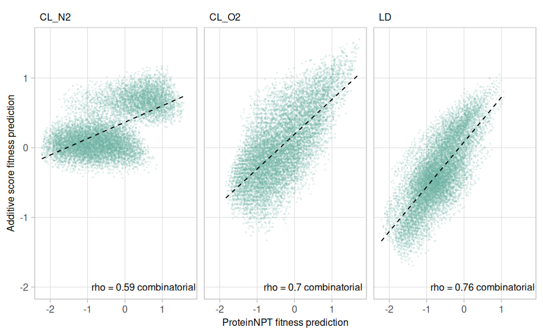

```r
ggsave("../EDA_output/png/scatter_additiveScore_proteinNPT.png", scat, width=2, height=2, units="in")
```

```r
for(cat in c("combinatorial")){
  for(cond in c("CL_N2", "CL_O2", "LD")){
    print(cond)
    print(cat)
    subset_forLoop <- subset(df_proteinNPT, df_proteinNPT$category==cat & df_proteinNPT$condition==cond)
    print(nrow(subset_forLoop))
    correlation <- cor.test(subset_forLoop$proteinNPT_predict, subset_forLoop$additive_score, method = 'pearson')
    print(correlation)
  }
}
```

```
[1] "CL_N2"
[1] "combinatorial"
[1] 12708

    Pearson's product-moment correlation

data:  subset_forLoop$proteinNPT_predict and subset_forLoop$additive_score
t = 75.897, df = 10632, p-value < 2.2e-16
alternative hypothesis: true correlation is not equal to 0
95 percent confidence interval:
 0.5803279 0.6049863
sample estimates:
     cor
0.592796

[1] "CL_O2"
[1] "combinatorial"
[1] 12708

    Pearson's product-moment correlation

data:  subset_forLoop$proteinNPT_predict and subset_forLoop$additive_score
t = 100.1, df = 10632, p-value < 2.2e-16
alternative hypothesis: true correlation is not equal to 0
95 percent confidence interval:
 0.6866408 0.7062139
sample estimates:
      cor
0.6965569

[1] "LD"
[1] "combinatorial"
[1] 12708

    Pearson's product-moment correlation

data:  subset_forLoop$proteinNPT_predict and subset_forLoop$additive_score
t = 120.09, df = 10632, p-value < 2.2e-16
alternative hypothesis: true correlation is not equal to 0
95 percent confidence interval:
 0.7505233 0.7666582
sample estimates:
      cor
0.7587071
```

### 4.5.10 Comparison MoCHI, normalized fitness

```r
lm_eqn = function(df){
    m = lm(MoCHI_mean ~ norm, df);
    cor_form = cor.test(df$norm, df$MoCHI_mean, method = 'pearson')
    eq <- substitute("r ="~r*~cat2, #italic(y) == a + b %.% italic(x)*" r2="~r2*" p= "~p*", Pearson's r="~r #Pearson's
         list(a = format(coef(m)[[1]], digits = 2),
              b = format(coef(m)[[2]], digits = 2),
             r2 = format(summary(m)$r.squared, digits = 3),
             r = format(cor_form$estimate[[1]], digits=2),
             p = format(cor_form$p.value[[1]], digits=2),
             cat2 = unique(df$category2)))
    as.character(as.expression(eq));
}
red_fitness$category2 <- red_fitness$category
red_fitness[red_fitness$sgRNA_target=="WT",]$category2 <- "saturational"
eq <- ddply(red_fitness,.(condition, category2),lm_eqn)

scat <- ggplot(data = red_fitness, aes(x = norm, y = MoCHI_mean, color=category, alpha=category, linetype=category2, shape=category)) +
            geom_point(aes(size=category)) + scale_size_manual(values=combi_sat_size) + scale_shape_manual(values=combi_sat_shape) +
            geom_smooth(method = "lm", se=FALSE, color="black", formula = y ~ x, linewidth=line_width_for_plots) + xlab("Normalized fitness") + ylab("MoCHI prediction") + theme_light() + theme(panel.grid.minor =element_blank(), legend.title = element_blank(), strip.background=element_rect(fill = NA, color = "white"), strip.text.x = element_text(size = 8, colour = "black", hjust = 0), axis.text=element_text(size=8), axis.title=element_text(size=8), legend.text=element_text(size=8)) + scale_alpha_manual(values=combi_sat_alpha) + scale_color_manual(values=col_combi_sat) + scale_linetype_manual(values=c("combinatorial"="dashed", "saturational"="twodash")) + facet_wrap(condition~.)
scat = scat + geom_text(data=eq,aes(x = 0.5, y =1.4, label=V1), vjust=c(0,1.2,0,1.2,0,1.2), parse = TRUE, inherit.aes=FALSE, size=8, size.unit="pt") + facet_wrap(condition~.)
scat
ggsave("../EDA_output/pdf/scatter_MoCHI_norm.pdf", scat, width=6.8, height=2, units="in")
```

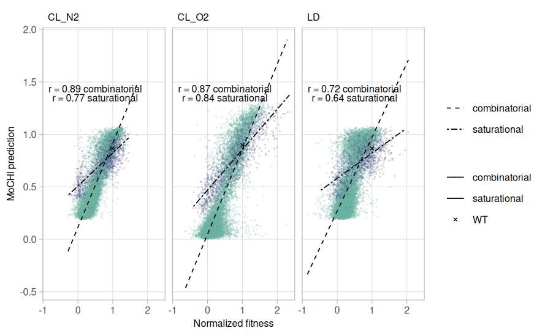

```r
ggsave("../EDA_output/png/scatter_MoCHI_norm.png", scat, width=6.8, height=2, units="in")
```

```r
for(cat in c("saturational","combinatorial")){
  for(cond in c("CL_N2", "CL_O2", "LD")){
    print(cond)
    print(cat)
    subset_forLoop <- subset(red_fitness, red_fitness$category==cat & red_fitness$condition==cond)
    print(nrow(subset_forLoop))
    correlation <- cor.test(subset_forLoop$norm, subset_forLoop$MoCHI_mean, method = 'pearson')
    print(correlation)
  }
}
```

```
[1] "CL_N2"
[1] "saturational"
[1] 1223

    Pearson's product-moment correlation

data:  subset_forLoop$norm and subset_forLoop$MoCHI_mean
t = 42.558, df = 1221, p-value < 2.2e-16
alternative hypothesis: true correlation is not equal to 0
95 percent confidence interval:
 0.7492682 0.7944977
sample estimates:
      cor
0.7728627

[1] "CL_O2"
[1] "saturational"
[1] 1223

    Pearson's product-moment correlation

data:  subset_forLoop$norm and subset_forLoop$MoCHI_mean
t = 54.839, df = 1221, p-value < 2.2e-16
alternative hypothesis: true correlation is not equal to 0
95 percent confidence interval:
 0.8263546 0.8588009
sample estimates:
      cor
0.8433447

[1] "LD"
[1] "saturational"
[1] 1223

    Pearson's product-moment correlation

data:  subset_forLoop$norm and subset_forLoop$MoCHI_mean
t = 28.956, df = 1221, p-value < 2.2e-16
alternative hypothesis: true correlation is not equal to 0
95 percent confidence interval:
```

[output cut: 34 more lines]

```

[1] "LD"
[1] "combinatorial"
[1] 12708

    Pearson's product-moment correlation

data:  subset_forLoop$norm and subset_forLoop$MoCHI_mean
t = 117.84, df = 12706, p-value < 2.2e-16
alternative hypothesis: true correlation is not equal to 0
95 percent confidence interval:
 0.7142176 0.7308351
sample estimates:
      cor
0.7226308
```

### 4.5.11 MoCHI to additive score

```r
red_fitness_noSat <- subset(red_fitness, red_fitness$category=="combinatorial")
lm_eqn = function(df){
    m = lm(MoCHI_mean ~ additive_score, df);
    cor_form = cor.test(df$additive_score, df$MoCHI_mean, method = 'pearson')
    eq <- substitute("r ="~r*~cat2, #italic(y) == a + b %.% italic(x)*" r2="~r2*" p= "~p*", Pearson's r="~r #Pearson's
         list(a = format(coef(m)[[1]], digits = 2),
              b = format(coef(m)[[2]], digits = 2),
             r2 = format(summary(m)$r.squared, digits = 3),
             r = format(cor_form$estimate[[1]], digits=2),
             p = format(cor_form$p.value[[1]], digits=2),
             cat2 = unique(df$category2)))
    as.character(as.expression(eq));
}
red_fitness_noSat$category2 <- red_fitness_noSat$category
red_fitness_noSat[red_fitness_noSat$sgRNA_target=="WT",]$category2 <- "saturational"
eq <- ddply(red_fitness_noSat,.(condition, category2),lm_eqn)

scat <- ggplot(data = red_fitness_noSat, aes(x = additive_score, y = MoCHI_mean, color=category, alpha=category, linetype=category2, shape=category)) +
            geom_point(aes(size=category)) + scale_size_manual(values=combi_sat_size) + scale_shape_manual(values=combi_sat_shape) +
            geom_smooth(method = "lm", se=FALSE, color="black", formula = y ~ x, linewidth=line_width_for_plots) + xlab("Normalized fitness") + ylab("MoCHI prediction") + theme_light() + theme(panel.grid.minor =element_blank(), legend.title = element_blank(), strip.background=element_rect(fill = NA, color = "white"), strip.text.x = element_text(size = 8, colour = "black", hjust = 0), axis.text=element_text(size=8), axis.title=element_text(size=8), legend.text=element_text(size=8)) + scale_alpha_manual(values=combi_sat_alpha) + scale_color_manual(values=col_combi_sat) + scale_linetype_manual(values=c("combinatorial"="dashed", "saturational"="twodash")) + facet_wrap(condition~.)
scat = scat + geom_text(data=eq,aes(x = 0.5, y =1.4, label=V1), parse = TRUE, inherit.aes=FALSE, size=8, size.unit="pt") + facet_wrap(condition~.)
scat
ggsave("../EDA_output/pdf/scatter_MoCHI_additive_score.pdf", scat, width=6.8, height=2, units="in")
```

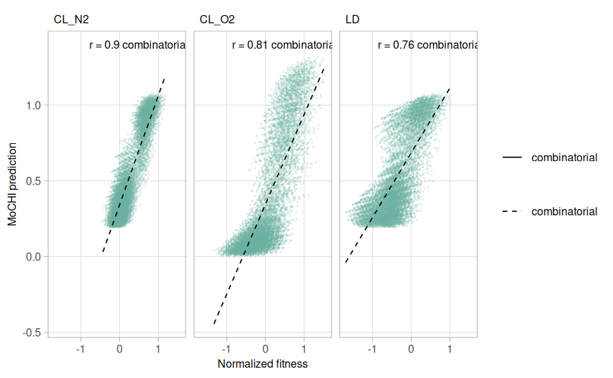

```r
ggsave("../EDA_output/png/scatter_MoCHI_additive_score.png", scat, width=6.8, height=2, units="in")
```

```r
for(cat in c("combinatorial")){
  for(cond in c("CL_N2", "CL_O2", "LD")){
    print(cond)
    print(cat)
    subset_forLoop <- subset(red_fitness_noSat, red_fitness_noSat$category==cat & red_fitness_noSat$condition==cond)
    print(nrow(subset_forLoop))
    correlation <- cor.test(subset_forLoop$additive_score, subset_forLoop$MoCHI_mean, method = 'pearson')
    print(correlation)
  }
}
```

```
[1] "CL_N2"
[1] "combinatorial"
[1] 12708

    Pearson's product-moment correlation

data:  subset_forLoop$additive_score and subset_forLoop$MoCHI_mean
t = 210.71, df = 10632, p-value < 2.2e-16
alternative hypothesis: true correlation is not equal to 0
95 percent confidence interval:
 0.8944844 0.9018308
sample estimates:
      cor
0.8982203

[1] "CL_O2"
[1] "combinatorial"
[1] 12708

    Pearson's product-moment correlation

data:  subset_forLoop$additive_score and subset_forLoop$MoCHI_mean
t = 140.55, df = 10632, p-value < 2.2e-16
alternative hypothesis: true correlation is not equal to 0
95 percent confidence interval:
 0.7995410 0.8128446
sample estimates:
      cor
0.8062947

[1] "LD"
[1] "combinatorial"
[1] 12708

    Pearson's product-moment correlation

data:  subset_forLoop$additive_score and subset_forLoop$MoCHI_mean
t = 120.26, df = 10632, p-value < 2.2e-16
alternative hypothesis: true correlation is not equal to 0
95 percent confidence interval:
 0.7509866 0.7670956
sample estimates:
      cor
0.7591573
```

## 4.6 Correlation conservation to fitness

```r
cor_subs <- unique(subset(fitness_data, fitness_data$category=="saturational" | fitness_data$category=="combiANDsatur")[,c("aa_pos","norm","conservationScore","category","condition")])
cor_subs[cor_subs$category=="combiANDsatur",]$category <- "saturational"
cor_subs <- subset(cor_subs, !is.na(cor_subs$conservationScore))
cor_subs_2 <- cor_subs %>% dplyr::group_by(aa_pos, condition) %>%
  dplyr::summarize(
    .groups="keep",
    averag_fitness=mean(norm)
  )
cor_subs <- left_join(cor_subs_2,cor_subs[,c("aa_pos","conservationScore","category")])

lm_eqn = function(df){
    m = lm(conservationScore ~ averag_fitness, df);
    cor_form = cor.test(df$averag_fitness, df$conservationScore, method = 'pearson')
    eq <- substitute("Pearson's r ="~r, #italic(y) == a + b %.% italic(x)*" r2="~r2*" p= "~p*", Pearson's r="~r
         list(a = format(coef(m)[[1]], digits = 2),
              b = format(coef(m)[[2]], digits = 2),
             r2 = format(summary(m)$r.squared, digits = 3),
             r = format(cor_form$estimate[[1]], digits=2),
             p = format(cor_form$p.value[[1]], digits=2)))
    as.character(as.expression(eq));
}
eq <- ddply(cor_subs,.(condition),lm_eqn)

scat <- ggplot(data = cor_subs, aes(x = averag_fitness, y = conservationScore, color=category, alpha=category, linetype=category)) +
            geom_point(aes(size=category, shape=category))  + scale_size_manual(values=combi_sat_size) + scale_shape_manual(values=combi_sat_shape) +
            geom_smooth(method = "lm", se=FALSE, color="black", formula = y ~ x, linewidth=line_width_for_plots) + xlab("Normalized fitness") + ylab("Conservation score") + theme_light() + theme(panel.grid.minor =element_blank(), legend.title = element_blank(), strip.background=element_rect(fill = NA, color = "white"), strip.text.x = element_text(size = 8, colour = "black", hjust = 0), axis.text=element_text(size=8), axis.title=element_text(size=8), legend.text=element_text(size=8)) + scale_alpha_manual(values=combi_sat_alpha) + scale_color_manual(values=col_combi_sat) + scale_linetype_manual(values=c("combinatorial"="dashed", "saturational"="twodash")) + facet_wrap(condition~.)
scat = scat + geom_text(data=eq,aes(x = 1, y =0.9, label=V1), size=8, size.unit="pt", parse = TRUE, inherit.aes=FALSE) + facet_wrap(condition~.)
scat

ggsave("../EDA_output/pdf/conservation_norm.pdf", scat, width=6.8, height=2, units="in")
```

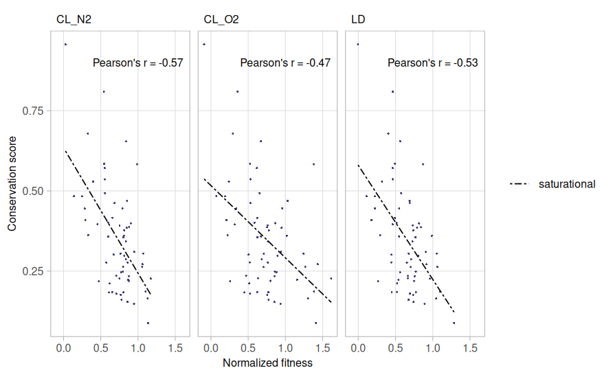

```r
ggsave("../EDA_output/png/conservation_norm.png", scat, width=6.8, height=2, units="in")
```

```r
for(cond in c("CL_N2", "CL_O2", "LD")){
    print(cond)
    subset_forLoop <- subset(cor_subs, cor_subs$category==cat & cor_subs$condition==cond)
    print(nrow(subset_forLoop))
    correlation <- cor.test(subset_forLoop$averag_fitness, subset_forLoop$conservationScore, method = 'pearson')
    print(correlation)
  }
```

```
[1] "CL_N2"
[1] 0
```

```
Error in cor.test.default(subset_forLoop$averag_fitness, subset_forLoop$conservationScore,  :
  not enough finite observations
```

## 4.7 Correlation surface exposure to fitness

```r
dotsize_surface <- 0.4
surface <- unique(subset(fitness_data, fitness_data$category=="saturational" | fitness_data$category=="combiANDsatur")[,c("aa_pos","norm","relSAS", "dimer","category","condition")])
surface[surface$category=="combiANDsatur",]$category <- "saturational"
surface <- subset(surface, !is.na(surface$relSAS))
surface_2 <- surface %>% dplyr::group_by(aa_pos, condition) %>%
  dplyr::summarize(
    .groups="keep",
    averag_fitness=mean(norm)
  )
surface <- left_join(surface_2,surface[,c("aa_pos","relSAS", "dimer","category")])

lm_eqn = function(df){
    m = lm(relSAS ~ averag_fitness, df);
    cor_form = cor.test(df$averag_fitness, df$relSAS, method = 'pearson')
    eq <- substitute("Pearson's r ="~r, #italic(y) == a + b %.% italic(x)*" r2="~r2*" p= "~p*", Pearson's r="~r
         list(a = format(coef(m)[[1]], digits = 2),
              b = format(coef(m)[[2]], digits = 2),
             r2 = format(summary(m)$r.squared, digits = 3),
             r = format(cor_form$estimate[[1]], digits=2),
             p = format(cor_form$p.value[[1]], digits=2)))
    as.character(as.expression(eq));
}
eq <- ddply(surface,.(condition),lm_eqn)

scat <- ggplot(data = surface, aes(x = averag_fitness, y = relSAS, color=dimer)) +
            geom_point(size=dotsize_surface, shape=pointshape, alpha=alphalevel) +
            geom_smooth(method = "lm", se=FALSE, color="black", formula = y ~ x, linetype="dashed", linewidth=line_width_for_plots) + xlab("Normalized fitness") + ylab("Relative solvent accessibility") + theme_light() + theme(panel.grid.minor =element_blank(), legend.title = element_blank(), strip.background=element_rect(fill = NA, color = "white"), strip.text.x = element_text(size = 8, colour = "black", hjust = 0), axis.text=element_text(size=8), axis.title=element_text(size=8), legend.text=element_text(size=8)) + scale_color_manual(values=c("#93dfffff"), na.value="#777777") + facet_wrap(condition~.)
scat = scat + geom_text(data=eq,aes(x = 1.0, y =-0.05, label=V1), size=8, size.unit="pt", parse = TRUE, inherit.aes=FALSE) + facet_wrap(condition~.)
scat
ggsave("../EDA_output/pdf/relSAS_norm.pdf", scat, width=7, height=2, units="in")
```

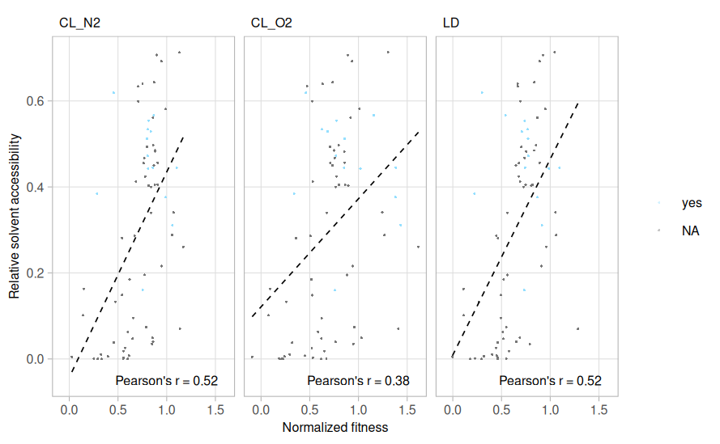

```r
ggsave("../EDA_output/png/relSAS_norm.png", scat, width=30, height=18, units="cm")
```

```r
surface_noDimer <- subset(surface, is.na(surface$dimer))
eq <- ddply(surface_noDimer,.(condition),lm_eqn)

scat <- ggplot(data = surface_noDimer, aes(x = averag_fitness, y = relSAS, color=dimer)) +
            geom_point(size=dotsize_surface, shape=pointshape, alpha=alphalevel) +
            geom_smooth(method = "lm", se=FALSE, color="black", formula = y ~ x, linetype="dashed", linewidth=line_width_for_plots) + xlab("Normalized fitness") + ylab("Relative solvent accessibility") + theme_light() + theme(panel.grid.minor =element_blank(), legend.title = element_blank(), strip.background=element_rect(fill = NA, color = "white"), strip.text.x = element_text(size = 8, colour = "black", hjust = 0), axis.text=element_text(size=8), axis.title=element_text(size=8), legend.text=element_text(size=8)) + scale_color_manual(values=c("#93dfffff"), na.value="#777777") + facet_wrap(condition~.)
scat = scat + geom_text(data=eq,aes(x = 1.0, y =-0.05, label=V1), size=8, size.unit = "pt", parse = TRUE, inherit.aes=FALSE) + facet_wrap(condition~.)
scat
ggsave("../EDA_output/pdf/relSAS_norm_noDimer.pdf", scat, width=6.8, height=2, units="in")
```

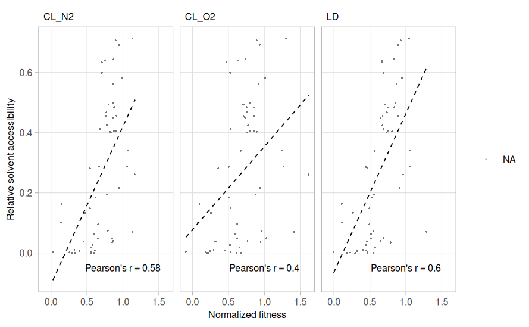

```r
ggsave("../EDA_output/png/relSAS_norm_noDimer.png", scat, width=6.8, height=2, units="in")
```

```r
surface_Dimer <- subset(surface, !is.na(surface$dimer))
eq <- ddply(surface_Dimer,.(condition),lm_eqn)

scat <- ggplot(data = surface_Dimer, aes(x = averag_fitness, y = relSAS, color=dimer)) +
            geom_point(size=dotsize_surface, shape=pointshape, alpha=alphalevel) +
            geom_smooth(method = "lm", se=FALSE, color="black", formula = y ~ x, linetype="dashed", linewidth=line_width_for_plots) + xlab("Normalized fitness") + ylab("Relative solvent accessibility") + theme_light() + theme(panel.grid.minor =element_blank(), legend.title = element_blank(), strip.background=element_rect(fill = NA, color = "white"), strip.text.x = element_text(size = 8, colour = "black", hjust = 0), axis.text=element_text(size=8), axis.title=element_text(size=8), legend.text=element_text(size=8)) + scale_color_manual(values=c("#93dfffff"), na.value="#777777") + facet_wrap(condition~.)
scat = scat + geom_text(data=eq,aes(x = 1.0, y =-0.05, label=V1), size=8, size.unit="pt", parse = TRUE, inherit.aes=FALSE) + facet_wrap(condition~.)
scat
ggsave("../EDA_output/pdf/relSAS_norm_onlyDimer.pdf", scat, width=6.8, height=2, units="in")
```

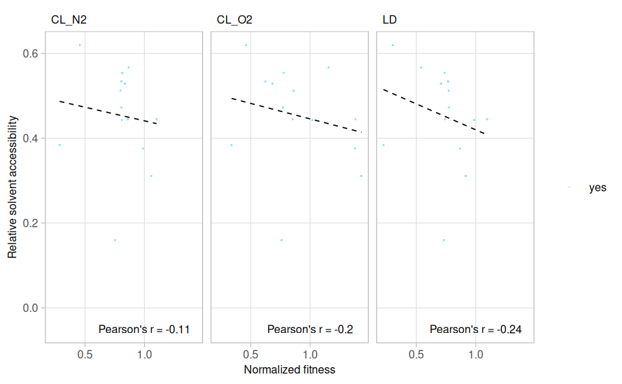

```r
ggsave("../EDA_output/png/relSAS_norm_onlyDimer.png", scat, width=30, height=18, units="cm")
```

```r
for(cond in c("CL_N2", "CL_O2", "LD")){
    print(cond)
    subset_forLoop <- subset(surface, surface$condition==cond)
    print(nrow(subset_forLoop))
    correlation <- cor.test(subset_forLoop$averag_fitness, subset_forLoop$relSAS, method = 'pearson')
    print(correlation)
}
```

```
[1] "CL_N2"
[1] 3669

    Pearson's product-moment correlation

data:  subset_forLoop$averag_fitness and subset_forLoop$relSAS
t = 37.259, df = 3667, p-value < 2.2e-16
alternative hypothesis: true correlation is not equal to 0
95 percent confidence interval:
 0.5001623 0.5471217
sample estimates:
      cor
0.5240401

[1] "CL_O2"
[1] 3669

    Pearson's product-moment correlation

data:  subset_forLoop$averag_fitness and subset_forLoop$relSAS
t = 24.848, df = 3667, p-value < 2.2e-16
alternative hypothesis: true correlation is not equal to 0
95 percent confidence interval:
 0.3515821 0.4069824
sample estimates:
      cor
0.3796226

[1] "LD"
[1] 3669

    Pearson's product-moment correlation

data:  subset_forLoop$averag_fitness and subset_forLoop$relSAS
t = 36.865, df = 3667, p-value < 2.2e-16
alternative hypothesis: true correlation is not equal to 0
95 percent confidence interval:
 0.4959798 0.5432124
sample estimates:
      cor
0.5199935
```

```r
rm(subset_forLoop)
```

# 5 Comparing different conditions

A comparison between different conditions helps to identify variants which behave different in different conditions, e.g. because of an enhanced specificity or higher compatibility with light-dark cycles.

## 5.1 Compare N2 and O2 gas feeds

```r
red_fitness <- unique(fitness_data[,c("sgRNA_target", "norm", "condition", "p_fit_adj_WT", "num_barcodes", "category")])
wide_fitness <- pivot_wider(red_fitness, values_from =c(norm,p_fit_adj_WT), names_from=condition)
wide_fitness$sgRNA_target <- factor(wide_fitness$sgRNA_target, levels=c(unique(subset(wide_fitness, wide_fitness$sgRNA_target != "WT"))$sgRNA_target, "WT"))
wide_fitness$WT_not_WT <- "notWT"
wide_fitness[wide_fitness$sgRNA_target=="WT",]$WT_not_WT <- "WT"

# set some plotting parameters
WT_shape <- c("notWT"=16, "WT"=4)
WT_alpha <- c("notWT"=0.2, "WT"=1.0)
WT_size <- c("notWT"=0.3, "WT"=0.5)
CLO2_CLN2_cutoff <- 0.25
barcode_cutoff <- 2
adjp_cutoff <- 0.05

# extract subsets from big data frames to test if significant differences
subset_signif_highO2 <- subset(fitness_data, fitness_data$sgRNA_target %in% subset(wide_fitness, wide_fitness$norm_CL_O2>1.0 & wide_fitness$p_fit_adj_WT_CL_O2<0.05)$sgRNA_target)
subset_signif_highLD <- subset(fitness_data, fitness_data$sgRNA_target %in% subset(wide_fitness, wide_fitness$norm_LD > wide_fitness$norm_CL_O2 & wide_fitness$norm_LD > 0.9)$sgRNA_target)

# prepare plotting, calculate lm to check distance from it (assuming linear regression gives better 1:1 than line through origin)
lm_CLO2_CLN2 <- lm(norm_CL_N2 ~ norm_CL_O2, wide_fitness)
summary(lm_CLO2_CLN2)

correlation <- cor.test(wide_fitness$norm_CL_O2, wide_fitness$norm_CL_N2, method = 'spearman')
correlation
correlation <- cor.test(wide_fitness$norm_CL_O2, wide_fitness$norm_CL_N2, method = 'pearson')
correlation

wide_fitness_CL_OL <- wide_fitness
wide_fitness_CL_OL$distance_lm <- wide_fitness_CL_OL$norm_CL_N2 - (lm_CLO2_CLN2$coefficients[1] + lm_CLO2_CLN2$coefficients[2] * wide_fitness_CL_OL$norm_CL_O2)
wide_fitness_CL_OL[order(wide_fitness_CL_OL$distance_lm, decreasing = FALSE),][1:10,]

# coloring according to differential expression
wide_fitness_CL_OL$diff <- "NO"
wide_fitness_CL_OL$diff[wide_fitness_CL_OL$distance_lm > 0] <- "CL_N2"
wide_fitness_CL_OL$diff[wide_fitness_CL_OL$distance_lm < 0] <- "CL_O2"
#wide_fitness_CL_OL$diff[wide_fitness_CL_OL$distance_lm > CLO2_CLN2_cutoff] <- "CL_N2" # in case we care for cut-off for minimal distance from linear regression
#wide_fitness_CL_OL$diff[wide_fitness_CL_OL$distance_lm < (-CLO2_CLN2_cutoff)] <- "CL_O2" # in case we care for cut-off for minimal distance from linear regression
wide_fitness_CL_OL[wide_fitness_CL_OL$sgRNA_target=="WT",]$diff <- "WT"
dotplot_colors <- c(col_conditions, "NO"="#d3d3d3b2", "orange", "WT"="black")

# prepare labels for plot
wide_fitness_CL_OL$delabel <- NA
wide_fitness_CL_OL$delabel[wide_fitness_CL_OL$diff !="NO"] <- as.character(wide_fitness_CL_OL$sgRNA_target[wide_fitness_CL_OL$diff != "NO"])

p <- ggplot(wide_fitness_CL_OL, aes(x=norm_CL_O2, y=norm_CL_N2, color=diff, shape=WT_not_WT)) + geom_point(aes(size=WT_not_WT, alpha=WT_not_WT), show.legend=FALSE) + scale_shape_manual(values=WT_shape) + scale_size_manual(values=WT_size) + scale_alpha_manual(values=WT_alpha) + theme_light() + labs(y="Weighted mean fitness value at continuous light, 5% CO2, 95% N2, 0% O2", x="Weighted mean fitness value at continuous light, 5% CO2, 75% N2, 20% O2") + theme(legend.position = "none", panel.grid.minor = element_blank()) + geom_abline(intercept=lm_CLO2_CLN2$coefficients[1],slope=lm_CLO2_CLN2$coefficients[2],linetype="dashed",color="black", linewidth=line_width_for_plots) + scale_colour_manual(values = dotplot_colors) + theme(panel.grid.minor = element_blank(), strip.background=element_rect(fill = NA, color = "white"), strip.text.x = element_text(size = 8, colour = "black", hjust = 0), axis.text=element_text(size=8), axis.title=element_text(size=8), legend.text=element_text(size=8)) #+ xlim(-6, +7) +ylim(-6,+7)
ggsave(filename = "../EDA_output/pdf/wfitness_CLN2_CLO2_withoutSignif_wo-labels.pdf", plot=p, width=4, height=4, units="cm")
ggsave(filename = "../EDA_output/png/wfitness_CLN2_CLO2_withoutSignif_wo-labels.png", plot=p, width=4, height=4, units="cm")
p
```

Use Wilcoxon signed rank exact test to check if barcodes for the same variant behave significiantly different between the two tested conditions.

```r
subset_signif_highO2 <- subset(subset_signif_highO2, subset_signif_highO2$condition %in% c("CL_N2", "CL_O2"))

get_controls <- function(cond_spec, sgRNA_spec){
  control_table <- subset_signif_highO2[subset_signif_highO2$condition != unique(cond_spec) & subset_signif_highO2$sgRNA_target == unique(sgRNA_spec) & subset_signif_highO2$time == 0,]
  control_table$fitness
}

subset_signif_highO2 <- dplyr::left_join(
  subset_signif_highO2,
  subset_signif_highO2 %>%
    dplyr::group_by(sgRNA_target, condition, time) %>%
    dplyr::summarize(
      .groups = "keep",
      # apply Wilcoxon rank sum test against other condition
      p_fitness_condition = stats::wilcox.test(
        x = fitness,
        y = get_controls(condition, sgRNA_target),
        paired = TRUE,
        alternative = "two.sided"
        )$p.value
      ),
  by = c("sgRNA_target", "condition", "time")
  )

subset_signif_highO2 <- subset_signif_highO2 %>%
  group_by(condition, time) %>%
  mutate(
    p_fitness_condition_adj = stats::p.adjust(p_fitness_condition, method = "BH")
    )
```

Plot part of data set which was tested for significant differences and highlight variants which were found to be significant.

```r
subset_signif_highO2_red <- unique(subset_signif_highO2[,c("sgRNA_target", "norm", "condition", "num_barcodes", "p_fitness_condition_adj")])
subset_signif_highO2_red <- pivot_wider(subset_signif_highO2_red, values_from =c(norm,p_fitness_condition_adj), names_from=condition)

# alpha, size and labels according to significance
wide_fitness_CL_OL$signif <- "NO"
wide_fitness_CL_OL$signif[wide_fitness_CL_OL$sgRNA_target %in% unique(subset(subset_signif_highO2, subset_signif_highO2$p_fitness_condition_adj < adjp_cutoff))$sgRNA_target] <- "SIG"
wide_fitness_CL_OL$delabel <- NA
wide_fitness_CL_OL$delabel[wide_fitness_CL_OL$signif =="SIG"] <- as.character(wide_fitness_CL_OL$sgRNA_target[wide_fitness_CL_OL$signif =="SIG"])
wide_fitness_CL_OL[wide_fitness_CL_OL$sgRNA_target=="WT",]$signif <- "WT" # to ensure WT is visible
signif_size <- c("NO"=0.3, "SIG"=0.5, "WT"=0.5)
signif_alpha <- c("NO"=0.2, "SIG"=0.9, "WT"=1.0)

p <- ggplot(wide_fitness_CL_OL, aes(x=norm_CL_O2, y=norm_CL_N2, color=diff, label=delabel, shape=WT_not_WT)) + scale_shape_manual(values=WT_shape) + geom_point(aes(size=signif, alpha=signif), show.legend=FALSE) + scale_size_manual(values=signif_size) + scale_alpha_manual(values=signif_alpha) + theme_light() + labs(y="Weighted mean fitness value at continuous light, 5% CO2, 95% N2, 0% O2", x="Weighted mean fitness value at continuous light, 5% CO2, 75% N2, 20% O2") + theme(legend.position = "none", panel.grid.minor = element_blank()) + geom_abline(intercept=lm_CLO2_CLN2$coefficients[1],slope=lm_CLO2_CLN2$coefficients[2],linetype="dashed",color="black", linewidth=line_width_for_plots) + scale_colour_manual(values = dotplot_colors) + geom_text_repel(fontface="italic") + xlim(0.75, 2.5) +ylim(0.75,1.75)
p
ggsave(filename = "../EDA_output/pdf/wfitness_CLN2_CLO2_Wilcox_signif.pdf", plot=p, width=12.5, height=12.5, units="cm")
ggsave(filename = "../EDA_output/png/wfitness_CLN2_CLO2_Wilcox_signif.png", plot=p, width=12.5, height=12.5, units="cm")

wide_fitness_CL_OL[wide_fitness_CL_OL$signif=="SIG",][order(wide_fitness_CL_OL[wide_fitness_CL_OL$signif=="SIG",]$norm_CL_O2, decreasing=TRUE),]
```

```r
possibly_specific_variants <- c("H358I", "K360I", "M328I", "Y333T", "H358Q", "Y322M", "D329T", "Y333V", "K99E", "M231F", "Y333I", "WT", neg_control_K214)
possibly_specific_variants <- c("H358I", "K360I", "M328I", "Y333T", "Y322M", "D329T", "K99E", "M231F", "WT", neg_control_K214)
different_colors_set <- c("H358I"="#332288ff", "K360I"="#117733ff", "M328I"="#44aa99ff", "Y333T"="#88cceeff", "Y322M"="#ddcc77ff", "D329T"="#cc6677ff", "K99E"="#aa4499ff", "M231F"="#882255ff", "WT"="black", neg_control_K214="darkgray")
possibly_specific_subset <- unique(subset(fitness_data, fitness_data$sgRNA_target %in% possibly_specific_variants))
possibly_specific_subset$sgRNA_target <- factor(possibly_specific_subset$sgRNA_target, levels=c(unique(subset(possibly_specific_subset, !possibly_specific_subset$sgRNA_target %in% c(neg_control_K214, "WT"))$sgRNA_target), neg_control_K214, "WT"))
p <- lineplot_CVinterval_severalColours_meanlog2(possibly_specific_subset) + labs(title="most different variants N2, O2 feeds") + scale_color_manual(values=different_colors_set) + scale_fill_manual(values=different_colors_set) #+ scale_linetype_manual(values=c("WT"="solid", possibly_specific_variants[9]=44, possibly_specific_variants[1]=88, possibly_specific_variants[2]=13, possibly_specific_variants[3]=1343, possibly_specific_variants[4]=131343, possibly_specific_variants[5]=73, possibly_specific_variants[6]=2262, possibly_specific_variants[7]=112233, possibly_specific_variants[8]=11223344))
p
ggsave("../EDA_output/pdf/mostDifferent_CLN2_CLO2_timeLinePlot.pdf", plot=p, width=10, height=10)
ggsave("../EDA_output/png/mostDifferent_CLN2_CLO2_variants_timeLinePlot.png", plot=p, width=10, height=10)
a <- pivot_wider(unique(subset(fitness_data, fitness_data$sgRNA_target %in% possibly_specific_variants)[,c("sgRNA_target", "condition", "norm", "p_fit_adj_WT", "num_barcodes")]), values_from=c("norm", "p_fit_adj_WT"), names_from=condition)
a$norm_multiply <- a$norm_CL_N2 * a$norm_CL_O2 * a$norm_LD
a[order(a$norm_multiply, decreasing = TRUE),]
```

## 5.2 Compare light-dark and continuous light at the same gas feed

```r
lm_CLO2_LD <- lm(norm_LD ~ norm_CL_O2, wide_fitness)
summary(lm_CLO2_LD)

correlation <- cor.test(wide_fitness$norm_CL_O2, wide_fitness$norm_LD, method = 'spearman')
correlation
correlation <- cor.test(wide_fitness$norm_CL_O2, wide_fitness$norm_LD, method = 'pearson')
correlation

CL_LD_cutoff <- 0.32
barcode_cutoff <- 2
adjp_cutoff <- 0.05

wide_fitness_LD_OL <- wide_fitness

wide_fitness_LD_OL$distance_lm <- wide_fitness_LD_OL$norm_LD - (lm_CLO2_LD$coefficients[1] + lm_CLO2_LD$coefficients[2] * wide_fitness_LD_OL$norm_CL_O2)
wide_fitness_LD_OL[order(wide_fitness_LD_OL$distance_lm, decreasing = TRUE),][1:10,]

# coloring according to differential expression
wide_fitness_LD_OL$diff <- "NO"
wide_fitness_LD_OL$diff[wide_fitness_LD_OL$distance_lm > 0] <- "LD"
wide_fitness_LD_OL$diff[wide_fitness_LD_OL$distance_lm < 0] <- "CL_O2"
#wide_fitness_LD_OL$diff[wide_fitness_LD_OL$distance_lm > CL_LD_cutoff] <- "LD" # if using cut-off
#wide_fitness_LD_OL$diff[wide_fitness_LD_OL$distance_lm < (-CL_LD_cutoff)] <- "CL_O2" # if using cut-off
wide_fitness_LD_OL[wide_fitness_LD_OL$sgRNA_target=="WT",]$diff <- "WT"

p <- ggplot(wide_fitness_LD_OL, aes(x=norm_CL_O2, y=norm_LD, color=diff, shape=WT_not_WT)) + geom_point(aes(size=WT_not_WT, alpha=WT_not_WT), show.legend=FALSE) + scale_shape_manual(values=WT_shape) + scale_size_manual(values=WT_size) + scale_alpha_manual(values=WT_alpha) + theme_light() + labs(y="Weighted mean fitness value in light-dark cycles, 5% CO2, 75% N2, 20% O2", x="Weighted mean fitness value in continuous light, 5% CO2, 75% N2, 20% O2") + theme(legend.position = "none", panel.grid.minor = element_blank()) + geom_abline(intercept=lm_CLO2_LD$coefficients[1],slope=lm_CLO2_LD$coefficients[2],linetype="dashed",color="black")+ scale_colour_manual(values = dotplot_colors) + theme(panel.grid.minor = element_blank(), strip.background=element_rect(fill = NA, color = "white"), strip.text.x = element_text(size = 8, colour = "black", hjust = 0), axis.text=element_text(size=8), axis.title=element_text(size=8), legend.text=element_text(size=8)) #+ xlim(-6, +7) +ylim(-6,+7)  + geom_abline(intercept=lm_CLO2_LD$coefficients[1]-CL_LD_cutoff, slope=lm_CLO2_LD$coefficients[2], linetype="dashed", color="black") + geom_abline(intercept=lm_CLO2_LD$coefficients[1]+CL_LD_cutoff, slope=lm_CLO2_LD$coefficients[2], linetype="dashed", color="black")
ggsave(filename = "../EDA_output/pdf/wfitness_CLO2_LD_withoutSignif_withoutLabeling.pdf", plot=p, width=4, height=4, units="cm")
ggsave(filename = "../EDA_output/png/wfitness_CLO2_LD_withoutSignif_withoutLabeling.png", plot=p, width=4, height=4, units="cm")
p
```

Run Wilcoxon test to check for significant differences between conditions.

```r
subset_signif_highLD <- subset(subset_signif_highLD, subset_signif_highLD$condition %in% c("LD", "CL_O2") & subset_signif_highLD$time==0.0)

get_controls <- function(cond_spec, sgRNA_spec){
  control_table <- subset_signif_highLD[subset_signif_highLD$condition != unique(cond_spec) & subset_signif_highLD$sgRNA_target == unique(sgRNA_spec) & subset_signif_highLD$time == 0,]
  control_table$fitness
}

subset_signif_highLD <- dplyr::left_join(
  subset_signif_highLD,
  subset_signif_highLD %>%
    dplyr::group_by(sgRNA_target, condition, time) %>%
    dplyr::summarize(
      .groups = "keep",
      # apply Wilcoxon rank sum test against other condition
      p_fitness_condition = stats::wilcox.test(
        x = fitness,
        y = get_controls(condition, sgRNA_target),
        paired = TRUE,
        alternative = "two.sided"
        )$p.value
      ),
  by = c("sgRNA_target", "condition", "time")
  )

subset_signif_highLD <- subset_signif_highLD %>%
  group_by(condition, time) %>%
  mutate(
    p_fitness_condition_adj = stats::p.adjust(p_fitness_condition, method = "BH")
    )
```

```r
subset_signif_highLD_red <- unique(subset_signif_highLD[,c("sgRNA_target", "norm", "condition", "num_barcodes", "p_fitness_condition_adj")])
subset_signif_highLD_red <- pivot_wider(subset_signif_highLD_red, values_from =c(norm,p_fitness_condition_adj), names_from=condition)

# labels, alpha and size according to significance
wide_fitness_LD_OL$signif <- "NO"
wide_fitness_LD_OL$signif[wide_fitness_LD_OL$sgRNA_target %in% unique(subset(subset_signif_highLD, subset_signif_highLD$p_fitness_condition_adj < 0.4))$sgRNA_target] <- "SIG"
wide_fitness_LD_OL$delabel <- NA
wide_fitness_LD_OL$delabel[wide_fitness_LD_OL$signif =="SIG"] <- as.character(wide_fitness_LD_OL$sgRNA_target[wide_fitness_LD_OL$signif =="SIG"])
wide_fitness_CL_OL[wide_fitness_CL_OL$sgRNA_target=="WT",]$signif <- "WT" # to ensure WT is visible

p <- ggplot(wide_fitness_LD_OL, aes(x=norm_CL_O2, y=norm_LD, color=diff, label=delabel, shape=WT_not_WT)) + scale_shape_manual(values=WT_shape) + geom_point(aes(size=signif, alpha=signif), show.legend=FALSE) + scale_size_manual(values=signif_size) + scale_alpha_manual(values=signif_alpha) + theme_light() + labs(y="Weighted mean fitness value at continuous light, 5% CO2, 95% N2, 0% O2", x="Weighted mean fitness value at continuous light, 5% CO2, 75% N2, 20% O2") + theme(legend.position = "none", panel.grid.minor = element_blank()) + geom_abline(intercept=lm_CLO2_LD$coefficients[1],slope=lm_CLO2_LD$coefficients[2],linetype="dashed",color="black") + scale_colour_manual(values = dotplot_colors) + geom_text_repel() #+ xlim(0.75, 2.5) +ylim(0.75,2.25)
p
ggsave(filename = "../EDA_output/pdf/wfitness_LD_CLO2_Wilcox_signif.pdf", plot=p, width=12.5, height=12.5, units="cm")
ggsave(filename = "../EDA_output/png/wfitness_LD_CLO2_Wilcox_signif.png", plot=p, width=12.5, height=12.5, units="cm")

wide_fitness_CL_OL[wide_fitness_LD_OL$signif=="SIG",][order(wide_fitness_LD_OL[wide_fitness_LD_OL$signif=="SIG",]$norm_LD, decreasing=TRUE),]
```

```r
## coloring according to differential expression
wide_fitness_LD_OL$diff <- "NO"
wide_fitness_LD_OL$diff[wide_fitness_LD_OL$distance_lm > CL_LD_cutoff] <- "LD" # if using cut-off
wide_fitness_LD_OL$diff[wide_fitness_LD_OL$distance_lm < (-CL_LD_cutoff)] <- "CL_O2" # if using cut-off
wide_fitness_LD_OL[wide_fitness_LD_OL$sgRNA_target=="WT",]$diff <- "WT"

# labels, alpha and size according to significant difference to WT variant
wide_fitness_LD_OL$signif <- "NO"
wide_fitness_LD_OL$signif[wide_fitness_LD_OL$p_fit_adj_WT_CL_O2 < adjp_cutoff & wide_fitness_LD_OL$p_fit_adj_WT_LD < adjp_cutoff & (wide_fitness_LD_OL$diff=="LD" | wide_fitness_LD_OL$diff=="CL_O2") & wide_fitness_LD_OL$num_barcodes >= barcode_cutoff] <- "SIG"
signif_size <- c("NO"=0.2, "SIG"=0.3)
signif_alpha <- c("NO"=0.2, "SIG"=0.8)
wide_fitness_LD_OL$delabel <- as.character(wide_fitness_LD_OL$sgRNA_target)
wide_fitness_LD_OL$delabel[wide_fitness_LD_OL$signif !="SIG"] <- NA

p <- ggplot(wide_fitness_LD_OL, aes(x=norm_CL_O2, y=norm_LD, color=diff, shape=WT_not_WT, label=delabel)) + geom_point(aes(size=signif, alpha=signif), show.legend=FALSE) + scale_shape_manual(values=WT_shape) + scale_size_manual(values=signif_size) + scale_alpha_manual(values=signif_alpha) + theme_light() + labs(y="Weighted mean fitness value in light-dark cycles, 5% CO2, 75% N2, 20% O2", x="Weighted mean fitness value in continuous light, 5% CO2, 75% N2, 20% O2") + theme(legend.position = "none", panel.grid.minor = element_blank()) + geom_abline(intercept=lm_CLO2_LD$coefficients[1],slope=lm_CLO2_LD$coefficients[2],linetype="dashed",color="black")+ scale_colour_manual(values = dotplot_colors)  + geom_abline(intercept=lm_CLO2_LD$coefficients[1]-CL_LD_cutoff, slope=lm_CLO2_LD$coefficients[2], linetype="dashed", color="black") + geom_abline(intercept=lm_CLO2_LD$coefficients[1]+CL_LD_cutoff, slope=lm_CLO2_LD$coefficients[2], linetype="dashed", color="black") + geom_text_repel() #  + xlim(-6, +7) +ylim(-6,+7)
ggsave(filename = "../EDA_output/pdf/wfitness_CLO2_LD_attempt_findDifferentVariants.pdf", plot=p, width=12.5, height=12.5, units="cm")
ggsave(filename = "../EDA_output/png/wfitness_CLO2_LD_attempt_findDifferentVariants.png", plot=p, width=12.5, height=12.5, units="cm")
p

wide_fitness_LD_OL_sig <- subset(wide_fitness_LD_OL, wide_fitness_LD_OL$signif=="SIG")
wide_fitness_LD_OL_sig[order(wide_fitness_LD_OL_sig$distance_lm, decreasing = TRUE),][1:10,]
```

```r
possibly_higher_inLD <- c("K456H", "G432S", "K99N", "H126G","WT", neg_control_K214)
different_colors_set <- c("K456H"="#332288ff", "G432S"="#117733ff", "H358M"="#44aa99ff", "H126N"="#88cceeff", "H126G"="#ddcc77ff", "K99N"="#cc6677ff", "WT"="black", neg_control_K214="darkgray")
single_subset <- subset(fitness_data, fitness_data$sgRNA_target %in% possibly_higher_inLD)
p <- lineplot_CVinterval_severalColours_meanlog2(single_subset) + labs(title="most different variants") + scale_color_manual(values=different_colors_set) + scale_fill_manual(values=different_colors_set)
p
ggsave("../EDA_output/pdf/mostDifferent_LD_CLO2_timeLinePlot.pdf", plot=p, width=10, height=10)
ggsave("../EDA_output/png/mostDifferent_LD_CLO2_variants_timeLinePlot.png", plot=p, width=10, height=10)

unique(subset(fitness_data, fitness_data$sgRNA_target %in% possibly_higher_inLD)[,c("sgRNA_target", "condition", "norm", "p_fit_adj_WT", "num_barcodes")])
```

# 6 Generally interesting mutants

In the following, an attempt is made to pinpoint some interesting variants that are worth testing. The following chunk of code selects all variants which are performing well under all conditions and are significantly different to the base variant. Furthermore, only variants with at least two barcodes are taken into account.

```r
columns <- c("sgRNA_target",  "condition", "norm", "p_fit_adj_WT", "num_barcodes", "number_muts")
fitness_data_goodVariants <- pivot_wider(unique(fitness_data[,columns]), values_from = c("norm", "p_fit_adj_WT"), names_from = condition)
fitness_data_goodVariants <- unique(subset(fitness_data_goodVariants, fitness_data_goodVariants$p_fit_adj_WT_CL_N2 < 0.05 & fitness_data_goodVariants$p_fit_adj_WT_CL_O2 < 0.05 & fitness_data_goodVariants$p_fit_adj_WT_LD < 0.05 & fitness_data_goodVariants$norm_CL_N2 > 1 & fitness_data_goodVariants$norm_CL_O2 > 1 & fitness_data_goodVariants$norm_LD > 1 & fitness_data_goodVariants$num_barcodes > 1))

length(unique(fitness_data_goodVariants$sgRNA_target))
length(unique(fitness_data_goodVariants$sgRNA_target))/length(unique(fitness_data$sgRNA_target))

fitness_data_goodVariants$combined_norms <- fitness_data_goodVariants$norm_CL_N2 * fitness_data_goodVariants$norm_CL_O2 * fitness_data_goodVariants$norm_LD
print(fitness_data_goodVariants[order(fitness_data_goodVariants$combined_norms, decreasing = TRUE),])
write_csv(fitness_data_goodVariants[order(fitness_data_goodVariants$combined_norms, decreasing = TRUE),], "../EDA_output/goodVariants.csv")
```

```r
highScoring_subset <- subset(fitness_data, fitness_data$sgRNA_target %in% c("H126N", "H126M", "W128I", "K360I", "K360M", "Q142D", "K233C", "H358C", "K360L", "H358L", "K99N", "K360C", "Y333V", "H126G", "M154E,K261A,Q406D,S446T", "Q142E", "M345Q", "F104V", "V98Q", "K261A,H265A,Q406D,S446I", "K99T", "K233L", "M345V", "WT", neg_control_K214))
p <- lineplot_CVinterval_severalColours_meanlog2(highScoring_subset) + labs(title="Fittest variants with 95% CI")
p
ggsave("../EDA_output/pdf/highest_variants_timeLinePlot.pdf", plot=p)
ggsave("../EDA_output/png/highest_variants_timeLinePlot.png", plot=p)
```

Partially, exchanges at the same amino acid position score quite similarly. We cannot distinguish their fitness on basis of our data.

```r
plot_subset <- subset(fitness_data, fitness_data$sgRNA_target %in% c("H126N", "H126M", "H126G", "WT", neg_control_K214))
p <- lineplot_CVinterval_severalColours_meanlog2(plot_subset) + labs(title="Very fit H126 variants with 95% CI")
p
ggsave("../EDA_output/pdf/H126_subset_variants_timeLinePlot.pdf", plot=p)
ggsave("../EDA_output/png/H126_subset_variants_timeLinePlot.png", plot=p)

plot_subset <- subset(fitness_data, fitness_data$sgRNA_target %in% c("K360I", "K360M", "K360L", "K360C", "WT", neg_control_K214))
p <- lineplot_CVinterval_severalColours_meanlog2(plot_subset) + labs(title="Very fit K360 variants with 95% CI")
p
ggsave("../EDA_output/pdf/K360_subset_variants_timeLinePlot.pdf", plot=p)
ggsave("../EDA_output/png/K360_subset_variants_timeLinePlot.png", plot=p)

plot_subset <- subset(fitness_data, fitness_data$sgRNA_target %in% c("H358C", "H358L", "WT", neg_control_K214))
p <- lineplot_CVinterval_severalColours_meanlog2(plot_subset) + labs(title="Very fit H358 variants with 95% CI")
p
ggsave("../EDA_output/pdf/H358_subset_variants_timeLinePlot.pdf", plot=p)
ggsave("../EDA_output/png/H358_subset_variants_timeLinePlot.png", plot=p)

plot_subset <- subset(fitness_data, fitness_data$sgRNA_target %in% c("Q142D", "Q142E", "WT", neg_control_K214))
p <- lineplot_CVinterval_severalColours_meanlog2(plot_subset) + labs(title="Very fit Q142 variants with 95% CI")
p
ggsave("../EDA_output/pdf/Q142_subset_variants_timeLinePlot.pdf", plot=p)
ggsave("../EDA_output/png/Q142_subset_variants_timeLinePlot.png", plot=p)

plot_subset <- subset(fitness_data, fitness_data$sgRNA_target %in% c("M345Q", "M345V", "WT", neg_control_K214))
p <- lineplot_CVinterval_severalColours_meanlog2(plot_subset) + labs(title="Very fit M345 variants with 95% CI")
p
ggsave("../EDA_output/pdf/M345_subset_variants_timeLinePlot.pdf", plot=p)
ggsave("../EDA_output/png/M345_subset_variants_timeLinePlot.png", plot=p)

plot_subset <- subset(fitness_data, fitness_data$sgRNA_target %in% c("K233C", "K233L", "WT", neg_control_K214))
p <- lineplot_CVinterval_severalColours_meanlog2(plot_subset) + labs(title="Very fit K233 variants with 95% CI")
p
ggsave("../EDA_output/pdf/K233_subset_variants_timeLinePlot.pdf", plot=p)
ggsave("../EDA_output/png/K233_subset_variants_timeLinePlot.png", plot=p)

plot_subset <- subset(fitness_data, fitness_data$sgRNA_target %in% c("K99N", "K99T", "WT", neg_control_K214))
p <- lineplot_CVinterval_severalColours_meanlog2(plot_subset) + labs(title="Very fit K99 variants with 95% CI")
p
ggsave("../EDA_output/pdf/K99_subset_variants_timeLinePlot.pdf", plot=p)
ggsave("../EDA_output/png/K99_subset_variants_timeLinePlot.png", plot=p)

plot_subset <- subset(fitness_data, fitness_data$sgRNA_target %in% c("W128I", "Y333V", "F104V", "V98Q", "WT", neg_control_K214))
different_colors_set <- c("W128I"="#332288ff", "Y333V"="#117733ff", "V98Q"="#88cceeff", "F104V"="#ddcc77ff", "WT"="black", neg_control_K214="darkgray") #different_colors_set <- c("W128I"="#332288ff", "Y333V"="#117733ff", "F104V"="#44aa99ff", "V98Q"="#88cceeff", "F104V"="#ddcc77ff", "K99N"="#cc6677ff", "WT"="black", neg_control_K214="darkgray")
p <- lineplot_CVinterval_severalColours_meanlog2(plot_subset) + labs(title="Very fit variants with 95% CI") + scale_fill_manual(values=different_colors_set) + scale_color_manual(values=different_colors_set)
p
ggsave("../EDA_output/pdf/remaining_highScoring_variants_timeLinePlot.pdf", plot=p)
ggsave("../EDA_output/png/remaining_highScoring_variants_timeLinePlot.png", plot=p)
```

# 7 Plot epistatic effects

## 7.1 General overview over epistasis in data set

From Miton et al., 2016 (https://onlinelibrary.wiley.com/doi/full/10.1002/pro.2876): “We calculated the fold change in enzyme fitness (F) provided by a mutation i on the wild-type background (ΔFwt,i=Fwt+i/Fwt) and the change caused by the same mutation on the intermediate variant j in the trajectory, (ΔFj,i=Fj+i/Fj) […] epistasis was determined by comparing the fold changes in the trajectory over the wild-type background (ΔFj,i/ΔFwt,i). For the sake of simplicity, we considered that ≥1.5-fold change is significant, and less than 1.5-fold change is neutral (or nearly neutral). […] Neutral designates mutations that show less than 1.5-fold change in enzyme fitness on both backgrounds (0.7 < [ΔFj,i and ΔFwt,i] < 1.5). (ii - v) Functional refers to non-neutral mutations that exhibit >1.5-fold improvement in either genetic background (ΔFj,i or ΔFwt,i > 1.5). Among functional mutations, ii) no epistasis refers to mutations that do not significantly alter the enzyme fitness depending on the background (mutations are additive, ΔFj,i/ΔFwt,i ∼ 1). (iii – iv) Positive epistasis applies to a mutation that becomes more beneficial when combined with prior substitutions on the trajectory, compared to its effect on the wild-type background (ΔFj,i/ΔFwt,i > 1.5). It can be divided in two subclasses: iii) Positive magnitude epistasis refers to cases where the effect is neutral or positive on the wild-type background and is further amplified on the trajectory (ΔFj,i ≫ ΔFwt, i > 0.7 or ΔFj, i ≫ ΔFwt, i > 1.5); and iv) Positive sign epistasis, which refers to mutations causing a deleterious effect on the wild-type background but a beneficial effect on the trajectory (ΔFwt, i <0.7 and ΔFj, i > 1.5). v) Negative epistasis applies to a mutation that becomes less beneficial on the trajectory background compared to its original effect on the wild type (ΔFj, i/ΔFwt, i <0.7).”

Identify cut-off values for good / bad variants - use adj. p values < 0.05 to do so, question “can I significantly distinguish this variant from the base variant?” Seems as if differences as small as a normed value of 1.1 are often already significant compared to the base variant - I assume a normed value of 1.25 is about right.

```r
combinatorial_wide <- subset(combinatorial_wide, combinatorial_wide$p_fit_adj_WT<0.05) # in case things were changed above
a <- unique(subset(combinatorial_wide, combinatorial_wide$norm > 1.0)$norm)
a <- a[order(a)]
a[1:20]
```

Also, differences as small as 0.9 compared to 1.0 can be distinguished - so I guess a good cut-off might be 0.8.

```r
a <- unique(subset(combinatorial_wide, combinatorial_wide$norm < 1.0)$norm)
a <- a[order(a, decreasing=TRUE)]
a[1:20]
```

```r
summarize_dataframe <- unique(dplyr::summarize(.data=epistatic_table,
      .by = c(Exchange, Condition),
    # value in WT background
    value_background = unique(.data[["Exchange_value_and_ratio_in_WT"]]),
    # number neg. effect in higher order
    number_negative_exchanges = sum(.data[["Variant_ratio"]] < 0.8), # adjusted to 0.8 according to observations detailed above from originally 0.7 in paper
    # number neutral effect in higher order
    number_neutral_exchanges = sum(.data[["Variant_ratio"]] > 0.8 & .data[["Variant_ratio"]] < 1.25), # adjusted to 0.8 and 1.2 from 0.7 and 1.5
    # number pos. effect in higher order
    number_positive_exchanges = sum(.data[["Variant_ratio"]] > 1.25), # adjusted from 1.5 in paper to 1.2 according to observations detailed above
    # no epistasis (0.7 < value < 1.5)
    number_no_epistasis = sum(.data[["ratio_WT_higherOrder"]] > 0.7 & .data[["ratio_WT_higherOrder"]] < 1.5),
    # positive epistasis (>1.5)
    number_positive_epistasis = sum(.data[["ratio_WT_higherOrder"]] > 1.5),
    # negative epistasis (<0.7)
    number_negative_epistasis = sum(.data[["ratio_WT_higherOrder"]] < 0.7),
    # total higher exchange
    number_higher_exchanges = n()
    ))
```

```r
exchanges_dataset <- summarize_dataframe[,c("Exchange", "Condition", "number_negative_exchanges", "number_neutral_exchanges", "number_positive_exchanges")]
exchanges_dataset <- pivot_longer(exchanges_dataset, !c(Exchange, Condition), values_to="number", names_to="exchanges")

exchanges_dataset$Exchange <- factor(exchanges_dataset$Exchange, levels=rev(c("H141L", "H141V", "M154D", "M154E", "M154K", "M154S", "K261A", "K261D", "K261E", "K261F", "H265A", "H265E", "H265K", "H265R", "V337A", "V337S", "Q406D", "Q406E", "S446A", "S446I", "S446T")))

colors_exchanges <- brewer.pal(n = 9, name = "Blues")[c(3,6,9)]
names(colors_exchanges) <- c("number_positive_exchanges", "number_neutral_exchanges", "number_negative_exchanges")

p <- ggplot(exchanges_dataset) +
  geom_bar(aes(x = number, y = Exchange, fill = exchanges),
           position = "fill",
           stat = "identity")  +
  scale_fill_manual(values=colors_exchanges) +
  facet_grid(~ Condition, switch = "x") +
  theme_light() +
  theme(strip.placement = "outside",
        strip.background = element_rect(fill = NA, color = "white"),
        panel.grid.minor = element_blank(),
        axis.text=element_text(size=8),
        axis.title=element_text(size=8),
        legend.text=element_text(size=8),
        strip.text.x = element_text(size = 8, colour = "black"))
p
ggsave("../EDA_output/epistasis/Positive_negativeExchanges_higherOrdervariants.pdf", plot=p, width=7.5, height=3)
ggsave("../EDA_output/epistasis/Positive_negativeExchanges_higherOrdervariants.png", plot=p, width=7.5, height=3)
```

```r
epistasis_dataset <- summarize_dataframe[,c("Exchange", "Condition", "number_no_epistasis", "number_positive_epistasis", "number_negative_epistasis")]
epistasis_dataset <- pivot_longer(epistasis_dataset, !c(Exchange, Condition), values_to="number", names_to="epistasis")

epistasis_dataset$Exchange <- factor(epistasis_dataset$Exchange, levels=rev(c("H141L", "H141V", "M154D", "M154E", "M154K", "M154S", "K261A", "K261D", "K261E", "K261F", "H265A", "H265E", "H265K", "H265R", "V337A", "V337S", "Q406D", "Q406E", "S446A", "S446I", "S446T")))

colors_epistasis <- brewer.pal(n = 9, name = "Blues")[c(3,6,9)]
names(colors_epistasis) <- c("number_positive_epistasis", "number_no_epistasis", "number_negative_epistasis")

p <- ggplot(epistasis_dataset) +
  geom_bar(aes(x = number, y = Exchange, fill = epistasis),
           position = "fill",
           stat = "identity") +
  scale_fill_manual(values=colors_epistasis) +
  facet_grid(~ Condition, switch = "x") +
  theme_light() +
  theme(strip.placement = "outside",
        strip.background = element_rect(fill = NA, color = "white"),
        panel.grid.minor = element_blank(),
        axis.text=element_text(size=8),
        axis.title=element_text(size=8),
        legend.text=element_text(size=8),
        strip.text.x = element_text(size = 8, colour = "black"))
p
ggsave("../EDA_output/epistasis/Positive_negativeEpistasis_higherOrdervariants.pdf", plot=p, width=7.5, height=3)
ggsave("../EDA_output/epistasis/Positive_negativeEpistasis_higherOrdervariants.png", plot=p, width=7.5, height=3)
```

## 7.2 Examples of epistasis

```r
epistatic_table_wide <- pivot_wider(epistatic_table[,c("Condition", "Exchange_value_and_ratio_in_WT", "Exchange", "Variant", "Variant_value", "ratio_WT_higherOrder")], names_from=c("Condition"), values_from=c("Variant_value", "ratio_WT_higherOrder", "Exchange_value_and_ratio_in_WT"))
epistatic_table_wide <- subset(epistatic_table_wide, epistatic_table_wide$ratio_WT_higherOrder_CL_N2>1.5 & epistatic_table_wide$ratio_WT_higherOrder_CL_O2 > 1.5 & epistatic_table_wide$ratio_WT_higherOrder_LD > 1.5 & epistatic_table_wide$Variant_value_CL_N2 > 1.0 & epistatic_table_wide$Variant_value_CL_O2 > 1.0 & epistatic_table_wide$Variant_value_LD > 1.0)
nrow(epistatic_table_wide)
epistatic_table_wide$ep_product <- epistatic_table_wide$ratio_WT_higherOrder_CL_N2 * epistatic_table_wide$ratio_WT_higherOrder_CL_O2 * epistatic_table_wide$ratio_WT_higherOrder_LD
epistatic_table_wide[order(epistatic_table_wide$ep_product, decreasing=TRUE),]
```

Check again if any of the “good, recovered” strains are just an artefact !

```r
plot_subset <- subset(fitness_data, fitness_data$sgRNA_target %in% c("M154K", "M154K,H265E,Q406E,S446T", "H265E,Q406E,S446T", "WT", neg_control_K214))
unique(plot_subset[,c("sgRNA_target", "norm", "condition", "num_barcodes")])
different_colors_set <- c("M154K"="#88cceeff", "M154K,H265E,Q406E,S446T"="#117733ff", "H265E,Q406E,S446T"="#ddcc77ff", "WT"="black", neg_control_K214="darkgray")
p <- lineplot_CVinterval_severalColours_meanlog2(plot_subset) + labs(title="Epistatic effects involving M154K") + scale_fill_manual(values=different_colors_set) + scale_color_manual(values=different_colors_set)
p

plot_subset <- subset(fitness_data, fitness_data$sgRNA_target %in% c("K261D", "K261D,H265E,Q406E,S446T", "H265E,Q406E,S446T", "WT", neg_control_K214))
unique(plot_subset[,c("sgRNA_target", "norm", "condition", "num_barcodes")])
different_colors_set <- c("K261D"="#88cceeff", "K261D,H265E,Q406E,S446T"="#117733ff", "H265E,Q406E,S446T"="#ddcc77ff", "WT"="black", neg_control_K214="darkgray")
p <- lineplot_CVinterval_severalColours_meanlog2(plot_subset) + labs(title="Epistatic effects involving K261D") + scale_fill_manual(values=different_colors_set) + scale_color_manual(values=different_colors_set)
p

plot_subset <- subset(fitness_data, fitness_data$sgRNA_target %in% c("V337A", "H141V,M154A,K261F,H265A,V337A,Q406E,S446I", "H141V,M154A,K261F,H265A,Q406E,S446I", "WT", neg_control_K214))
unique(plot_subset[,c("sgRNA_target", "norm", "condition", "num_barcodes")])
different_colors_set <- c("V337A"="#88cceeff", "H141V,M154A,K261F,H265A,V337A,Q406E,S446I"="#117733ff", "H141V,M154A,K261F,H265A,Q406E,S446I"="#ddcc77ff", "WT"="black", neg_control_K214="darkgray")
p <- lineplot_CVinterval_severalColours_meanlog2(plot_subset) + labs(title="Epistatic effects involving V337A") + scale_fill_manual(values=different_colors_set) + scale_color_manual(values=different_colors_set)
p
ggsave("../EDA_output/pdf/epistatic-effects-V337A.pdf", plot=p, width=20, height=20)

plot_subset <- subset(fitness_data, fitness_data$sgRNA_target %in% c("Q406E", "H141V,M154A,K261F,H265A,V337A,Q406E,S446I", "H141V,M154A,K261F,H265A,V337A,S446I", "WT", neg_control_K214))
unique(plot_subset[,c("sgRNA_target", "norm", "condition", "num_barcodes")])
different_colors_set <- c("Q406E"="#88cceeff", "H141V,M154A,K261F,H265A,V337A,Q406E,S446I"="#117733ff", "H141V,M154A,K261F,H265A,V337A,S446I"="#ddcc77ff", "WT"="black", neg_control_K214="darkgray")
p <- lineplot_CVinterval_severalColours_meanlog2(plot_subset) + labs(title="Epistatic effects involving Q406E") + scale_fill_manual(values=different_colors_set) + scale_color_manual(values=different_colors_set)
p
ggsave("../EDA_output/pdf/epistatic-effects-Q406E.pdf", plot=p, width=20, height=20)

plot_subset <- subset(fitness_data, fitness_data$sgRNA_target %in% c("Q406E", "H141V,M154A,Q406E", "H141V,M154A", "WT", neg_control_K214))
unique(plot_subset[,c("sgRNA_target", "norm", "condition", "num_barcodes")])
different_colors_set <- c("Q406E"="#88cceeff", "H141V,M154A,Q406E"="#117733ff", "H141V,M154A"="#ddcc77ff", "WT"="black", neg_control_K214="darkgray")
p <- lineplot_CVinterval_severalColours_meanlog2(plot_subset) + labs(title="Epistatic effects involving Q406E") + scale_fill_manual(values=different_colors_set) + scale_color_manual(values=different_colors_set)
p

plot_subset <- subset(fitness_data, fitness_data$sgRNA_target %in% c("K261A", "K261A,H265K,Q406E,S446A", "H265K,Q406E,S446A", "WT", neg_control_K214))
unique(plot_subset[,c("sgRNA_target", "norm", "condition", "num_barcodes")])
different_colors_set <- c("K261A"="#88cceeff", "K261A,H265K,Q406E,S446A"="#117733ff", "H265K,Q406E,S446A"="#ddcc77ff", "WT"="black", neg_control_K214="darkgray")
p <- lineplot_CVinterval_severalColours_meanlog2(plot_subset) + labs(title="Epistatic effects") + scale_fill_manual(values=different_colors_set) + scale_color_manual(values=different_colors_set)
p

plot_subset <- subset(fitness_data, fitness_data$sgRNA_target %in% c("H265A", "M154A,K261A,H265A,Q406D", "M154A,K261A,Q406D", "WT", neg_control_K214))
unique(plot_subset[,c("sgRNA_target", "norm", "condition", "num_barcodes")])
different_colors_set <- c("H265A"="#88cceeff", "M154A,K261A,H265A,Q406D"="#117733ff", "M154A,K261A,Q406D"="#ddcc77ff", "WT"="black", neg_control_K214="darkgray")
p <- lineplot_CVinterval_severalColours_meanlog2(plot_subset) + labs(title="Epistatic effects involving H265A") + scale_fill_manual(values=different_colors_set) + scale_color_manual(values=different_colors_set)
p

plot_subset <- subset(fitness_data, fitness_data$sgRNA_target %in% c("S446T", "M154A,K261A,Q406D,S446T", "M154A,K261A,Q406D", "WT", neg_control_K214))
unique(plot_subset[,c("sgRNA_target", "norm", "condition", "num_barcodes")])
different_colors_set <- c("S446T"="#88cceeff", "M154A,K261A,Q406D,S446T"="#117733ff", "M154A,K261A,Q406D"="#ddcc77ff", "WT"="black", neg_control_K214="darkgray")
p <- lineplot_CVinterval_severalColours_meanlog2(plot_subset) + labs(title="Epistatic effects involving S446T") + scale_fill_manual(values=different_colors_set) + scale_color_manual(values=different_colors_set)
p

plot_subset <- subset(fitness_data, fitness_data$sgRNA_target %in% c("K261F", "K261F,H265K,Q406D,S446I", "H265K,Q406D,S446I", "WT", neg_control_K214))
unique(plot_subset[,c("sgRNA_target", "norm", "condition", "num_barcodes")])
different_colors_set <- c("K261F"="#88cceeff", "K261F,H265K,Q406D,S446I"="#117733ff", "H265K,Q406D,S446I"="#ddcc77ff", "WT"="black", neg_control_K214="darkgray")
p <- lineplot_CVinterval_severalColours_meanlog2(plot_subset) + labs(title="Epistatic effects involving K261F") + scale_fill_manual(values=different_colors_set) + scale_color_manual(values=different_colors_set)
p

plot_subset <- subset(fitness_data, fitness_data$sgRNA_target %in% c("H265E", "K261D,H265E,Q406E,S446T", "K261D,Q406E,S446T", "WT", neg_control_K214))
unique(plot_subset[,c("sgRNA_target", "norm", "condition", "num_barcodes")])
different_colors_set <- c("H265E"="#88cceeff", "K261D,H265E,Q406E,S446T"="#117733ff", "K261D,Q406E,S446T"="#ddcc77ff", "WT"="black", neg_control_K214="darkgray")
p <- lineplot_CVinterval_severalColours_meanlog2(plot_subset) + labs(title="Epistatic effects involving H265E") + scale_fill_manual(values=different_colors_set) + scale_color_manual(values=different_colors_set)
p

plot_subset <- subset(fitness_data, fitness_data$sgRNA_target %in% c("K261A", "K261A,H265K,Q406E,S446A", "H265K,Q406E,S446A", "WT", neg_control_K214))
unique(plot_subset[,c("sgRNA_target", "norm", "condition", "num_barcodes")])
different_colors_set <- c("K261A"="#88cceeff", "K261A,H265K,Q406E,S446A"="#117733ff", "H265K,Q406E,S446A"="#ddcc77ff", "WT"="black", neg_control_K214="darkgray")
p <- lineplot_CVinterval_severalColours_meanlog2(plot_subset) + labs(title="Epistatic effects involving K261A") + scale_fill_manual(values=different_colors_set) + scale_color_manual(values=different_colors_set)
p
```

# 8 Variants for which mutant strains exist

“variant H141V,K261A,H265K,Q406E,S446I with the highest fitness value in the library, but shitty adjusted p value, is H141V,K261A,H265K,Q406E,S446I (norm=2.18, p.adj=0.107), alternative option for showing epistasis (besides D and E), needs control strains H141V, K261A, Q406E, S446I and H265K to show that H265K is detrimental when introduced on its own, beneficial in background of quardruple mutant”

```r
plot_subset <- subset(fitness_data, fitness_data$sgRNA_target %in% c("H141V,K261A,H265K,Q406E,S446I", "H141V,K261A,Q406E,S446I", "H265K", "WT", neg_control_K214))
unique(plot_subset[,c("sgRNA_target", "norm", "condition", "num_barcodes")])
p <- lineplot_CVinterval_severalColours_meanlog2(plot_subset) + labs(title="Epistatic effects and 'strain A'")
p
```

H141V, M154A, K261A, H265A, Q406E, S446T other alternative option for showing epistasis (besides E), there should also be a corresponding mutant with 5 exchanges (H141V, M154A, K261A, Q406E, S446T) and then the comparison that H265A is detrimental on its own, but beneficial in the background of the mutant with 5 exchagnes

```r
plot_subset <- subset(fitness_data, fitness_data$sgRNA_target %in% c("H141V,M154A,K261A,H265A,Q406E,S446T", "H141V,M154A,K261A,Q406E,S446T", "H265A", "WT", neg_control_K214))
unique(plot_subset[,c("sgRNA_target", "norm", "condition", "num_barcodes")])
p <- lineplot_CVinterval_severalColours_meanlog2(plot_subset) + labs(title="Epistatic effects and 'strain D'")
p
```

H141V, K261E, H265A, S446A “fittest combinatorial mutant variant with a significant difference has four amino acid exchanges: H141V,K261E,H265A,S446A (norm=1.56, p.adj=0.0259) , main line Figure showing epistasis, there should also be a corresponding triple mutant (H141V, K261E, S446A) showing that H265A on its own is detrimental, in background of H141V, K261E, S446A beneficial”

```r
plot_subset <- subset(fitness_data, fitness_data$sgRNA_target %in% c("H141V,K261E,H265A,S446A", "H141V,K261E,S446A", "H265A", "WT", neg_control_K214))
unique(plot_subset[,c("sgRNA_target", "norm", "condition", "num_barcodes")])
p <- lineplot_CVinterval_severalColours_meanlog2(plot_subset) + labs(title="Epistatic effects and 'strain E'")
p
```

Variant underlying the suggested higher-order variants: H141V, K261A, H265A, Q406E, S446T

```r
different_colors_set <- c("W128I"="#88cceeff", "H141V,K261A,H265A,Q406E,S446T"="#117733ff", "K360I"="#ddcc77ff", "WT"="black", neg_control_K214="darkgray")
plot_subset <- subset(fitness_data, fitness_data$sgRNA_target %in% c("H141V,K261A,H265A,Q406E,S446T", "W128I", "K360I", "WT", neg_control_K214))
unique(plot_subset[,c("sgRNA_target", "norm", "condition", "num_barcodes")])
p <- lineplot_CVinterval_severalColours_meanlog2(plot_subset) + labs(title="Variant underlying B, C, Bfix and single exchanges introduced in these variants") + scale_fill_manual(values=different_colors_set) + scale_color_manual(values=different_colors_set)
p
ggsave("../EDA_output/pdf/variant_underlying_B-C-Bfix.pdf", plot=p, width=20, height=20)
```

W128I single exchange with high fitness value, H358S single exchange with high fitness value, K360I single exchange with high fitness value

```r
plot_subset <- subset(fitness_data, fitness_data$sgRNA_target %in% c("W128I", "H358S", "K360I", "WT", neg_control_K214))
unique(plot_subset[,c("sgRNA_target", "norm", "condition", "num_barcodes")])
p <- lineplot_CVinterval_severalColours_meanlog2(plot_subset) + labs(title="Single exchanges added cloned as single mutant strains")
p
```

Higher order variant with V98D, F104C, W128K, Q142D, K233I, V270L, M345I, H358S

```r
plot_subset <- subset(fitness_data, fitness_data$sgRNA_target %in% c("V98D", "F104C", "W128K", "Q142D", "K233I", "V270L", "M345I", "H358S", "WT", neg_control_K214))
unique(plot_subset[,c("sgRNA_target", "norm", "condition", "num_barcodes")])
p <- lineplot_CVinterval_severalColours_meanlog2(plot_subset) + labs(title="Single exchanges underlying higher order variant ('M8')")
p
```

# 9 Other analyses for combinatorial library

```r
single_muts_combinatorial <- pivot_wider(unique(subset(fitness_data, fitness_data$category=="combiANDsatur")[,columns]), names_from=condition, values_from=c(norm, p_fit_adj_WT))
single_muts_combinatorial$norm_multiply <- single_muts_combinatorial$norm_CL_N2 * single_muts_combinatorial$norm_CL_O2 * single_muts_combinatorial$norm_LD
write.csv(single_muts_combinatorial, file="../EDA_output/single_site_exchanges_combinatorialLibrary.csv")
single_muts_combinatorial[order(single_muts_combinatorial$norm_multiply, decreasing=TRUE),c(1,4,5,6,10,2,3,7,8,9)]
```

```r
combi_single_subset <- subset(fitness_data, fitness_data$sgRNA_target %in% c("WT", "H265K", "H265R", "V337A", "V337S", neg_control_K214))
p <- lineplot_CVinterval_severalColours_meanlog2(combi_single_subset) + labs(title="Most detrimental single variants in combinatorial library")
p
```

```r
for(n_mut in 2:7){
  print(n_mut)
  muts_combinatorial <- pivot_wider(unique(subset(fitness_data, fitness_data$number_muts==n_mut)[,columns]), names_from=condition, values_from=c(norm, p_fit_adj_WT))
  muts_combinatorial$norm_multiply <- muts_combinatorial$norm_CL_N2 * muts_combinatorial$norm_CL_O2 * muts_combinatorial$norm_LD
  print("Sorted according to product of different normed fitness values")
  print(head(muts_combinatorial[order(muts_combinatorial$norm_multiply, decreasing=TRUE),c(1,4,5,6,10,2,3,7,8,9)]))
  muts_combinatorial <- subset(muts_combinatorial, muts_combinatorial$norm_CL_N2 > 1.0 & muts_combinatorial$norm_CL_O2 > 1.0 & muts_combinatorial$norm_LD > 1.0)
  muts_combinatorial <- subset(muts_combinatorial, (muts_combinatorial$p_fit_adj_WT_CL_N2 < 0.05 | muts_combinatorial$p_fit_adj_WT_CL_O2 < 0.05 | muts_combinatorial$p_fit_adj_WT_LD < 0.05) & muts_combinatorial$norm_CL_N2 > 1.0 & muts_combinatorial$norm_CL_O2 > 1.0 & muts_combinatorial$norm_LD > 1.0)
  print("Only selecting for variants with a normed fitness value above 1 in all conditions and a significant difference to the base variant in at least one of the conditions")
  print(head(muts_combinatorial[order(muts_combinatorial$norm_multiply, decreasing=TRUE),c(1,4,5,6,10,2,3,7,8,9)]))
}
```

# 10 Truncated variants

```r
truncated_variants <- subset(fitness_data, fitness_data$category =="notExpected")
length(unique(truncated_variants$sgRNA_target))
truncated_wide <- pivot_wider(unique(truncated_variants[,c("sgRNA_target", "norm", "condition", "p_fit_adj_WT", "num_barcodes")]), values_from =c(norm,p_fit_adj_WT), names_from=condition)
truncated_wide$norm_product <- truncated_wide$norm_CL_N2 * truncated_wide$norm_CL_O2 * truncated_wide$norm_LD
truncated_wide[order(truncated_wide$norm_product, decreasing=TRUE),]
truncated_subset <- combi_single_subset <- subset(fitness_data, fitness_data$sgRNA_target %in% c("G395V,STOP395", "F405S,Q406R,N407T,STOP407", "WT", neg_control_K214))
truncated_subset$sgRNA_target <- factor(truncated_subset$sgRNA_target, levels=c("G395V,STOP395", "F405S,Q406R,N407T,STOP407", "WT", neg_control_K214))
different_colors_set <- c("G395V,STOP395"="#44aa99ff", "F405S,Q406R,N407T,STOP407"="#aa4499ff", "WT"="black", "K214R"="darkgray")
different_linetypes_set <- c("G395V,STOP395"=44, "F405S,Q406R,N407T,STOP407"=1343, "WT"="solid", "K214R"="longdash")
p <- lineplot_CVinterval_severalColours_meanlog2(truncated_subset) + scale_linetype_manual(values=different_linetypes_set) + scale_color_manual(values=different_colors_set) + scale_fill_manual(values=different_colors_set)
ggsave("../EDA_output/pdf/truncated_variants_performing_well.pdf", plot=p, height=1.75, width=6, units="in")
p
```

# 11 Print tables with mutational effect of single amino acid exchanges

```r
single_muts <- unique(subset(fitness_data, fitness_data$number_muts==1 & fitness_data$condition=="CL_N2")[,c("sgRNA_target", "norm", "sd_fitness", "p_fit_adj_WT", "num_barcodes")])
write_csv(single_muts, "../EDA_output/heatMap/single_muts_CLN2.csv")

single_muts <- unique(subset(fitness_data, fitness_data$number_muts==1 & fitness_data$condition=="CL_O2")[,c("sgRNA_target", "norm", "sd_fitness", "p_fit_adj_WT", "num_barcodes")])
write_csv(single_muts, "../EDA_output/heatMap/single_muts_CLO2.csv")

single_muts <- unique(subset(fitness_data, fitness_data$number_muts==1 & fitness_data$condition=="LD")[,c("sgRNA_target", "norm", "sd_fitness", "p_fit_adj_WT", "num_barcodes")])
write_csv(single_muts, "../EDA_output/heatMap/single_muts_LD.csv")
```

# 12 Create files for ProteinNPT

Compare https://github.com/OATML-Markslab/ProteinNPT. Expects a .csv file. “At a minimum this file requires 2 fields: mutated_sequence (full sequence of amino acids) and DMS_score (assay measurement). If no fold variable is included in the assay file, the pipeline script will automatically create a fold_random_5 variable, assigning each mutant to folds 0-4 at random. You may also use your own cross-validation scheme (eg., assign all training sequences to fold 0, all test sequences to fold 1). To that end, you only need to pass to the pipeline script the name of that fold variable via the fold_variable_name argument and specify the index of the test fold via the test_fold_index argument (if test_fold_index is not passed as argument, the script will automatically perform a full cross-validation, rotating the test fold index at each iteration).”

Create a file for a) predicting higher-order combinations - separate amino acid positions into 5 folds –> add folds using python - three files for each condition

Use python script single_muts_train_for_combi.py to assign folds for training etc., output saturational_proteinNPT_with_foldChange.csv

Regarding folds: “We develop 3 distinct cross-validation schemes to assess the ability of each model to extrapolate to positions not encountered during training. In the Random scheme, commonly-used in other supervised fitness prediction benchmarks [Rao et al., 2019, Dallago et al., 2022], each mutation is randomly allocated to one of five distinct folds. In the Contiguous scheme, the sequence is split into five contiguous segments along its length, with mutations assigned to each segment based on the position they occur in the sequence. Lastly, the Modulo scheme uses the modulo operator to assign mutated positions to each fold. For example, position 1 is assigned to fold 1, position 2 to fold 2, and so on, looping back to fold 1 at position 6. This pattern continues throughout the sequence. We note that there is no inherent issue with using a Random cross-validation scheme to estimate the performance of predictive models. However, the conclusions drawn and the generalizability claims based on it require careful consideration.” –> use modulo scheme for assigning folds to saturational library

2. predicting more combinations
- how to assign folds? take modulo folds from saturational, combine combinatorial part and saturational part in the end

```r
saturational_for_proteinNPT <- unique(subset(fitness_data, fitness_data$number_muts==1)[,c("sgRNA_target", "norm", "baseAA", "condition")])
saturational_for_proteinNPT <- pivot_wider(saturational_for_proteinNPT, names_from=condition, values_from=norm)
write_csv(saturational_for_proteinNPT, "../EDA_output/csv_for_proteinNPT/saturational_for_proteinNPT.csv")

all_for_proteinNPT <- unique(subset(fitness_data, fitness_data$number_muts>1)[,c("sgRNA_target", "norm", "condition")])
all_for_proteinNPT <- pivot_wider(all_for_proteinNPT, names_from=condition, values_from=norm)
write_tsv(all_for_proteinNPT, "../EDA_output/csv_for_proteinNPT/combinatorial_for_proteinNPT.tsv")
```

# 13 Create file for Supplement

```r
columns_for_table <- c("sgRNA_target", "num_barcodes", "number_muts", "norm", "condition", "p_fit_adj_WT", "EVcoup_predict", "DeepSeq_predict", "MSA_Transform", "proteinNPT_predict", "additive_score", "conservationScore", "absSAS", "relSAS", "dimer")

long_format <- unique(fitness_data[,columns_for_table])
write_csv(long_format, "../EDA_output/SuppTable_all_fitness_values_long.csv")

wide_format <- pivot_wider(long_format, names_from=condition, values_from=c(norm, p_fit_adj_WT))
write_csv(wide_format, "../EDA_output/SuppTable_all_fitness_values_wide.csv")
```

## 13.1 Misc

K85N, F90A, and Y319T and combinatorial library; C4 (H127V, K247E, H251A, S432A), C5 (H127V, K247A, H251K, Q392E, S432I) and C6 (H127V, M140A, K247A, H251A, Q392E, S432T)

```r
list_of_tested_variants <- c("K99N","F104A","Y333T","H141V,K261E,H265A,S446A","H141V,K261A,H265K,Q406E,S446I","H141V,M154A,K261A,H265A,Q406E,S446T")
subset_tested <- unique(subset(fitness_data, fitness_data$sgRNA_target %in% list_of_tested_variants)[,c("sgRNA_target","sgRNA","baseMean","num_barcodes")])
subset_tested <- subset(subset_tested, !is.na(subset_tested$baseMean))
write_csv(subset_tested, "../EDA_output/baseMean_testedVariants.csv")
```